# Retribution Study — Main Analysis

```r
# The continuous version, and the one to read as primary for this measure. It
# never has to decide which side the people tied at exactly 1.00 belong on,
# which is what makes the median split awkward (see Phase 5.4's split rule),
# and it uses everyone's whole ratio rather than a high-or-low label.
cont_ratio <- run_continuous_set(d, "sentence_ratio", drop_sentence_based = TRUE)
TABLES[["contrasts_continuous_ratio"]] <- cont_ratio
show_table(cont_ratio,
           "The same set with the sentencing ratio entered continuously")
```

The same set with the sentencing ratio entered continuously

| hypothesis | outcome | predictor | n | beta | ci_lower | ci_upper | t | p_dir | p_two | r2 | alternative |
| --- | --- | --- | --- | --- | --- | --- | --- | --- | --- | --- | --- |
| H13 | Hostile-aggression cluster (z) | sentence_ratio | 947 | 0.252 | 0.190 | 0.314 | 8.008 | 0.000 | 0.000 | 0.064 | greater |
| H13 | Hatred | sentence_ratio | 947 | 0.221 | 0.159 | 0.284 | 6.977 | 0.000 | 0.000 | 0.049 | greater |
| H13 | Revenge | sentence_ratio | 947 | 0.227 | 0.165 | 0.289 | 7.174 | 0.000 | 0.000 | 0.052 | greater |
| H13 | Degradation | sentence_ratio | 947 | 0.153 | 0.090 | 0.216 | 4.751 | 0.000 | 0.000 | 0.023 | greater |
| H13 | Infliction of suffering | sentence_ratio | 947 | 0.211 | 0.148 | 0.273 | 6.629 | 0.000 | 0.000 | 0.044 | greater |
| H13 | Tolerance of prison violence | sentence_ratio | 947 | 0.192 | 0.130 | 0.255 | 6.021 | 0.000 | 0.000 | 0.037 | greater |
| H13 | Anger | sentence_ratio | 947 | 0.184 | 0.121 | 0.247 | 5.753 | 0.000 | 0.000 | 0.034 | greater |
| H13 | Social exclusion | sentence_ratio | 947 | 0.168 | 0.105 | 0.231 | 5.248 | 0.000 | 0.000 | 0.028 | greater |
| H13 | Harsh prison conditions | sentence_ratio | 947 | 0.242 | 0.180 | 0.304 | 7.655 | 0.000 | 0.000 | 0.058 | greater |
| H13 | Perceived crime rates | sentence_ratio | 947 | 0.150 | 0.087 | 0.213 | 4.661 | 0.000 | 0.000 | 0.022 | greater |
| H13 | Fear of crime | sentence_ratio | 947 | 0.057 | -0.006 | 0.121 | 1.770 | 0.039 | 0.077 | 0.003 | greater |
| H15 | Shark: how painful the death should be | sentence_ratio | 947 | 0.050 | -0.014 | 0.114 | 1.540 | 0.062 | 0.124 | 0.003 | greater |
| H16 | Essentialism about criminals | sentence_ratio | 947 | 0.217 | 0.155 | 0.280 | 6.840 | 0.000 | 0.000 | 0.047 | greater |
| H17 | Crime is a choice | sentence_ratio | 947 | 0.217 | 0.155 | 0.280 | 6.847 | 0.000 | 0.000 | 0.047 | greater |
| H18 | Leaning toward the prosecution | sentence_ratio | 947 | 0.185 | 0.123 | 0.248 | 5.803 | 0.000 | 0.000 | 0.034 | greater |
| H19 | Rejecting society’s responsibility | sentence_ratio | 947 | 0.199 | 0.137 | 0.262 | 6.246 | 0.000 | 0.000 | 0.040 | greater |
| H20 | Due-process permissiveness | sentence_ratio | 947 | 0.163 | 0.100 | 0.226 | 5.069 | 0.000 | 0.000 | 0.026 | greater |
| H20 | Convicting on uncertain evidence | sentence_ratio | 947 | 0.130 | 0.066 | 0.193 | 4.018 | 0.000 | 0.000 | 0.017 | greater |
| H21 | Punitiveness (self-report, 8 items) | sentence_ratio | 947 | 0.307 | 0.246 | 0.367 | 9.903 | 0.000 | 0.000 | 0.094 | greater |
| E1 | Right-Wing Authoritarianism | sentence_ratio | 947 | 0.153 | 0.090 | 0.216 | 4.746 | 0.000 | 0.000 | 0.023 | greater |
| E1 | Social Dominance Orientation | sentence_ratio | 947 | 0.149 | 0.086 | 0.212 | 4.632 | 0.000 | 0.000 | 0.022 | greater |
| E1 | Violence proneness | sentence_ratio | 947 | 0.177 | 0.114 | 0.240 | 5.538 | 0.000 | 0.000 | 0.031 | greater |
| E1 | Racial resentment | sentence_ratio | 947 | 0.212 | 0.150 | 0.274 | 6.671 | 0.000 | 0.000 | 0.045 | greater |
| E1 | Cognitive reflection (0-3) | sentence_ratio | 944 | -0.043 | -0.107 | 0.020 | -1.336 | 0.091 | 0.182 | 0.002 | less |
| E1 | Cognitive reflection (0-2, lily pad dropped) | sentence_ratio | 944 | -0.060 | -0.123 | 0.004 | -1.833 | 0.034 | 0.067 | 0.004 | less |

```r
# The robustness twin named in prereg 5.11: the second sentence residualized on
# the first, built in Phase 5.4. A residual is what is left of the second
# sentence once the part predictable from the first is subtracted off. A
# positive residual means the person kept more than others who started from the
# same first sentence. The ratio and the residual make different assumptions
# about how retention scales with the first sentence. The ratio assumes
# retention is proportional; the residual assumes a straight line with an
# intercept. The two tables agreeing is what shows the finding does not turn on
# that choice.
cont_resid <- run_continuous_set(d, "sentence_resid", drop_sentence_based = TRUE)
TABLES[["contrasts_continuous_sentence_resid"]] <- cont_resid
show_table(cont_resid,
           "Robustness: the same set using the second sentence residualized on the first")
```

Robustness: the same set using the second sentence residualized on the first

| hypothesis | outcome | predictor | n | beta | ci_lower | ci_upper | t | p_dir | p_two | r2 | alternative |
| --- | --- | --- | --- | --- | --- | --- | --- | --- | --- | --- | --- |
| H13 | Hostile-aggression cluster (z) | sentence_resid | 948 | 0.161 | 0.098 | 0.224 | 5.021 | 0.000 | 0.000 | 0.026 | greater |
| H13 | Hatred | sentence_resid | 948 | 0.115 | 0.052 | 0.179 | 3.568 | 0.000 | 0.000 | 0.013 | greater |
| H13 | Revenge | sentence_resid | 948 | 0.146 | 0.083 | 0.210 | 4.554 | 0.000 | 0.000 | 0.021 | greater |
| H13 | Degradation | sentence_resid | 948 | 0.122 | 0.059 | 0.186 | 3.796 | 0.000 | 0.000 | 0.015 | greater |
| H13 | Infliction of suffering | sentence_resid | 948 | 0.130 | 0.067 | 0.194 | 4.042 | 0.000 | 0.000 | 0.017 | greater |
| H13 | Tolerance of prison violence | sentence_resid | 948 | 0.127 | 0.064 | 0.191 | 3.951 | 0.000 | 0.000 | 0.016 | greater |
| H13 | Anger | sentence_resid | 948 | 0.098 | 0.035 | 0.162 | 3.036 | 0.001 | 0.002 | 0.010 | greater |
| H13 | Social exclusion | sentence_resid | 948 | 0.076 | 0.012 | 0.140 | 2.347 | 0.010 | 0.019 | 0.006 | greater |
| H13 | Harsh prison conditions | sentence_resid | 948 | 0.156 | 0.093 | 0.219 | 4.847 | 0.000 | 0.000 | 0.024 | greater |
| H13 | Perceived crime rates | sentence_resid | 948 | 0.060 | -0.004 | 0.124 | 1.843 | 0.033 | 0.066 | 0.004 | greater |
| H13 | Fear of crime | sentence_resid | 948 | 0.007 | -0.057 | 0.071 | 0.219 | 0.414 | 0.827 | 0.000 | greater |
| H15 | Shark: how painful the death should be | sentence_resid | 948 | 0.036 | -0.027 | 0.100 | 1.119 | 0.132 | 0.263 | 0.001 | greater |
| H16 | Essentialism about criminals | sentence_resid | 948 | 0.109 | 0.046 | 0.173 | 3.388 | 0.000 | 0.001 | 0.012 | greater |
| H17 | Crime is a choice | sentence_resid | 948 | 0.104 | 0.041 | 0.168 | 3.226 | 0.001 | 0.001 | 0.011 | greater |
| H18 | Leaning toward the prosecution | sentence_resid | 948 | 0.096 | 0.033 | 0.160 | 2.968 | 0.002 | 0.003 | 0.009 | greater |
| H19 | Rejecting society’s responsibility | sentence_resid | 948 | 0.124 | 0.060 | 0.187 | 3.833 | 0.000 | 0.000 | 0.015 | greater |
| H20 | Due-process permissiveness | sentence_resid | 948 | 0.071 | 0.007 | 0.134 | 2.176 | 0.015 | 0.030 | 0.005 | greater |
| H20 | Convicting on uncertain evidence | sentence_resid | 948 | 0.061 | -0.003 | 0.125 | 1.876 | 0.030 | 0.061 | 0.004 | greater |
| H21 | Punitiveness (self-report, 8 items) | sentence_resid | 948 | 0.171 | 0.108 | 0.234 | 5.341 | 0.000 | 0.000 | 0.029 | greater |
| E1 | Right-Wing Authoritarianism | sentence_resid | 948 | 0.058 | -0.006 | 0.121 | 1.776 | 0.038 | 0.076 | 0.003 | greater |
| E1 | Social Dominance Orientation | sentence_resid | 948 | 0.096 | 0.032 | 0.159 | 2.964 | 0.002 | 0.003 | 0.009 | greater |
| E1 | Violence proneness | sentence_resid | 948 | 0.093 | 0.030 | 0.157 | 2.887 | 0.002 | 0.004 | 0.009 | greater |
| E1 | Racial resentment | sentence_resid | 948 | 0.153 | 0.089 | 0.216 | 4.748 | 0.000 | 0.000 | 0.023 | greater |
| E1 | Cognitive reflection (0-3) | sentence_resid | 945 | -0.013 | -0.077 | 0.051 | -0.393 | 0.347 | 0.694 | 0.000 | less |
| E1 | Cognitive reflection (0-2, lily pad dropped) | sentence_resid | 945 | -0.033 | -0.097 | 0.031 | -1.016 | 0.155 | 0.310 | 0.001 | less |

```r
# H15 once more, predicted by the ratio itself rather than by group membership.
# The shark answer is yes-or-no, so it needs logistic regression here too, and
# the OR (odds ratio) reported below is per one-unit step up the ratio.
h15_ratio <- logit_reg(d, "shark_kill", "sentence_ratio", alternative = "greater",
                       label = "Shark put to death ~ sentencing ratio")
cat(sprintf("\nH15 under the sentencing ratio: OR = %.2f [%.2f, %.2f], p %s\n",
            h15_ratio$OR, h15_ratio$OR_lower, h15_ratio$OR_upper,
            format_p(h15_ratio$p_dir)))
```

```
##
## H15 under the sentencing ratio: OR = 1.56 [1.03, 2.37], p = 0.019
```

## 9.11 The median-split and tertile groupings

Two more ways of drawing the line between more and less retributive. A **median split** cuts the sample in half at the middle score, so everyone is used, but the two people either side of the cut are nearly identical. A **tertile** split takes the top third against the bottom third and discards the middle third, so fewer people are used, but the two groups really are far apart. Neither is better than the other, and running both shows whether a result depends on where the line was drawn.

```r
# === THE MEDIAN-SPLIT AND TERTILE GROUPINGS (prereg 5.3) ===
# WHAT THIS CHUNK DOES: repeats the full contrast set under the two categorical
# versions of the relative retribution subscale: the median split (a cut at the
# middle score) and the tertiles (top third against bottom third). Produces
# `contrasts_median_split` and `contrasts_tertiles`.
#
# drop_sentence_based is deliberately NOT set here, and that is safe. Both of
# these groupings are built from the goal-endorsement items, not from the
# sentence, so H14 and the full punitiveness index can be contrasted under them
# without circularity -- that is, without the outcome being used to build the
# thing that is supposed to predict it. The sentencing-ratio runs above are the
# case where that danger is real; these are not.
#
# The tertile run compares the top and bottom thirds and throws the middle away,
# so its n's are smaller but its two groups sit further apart on the scale.
# Expect larger d's there than in the median split for that reason alone. Read
# the two as bracketing the same effect, NOT as two independent pieces of
# evidence: they are the same people, cut two ways.
contrasts_med  <- run_contrast_set(d, "grp_med")
contrasts_tert <- run_contrast_set(d, "grp_tert")
TABLES[["contrasts_median_split"]] <- contrasts_med
TABLES[["contrasts_tertiles"]] <- contrasts_tert

# Fewer columns here than in the ranking table in 9.8: `SD1`, `SD2` and `p_two`
# are left out. What prints is each group's n and mean, the test itself, the
# directional p, and Cohen's d with its interval, which is what a reader
# compares from one grouping to the next.
show_table(contrasts_med[, c("hypothesis", "outcome", "n1", "n2", "M1", "M2",
                             "t", "df", "p_dir", "d", "d_lower", "d_upper")],
           "Median split on the relative retribution subscale (M1 = high)")
```

Median split on the relative retribution subscale (M1 = high)

| hypothesis | outcome | n1 | n2 | M1 | M2 | t | df | p_dir | d | d_lower | d_upper |
| --- | --- | --- | --- | --- | --- | --- | --- | --- | --- | --- | --- |
| H13 | Hostile-aggression cluster (z) | 470 | 478 | 0.123 | -0.121 | 4.749 | 926.6 | 0.000 | 0.309 | 0.180 | 0.437 |
| H13 | Hatred | 470 | 478 | 4.177 | 3.803 | 3.958 | 935.4 | 0.000 | 0.257 | 0.129 | 0.385 |
| H13 | Revenge | 470 | 478 | 4.328 | 3.963 | 4.068 | 932.3 | 0.000 | 0.264 | 0.136 | 0.392 |
| H13 | Degradation | 470 | 478 | 3.715 | 3.410 | 3.810 | 931.3 | 0.000 | 0.248 | 0.120 | 0.375 |
| H13 | Infliction of suffering | 470 | 478 | 3.826 | 3.448 | 3.553 | 939.9 | 0.000 | 0.231 | 0.103 | 0.359 |
| H13 | Tolerance of prison violence | 470 | 478 | 3.081 | 2.777 | 3.459 | 928.1 | 0.000 | 0.225 | 0.097 | 0.353 |
| H13 | Anger | 470 | 478 | 4.555 | 4.341 | 2.041 | 943.0 | 0.021 | 0.133 | 0.005 | 0.260 |
| H13 | Social exclusion | 470 | 478 | 4.638 | 4.359 | 3.043 | 935.6 | 0.001 | 0.198 | 0.070 | 0.325 |
| H13 | Harsh prison conditions | 470 | 478 | 3.287 | 3.011 | 2.890 | 915.0 | 0.002 | 0.188 | 0.060 | 0.316 |
| H13 | Perceived crime rates | 470 | 478 | 5.088 | 5.030 | 0.648 | 937.3 | 0.259 | 0.042 | -0.085 | 0.169 |
| H13 | Fear of crime | 470 | 478 | 3.101 | 3.091 | 0.125 | 945.8 | 0.450 | 0.008 | -0.119 | 0.135 |
| H14 | Sentence 1 (z within vignette) | 470 | 478 | 0.022 | -0.022 | 0.683 | 945.7 | 0.247 | 0.044 | -0.083 | 0.172 |
| H15 | Shark: how painful the death should be | 470 | 478 | 1.800 | 1.870 | -0.686 | 946.0 | 0.754 | -0.045 | -0.172 | 0.083 |
| H16 | Essentialism about criminals | 470 | 478 | 3.901 | 3.624 | 3.450 | 927.1 | 0.000 | 0.224 | 0.096 | 0.352 |
| H17 | Crime is a choice | 470 | 478 | 4.786 | 4.554 | 2.293 | 941.6 | 0.011 | 0.149 | 0.021 | 0.276 |
| H18 | Leaning toward the prosecution | 470 | 478 | 0.273 | 0.137 | 3.139 | 946.0 | 0.001 | 0.204 | 0.076 | 0.331 |
| H19 | Rejecting society’s responsibility | 470 | 478 | 3.612 | 3.293 | 3.490 | 919.4 | 0.000 | 0.227 | 0.099 | 0.355 |
| H20 | Due-process permissiveness | 470 | 478 | 3.051 | 2.916 | 1.757 | 937.0 | 0.040 | 0.114 | -0.013 | 0.242 |
| H20 | Convicting on uncertain evidence | 470 | 478 | 2.941 | 2.945 | -0.050 | 945.3 | 0.520 | -0.003 | -0.131 | 0.124 |
| H21 | Punitiveness (self-report, 8 items) | 470 | 478 | 4.247 | 3.917 | 3.994 | 927.8 | 0.000 | 0.260 | 0.132 | 0.387 |
| H21 | Punitiveness (full index, + sentence) | 470 | 478 | 0.076 | -0.075 | 2.720 | 935.6 | 0.003 | 0.177 | 0.049 | 0.304 |
| E1 | Right-Wing Authoritarianism | 470 | 478 | 3.585 | 3.453 | 1.233 | 937.5 | 0.109 | 0.080 | -0.047 | 0.208 |
| E1 | Social Dominance Orientation | 470 | 478 | 2.643 | 2.450 | 2.207 | 937.9 | 0.014 | 0.143 | 0.016 | 0.271 |
| E1 | Violence proneness | 470 | 478 | 3.217 | 3.010 | 2.411 | 935.3 | 0.008 | 0.157 | 0.029 | 0.284 |
| E1 | Racial resentment | 470 | 478 | 3.721 | 3.372 | 2.942 | 923.0 | 0.002 | 0.191 | 0.063 | 0.319 |
| E1 | Cognitive reflection (0-3) | 469 | 476 | 1.505 | 1.466 | 0.494 | 942.5 | 0.689 | 0.032 | -0.095 | 0.160 |
| E1 | Cognitive reflection (0-2, lily pad dropped) | 469 | 476 | 0.979 | 0.962 | 0.307 | 942.3 | 0.621 | 0.020 | -0.108 | 0.147 |

```r
show_table(contrasts_tert[, c("hypothesis", "outcome", "n1", "n2", "M1", "M2",
                              "t", "df", "p_dir", "d", "d_lower", "d_upper")],
           "Top versus bottom third of the relative retribution subscale (M1 = top third)")
```

Top versus bottom third of the relative retribution subscale (M1 = top third)

| hypothesis | outcome | n1 | n2 | M1 | M2 | t | df | p_dir | d | d_lower | d_upper |
| --- | --- | --- | --- | --- | --- | --- | --- | --- | --- | --- | --- |
| H13 | Hostile-aggression cluster (z) | 314 | 317 | 0.157 | -0.177 | 5.294 | 596.2 | 0.000 | 0.422 | 0.264 | 0.580 |
| H13 | Hatred | 314 | 317 | 4.247 | 3.714 | 4.610 | 607.4 | 0.000 | 0.367 | 0.210 | 0.525 |
| H13 | Revenge | 314 | 317 | 4.373 | 3.789 | 5.306 | 601.8 | 0.000 | 0.423 | 0.265 | 0.580 |
| H13 | Degradation | 314 | 317 | 3.702 | 3.349 | 3.538 | 602.4 | 0.000 | 0.282 | 0.125 | 0.439 |
| H13 | Infliction of suffering | 314 | 317 | 3.912 | 3.344 | 4.404 | 616.2 | 0.000 | 0.351 | 0.193 | 0.508 |
| H13 | Tolerance of prison violence | 314 | 317 | 3.146 | 2.798 | 3.198 | 609.3 | 0.001 | 0.255 | 0.098 | 0.411 |
| H13 | Anger | 314 | 317 | 4.662 | 4.249 | 3.186 | 622.4 | 0.001 | 0.254 | 0.097 | 0.410 |
| H13 | Social exclusion | 314 | 317 | 4.687 | 4.223 | 4.170 | 606.5 | 0.000 | 0.332 | 0.175 | 0.489 |
| H13 | Harsh prison conditions | 314 | 317 | 3.325 | 2.954 | 3.187 | 596.1 | 0.001 | 0.254 | 0.097 | 0.411 |
| H13 | Perceived crime rates | 314 | 317 | 5.153 | 4.961 | 1.722 | 619.1 | 0.043 | 0.137 | -0.019 | 0.293 |
| H13 | Fear of crime | 314 | 317 | 3.121 | 3.016 | 0.999 | 626.6 | 0.159 | 0.080 | -0.077 | 0.236 |
| H14 | Sentence 1 (z within vignette) | 314 | 317 | 0.079 | -0.078 | 1.972 | 629.0 | 0.025 | 0.157 | 0.001 | 0.313 |
| H15 | Shark: how painful the death should be | 314 | 317 | 1.688 | 1.855 | -1.378 | 628.5 | 0.916 | -0.110 | -0.266 | 0.046 |
| H16 | Essentialism about criminals | 314 | 317 | 3.964 | 3.477 | 4.946 | 597.1 | 0.000 | 0.394 | 0.236 | 0.552 |
| H17 | Crime is a choice | 314 | 317 | 4.890 | 4.394 | 3.991 | 625.7 | 0.000 | 0.318 | 0.161 | 0.475 |
| H18 | Leaning toward the prosecution | 314 | 317 | 0.312 | 0.084 | 4.242 | 628.6 | 0.000 | 0.338 | 0.180 | 0.495 |
| H19 | Rejecting society’s responsibility | 314 | 317 | 3.653 | 3.203 | 3.967 | 577.8 | 0.000 | 0.316 | 0.159 | 0.473 |
| H20 | Due-process permissiveness | 314 | 317 | 3.021 | 2.862 | 1.715 | 617.6 | 0.043 | 0.137 | -0.020 | 0.293 |
| H20 | Convicting on uncertain evidence | 314 | 317 | 2.912 | 2.896 | 0.193 | 627.3 | 0.424 | 0.015 | -0.141 | 0.171 |
| H21 | Punitiveness (self-report, 8 items) | 314 | 317 | 4.291 | 3.826 | 4.534 | 605.7 | 0.000 | 0.361 | 0.204 | 0.518 |
| H21 | Punitiveness (full index, + sentence) | 314 | 317 | 0.122 | -0.138 | 3.773 | 617.4 | 0.000 | 0.300 | 0.143 | 0.457 |
| E1 | Right-Wing Authoritarianism | 314 | 317 | 3.539 | 3.309 | 1.765 | 622.5 | 0.039 | 0.141 | -0.016 | 0.297 |
| E1 | Social Dominance Orientation | 314 | 317 | 2.707 | 2.383 | 3.011 | 606.3 | 0.001 | 0.240 | 0.083 | 0.396 |
| E1 | Violence proneness | 314 | 317 | 3.246 | 2.897 | 3.283 | 616.1 | 0.001 | 0.261 | 0.105 | 0.418 |
| E1 | Racial resentment | 314 | 317 | 3.835 | 3.310 | 3.587 | 598.6 | 0.000 | 0.286 | 0.129 | 0.443 |
| E1 | Cognitive reflection (0-3) | 313 | 316 | 1.457 | 1.402 | 0.567 | 626.4 | 0.715 | 0.045 | -0.111 | 0.202 |
| E1 | Cognitive reflection (0-2, lily pad dropped) | 313 | 316 | 0.936 | 0.905 | 0.475 | 625.8 | 0.682 | 0.038 | -0.118 | 0.194 |

## 9.12 All four measures side by side

The plan asks that every contrast be reported under **each** measure of retributivism, not only under the one that gives the strongest result. That is what the grid below does. One row per outcome, one column per definition of retributivism, so a result that shows up under one definition and disappears under the other three has nowhere to hide.

```r
# === ALL FOUR MEASURES SIDE BY SIDE (prereg 5.3) ===
# WHAT THIS CHUNK DOES: stacks the four contrast runs, pivots the effect sizes
# into one grid of outcomes by measures, and summarises how far the four
# definitions agree. Produces `contrasts_all_measures`, `contrasts_side_by_side`
# and `contrast_measure_agreement`.
#
# This is where the plan's commitment is honoured: report every contrast under
# EACH measure "rather than only the one that gives the strongest result". The
# grid makes selective reporting visibly impossible. An outcome that works under
# one definition but not the others shows it in its own row, for anyone to see.

#' Tag a contrast set with the name of the measure that produced it, so the four
#' stacked runs can still be told apart after rbind() has joined them into one
#' data frame (a table of rows and columns). Without the tag the four sets of
#' rows would be indistinguishable and the grid below could not be built.
lbl <- function(x, nm) { x$measure <- nm; x }
# The names are numbered "1." to "4." on purpose. These labels become the column
# headings of the grid below, and the numbers hold them in a stable, meaningful
# reading order: the primary categorical measure first, then the two splits on
# the subscale, then the behavioral measure.
all_contrasts <- rbind(
  lbl(contrasts_rank,  "1. Ranking (categorical, primary)"),
  lbl(contrasts_med,   "2. Median split on relative retribution"),
  lbl(contrasts_tert,  "3. Tertiles on relative retribution"),
  lbl(contrasts_ratio, "4. Sentencing ratio (behavioral)"))
TABLES[["contrasts_all_measures"]] <- all_contrasts

# One cell per outcome x measure: Cohen's d (the gap between the two groups
# measured in standard deviations) with stars marking its DIRECTIONAL p-value.
# Cohen's d is the right thing to tabulate across measures because it is
# scale-free: it does not depend on the units the outcome was measured in. The
# four groupings produce very different group sizes, so raw differences between
# means, and p-values, would not be comparable across the columns.
d_wide <- all_contrasts[, c("hypothesis", "outcome", "measure", "d", "p_dir")]
d_wide$d_p <- sprintf("%.2f%s", d_wide$d, sig_stars(d_wide$p_dir))
# A cell that is not a number means the test was NEVER RUN, not that it ran and
# came out null. This line catches rows that are present but whose d came back
# NA -- R's marker for a missing value -- which happens when welch_contrast()
# refused a contrast. The sentence-based outcomes are the other case: under the
# sentencing-ratio measure those rows are absent altogether (see the HAZARD note
# in 9.10), so pivot_wider() below has nothing to put in that cell and leaves NA
# there.
#
# NOTE -- INTENT AND BEHAVIOUR DISAGREE HERE, and the authors should settle it.
# The caption below promises "-" for a cell "not run under that measure", but
# only the refused-contrast case gets a "-". The sentence-based cells under the
# sentencing ratio are the ones the caption most obviously describes, and they
# print as NA. Either the caption or the filling of those cells needs to change.
d_wide$d_p[is.na(d_wide$d)] <- "-"
# pivot_wider turns the stacked list of results into the grid: one row per
# outcome, one column per measure, the d-with-stars string in each cell.
side_by_side <- tidyr::pivot_wider(
  d_wide[, c("hypothesis", "outcome", "measure", "d_p")],
  names_from = measure, values_from = d_p)
TABLES[["contrasts_side_by_side"]] <- as.data.frame(side_by_side)
show_table(as.data.frame(side_by_side),
           "Cohen's d under each definition of retributivism (stars use the directional p; '-' = not run under that measure)")
```

Cohen’s d under each definition of retributivism (stars use the directional p; ‘-’ = not run under that measure)

| hypothesis | outcome | 1. Ranking (categorical, primary) | 2. Median split on relative retribution | 3. Tertiles on relative retribution | 4. Sentencing ratio (behavioral) |
| --- | --- | --- | --- | --- | --- |
| H13 | Hostile-aggression cluster (z) | 0.64*** | 0.31*** | 0.42*** | 0.50*** |
| H13 | Hatred | 0.57*** | 0.26*** | 0.37*** | 0.40*** |
| H13 | Revenge | 0.56*** | 0.26*** | 0.42*** | 0.43*** |
| H13 | Degradation | 0.43*** | 0.25*** | 0.28*** | 0.34*** |
| H13 | Infliction of suffering | 0.52*** | 0.23*** | 0.35*** | 0.38*** |
| H13 | Tolerance of prison violence | 0.43*** | 0.22*** | 0.25*** | 0.41*** |
| H13 | Anger | 0.39*** | 0.13* | 0.25*** | 0.27*** |
| H13 | Social exclusion | 0.53*** | 0.20** | 0.33*** | 0.30*** |
| H13 | Harsh prison conditions | 0.59*** | 0.19** | 0.25*** | 0.44*** |
| H13 | Perceived crime rates | 0.43*** | 0.04 | 0.14* | 0.27*** |
| H13 | Fear of crime | 0.12* | 0.01 | 0.08 | 0.03 |
| H14 | Sentence 1 (z within vignette) | 0.51*** | 0.04 | 0.16* | NA |
| H15 | Shark: how painful the death should be | 0.20** | -0.04 | -0.11 | -0.06 |
| H16 | Essentialism about criminals | 0.69*** | 0.22*** | 0.39*** | 0.48*** |
| H17 | Crime is a choice | 0.57*** | 0.15* | 0.32*** | 0.46*** |
| H18 | Leaning toward the prosecution | 0.47*** | 0.20*** | 0.34*** | 0.45*** |
| H19 | Rejecting society’s responsibility | 0.61*** | 0.23*** | 0.32*** | 0.44*** |
| H20 | Due-process permissiveness | 0.43*** | 0.11* | 0.14* | 0.28*** |
| H20 | Convicting on uncertain evidence | 0.32*** | -0.00 | 0.02 | 0.15* |
| H21 | Punitiveness (self-report, 8 items) | 0.78*** | 0.26*** | 0.36*** | 0.60*** |
| H21 | Punitiveness (full index, + sentence) | 0.76*** | 0.18** | 0.30*** | NA |
| E1 | Right-Wing Authoritarianism | 0.49*** | 0.08 | 0.14* | 0.18** |
| E1 | Social Dominance Orientation | 0.39*** | 0.14* | 0.24** | 0.29*** |
| E1 | Violence proneness | 0.39*** | 0.16** | 0.26*** | 0.31*** |
| E1 | Racial resentment | 0.42*** | 0.19** | 0.29*** | 0.43*** |
| E1 | Cognitive reflection (0-3) | 0.02 | 0.03 | 0.05 | -0.07 |
| E1 | Cognitive reflection (0-2, lily pad dropped) | 0.05 | 0.02 | 0.04 | -0.10 |

```r
# A scorecard, one row per measure. CAREFUL: n_outcomes is not the same on every
# row: the sentencing-ratio run excludes the two sentence-based outcomes.
# Every count beside it must therefore be read against its own n_outcomes, and
# never compared as a raw total.
agreement <- data.frame(
  measure = unique(all_contrasts$measure),
  n_outcomes = as.integer(table(all_contrasts$measure)[unique(all_contrasts$measure)]),
  # Again the sign check reads each row's own predicted direction, so the
  # cognitive reflection (CRT) row counts as predicted when its d is NEGATIVE.
  # Counting positive d's for every row would mark that row wrong every time.
  n_predicted_sign = vapply(unique(all_contrasts$measure), function(m) {
    s <- all_contrasts[all_contrasts$measure == m, ]
    sum(ifelse(s$alternative == "less", s$d < 0, s$d > 0), na.rm = TRUE)
  }, integer(1)),
  # How many rows under this measure reach a directional p below .05. A small p
  # means the result is hard to put down to chance, and says nothing about how
  # large the effect is; that is what the median |d| column beside it reports.
  n_directional_p05 = vapply(unique(all_contrasts$measure), function(m) {
    sum(all_contrasts$p_dir[all_contrasts$measure == m] < .05, na.rm = TRUE)
  }, integer(1)),
  # The MEDIAN of |d| rather than the mean, so one unusually large effect cannot
  # make a whole measure look uniformly sharp. |d| is the absolute value of d,
  # its size with the sign dropped, which is what abs() computes here. The
  # absolute value is needed because the CRT row is predicted negative, and a
  # signed average would cancel it against the positive rows.
  median_abs_d = vapply(unique(all_contrasts$measure), function(m) {
    median(abs(all_contrasts$d[all_contrasts$measure == m]), na.rm = TRUE)
  }, numeric(1)),
  stringsAsFactors = FALSE)
TABLES[["contrast_measure_agreement"]] <- agreement
show_table(agreement, "How the four definitions of retributivism compare across the contrast set")
```

How the four definitions of retributivism compare across the contrast set

| measure | n_outcomes | n_predicted_sign | n_directional_p05 | median_abs_d |
| --- | --- | --- | --- | --- |
| 1. Ranking (categorical, primary) | 27 | 25 | 25 | 0.470 |
| 2. Median split on relative retribution | 27 | 23 | 19 | 0.177 |
| 3. Tertiles on relative retribution | 27 | 24 | 22 | 0.261 |
| 4. Sentencing ratio (behavioral) | 25 | 24 | 21 | 0.336 |

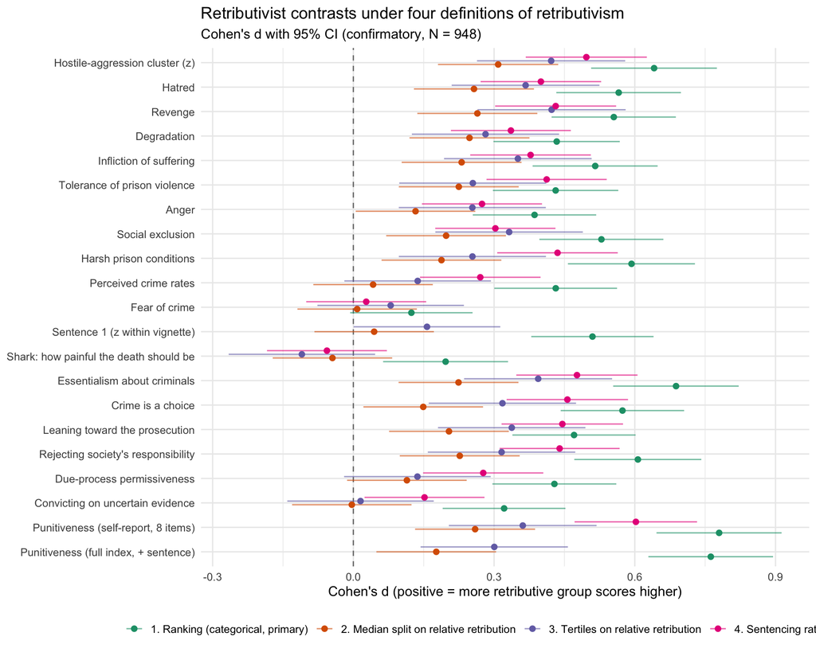

```r
# === FIGURE: THE PHASE 9 CONTRASTS UNDER ALL FOUR DEFINITIONS ===
# WHAT THIS CHUNK DOES: draws every confirmatory contrast as a dodged forest
# plot, one colour per definition of retributivism, and writes
# output/figures/retributivist_contrasts.png. A forest plot shows one point per
# result with a horizontal line through it for its confidence interval.
# "Dodged" means the four measures are nudged apart within a row so that they
# do not overprint each other.
#
# This is the picture version of the side-by-side table: four points and four
# intervals per outcome, so agreement or disagreement among the measures can be
# read at a glance. Where an outcome shows three points instead of four, the
# missing one is the sentencing-ratio measure, which does not run the
# sentence-based rows.
# E1 is excluded from the figure -- it is exploratory (prereg 6.6) and does not
# belong in a plot of the confirmatory contrasts, though it is still tabulated
# in 9.15.
plot_df <- all_contrasts[!is.na(all_contrasts$d) &
                           all_contrasts$hypothesis %in%
                           c("H13", "H14", "H15", "H16", "H17", "H18", "H19",
                             "H20", "H21"), ]
# The y axis order comes from making `outcome` a factor (a variable with a fixed
# set of levels in a fixed order) using the spec's order, not the effect sizes.
# Sorting by effect size would scatter the hypotheses through each other; this
# way outcomes stay grouped by hypothesis and the panel reads in H13-to-H21
# order. rev() is needed because ggplot draws the FIRST level at the BOTTOM.
plot_df$outcome <- factor(plot_df$outcome,
                          levels = rev(unique(contrast_spec$label)))
p_contrast <- ggplot2::ggplot(
  plot_df, ggplot2::aes(x = d, y = outcome, colour = measure)) +
  # The dashed vertical line marks d = 0, meaning no difference between the two
  # groups. An interval that crosses it is consistent with no effect at all.
  ggplot2::geom_vline(xintercept = 0, linetype = 2, colour = "grey50") +
  # position_dodge is what separates the four measures within one row. The width
  # MUST be the SAME here and on the points layer below. If the two widths ever
  # differ, an interval drifts off its own point and sits under a neighbour's,
  # which a reader would take as a result.
  ggplot2::geom_linerange(ggplot2::aes(xmin = d_lower, xmax = d_upper),
                          position = ggplot2::position_dodge(width = .6),
                          alpha = .6) +
  ggplot2::geom_point(position = ggplot2::position_dodge(width = .6), size = 2) +
  # Dark2 is a QUALITATIVE ColorBrewer palette: unrelated hues meant to be told
  # apart from one another, not shades of one colour meant to be read as a
  # ranking. The four measures are not ranked, so a graded colour ramp would
  # imply an order that is not there.
  ggplot2::scale_colour_brewer(palette = "Dark2") +
  # The N in the subtitle is read from the analysis frame rather than typed in,
  # so it can never disagree with the data the figure was actually drawn from.
  ggplot2::labs(title = "Retributivist contrasts under four definitions of retributivism",
                subtitle = sprintf("Cohen's d with 95%% CI (confirmatory, N = %d)", nrow(d)),
                x = "Cohen's d (positive = more retributive group scores higher)",
                y = NULL, colour = NULL) +
  ggplot2::theme_minimal(base_size = 12) +
  ggplot2::theme(legend.position = "bottom")
print(p_contrast)
```

```r
# ggsave() writes the PNG at a stated width, height and dpi (dots per inch, the
# resolution of the saved image), so the file on disk does not depend on the
# size of the plotting window at knit time. The path is then appended to
# FIGURES, the character vector (a simple ordered run of text values) that
# collects every figure written. Phase 10.2 only lists that vector back, so a
# figure left out of it lands on disk but is never reported.
fig_path <- file.path(OUT_FIGURES, "retributivist_contrasts.png")
ggplot2::ggsave(fig_path, p_contrast, width = 10, height = 8, dpi = 300)
FIGURES <- c(FIGURES, fig_path)
```

## 9.12b Retributivists against the deterrence- and incapacitation-first

The ranking contrasts in 9.3 set the 371 participants who ranked desert first against everyone else, and everyone else includes the 124 who ranked rehabilitation first. Of the four goals, rehabilitation is the only one that aims at the offender’s own good, so those participants may well be the least punitive in the sample. If they are, part of what separates retributivists from “everyone else” could be a difference from rehabilitationists in particular, not from people who value punishment for other reasons.

This subsection asks the sharper question. It sets the retributivists against the participants who ranked deterrence or incapacitation first: people who also value punishment, but for the crime it prevents. Where retributivists still differ from them, the difference cannot be put down to the rehabilitation-first participants alone. The contrast set is the one frozen in 9.3, unchanged: every row keeps its registered outcome and predicted direction, and only the comparison group is narrower.

Four limits. The groups are still defined by a self-reported ranking. Deterrence-first and incapacitation-first participants are pooled into one comparison group; the table of group means below shows each separately. The registered and the new comparison share all 371 retributivists and 453 of the 577 comparison participants, so they are not independent tests, and the change in d between them is described, not tested. And the comparison is not in the registration: it sits beside the registered contrasts, never in place of them, outside every registered family, with no multiplicity correction applied or implied.

```r
# === 9.12b RETRIBUTIVISTS AGAINST THE DETERRENCE- AND INCAPACITATION-FIRST ===
# WHAT THIS CHUNK DOES: builds a second grouping from the goal ranking that sets
# the participants who ranked desert first against those who ranked deterrence
# or incapacitation first, leaving the rehabilitation-first participants out.
# Reruns the full contrast set and the H15 logistic regression under it, sets
# every effect beside its registered counterpart from 9.3, and prints each
# outcome's mean for all four first-choice groups. Produces
# `contrasts_vs_deter_incap`, `contrasts_vs_deter_incap_compare`,
# `contrasts_vs_deter_incap_summary`, `first_choice_group_means` and
# `H15_logistic_vs_deter_incap`.
# PREREG: not registered. Prereg 5.3 defines the ranking contrast as desert-first
#         against everyone else, and 9.3 runs exactly that. This sits beside it
#         and never replaces it; outside every registered family; no
#         multiplicity correction applied or implied.
# CONSUMES: prio_cols and goal_labels (5.1), retributivist (5.1),
#           contrast_spec, run_contrast_set() and contrasts_rank (9.3),
#           h15_logit (9.6), logit_reg(), shark_kill.
#
# NOTHING HERE TOUCHES `d` OR contrast_spec. The new grouping lives in cq_d, a
# private copy of `d`. contrast_spec is used exactly as frozen in 9.3 (same
# rows, same order, same predicted directions), so every row below is the
# registered test with a narrower comparison group and nothing else changed.
# DANGER: do not add grp_vs_deter_incap to `d`. `d` is what Phase 10 exports as
# retribution_scored.csv, and a new column there would change a registered
# output file for the sake of a check that is not registered.
# NAMING: every object this chunk leaves behind starts with cq_ ("comparison
# group"), so no later chunk can pick one up by accident.

# --- Which goal each participant ranked first ------------------------------
# Recomputed with the same rule as 5.1 rather than borrowed from its
# `first_choice` vector, because that vector lines up with `d` only by row
# position, and this chunk should not depend on nothing having reordered `d`
# since 5.1. A row with a missing rank, or no rank of 1, is NA: unknown, never
# credited to a goal.
cq_first <- apply(d[, prio_cols], 1, function(r) {
  if (anyNA(r) || !any(r == 1)) return(NA_integer_)
  which(r == 1)[1]
})
# The four goals are found by NAME in goal_labels, so a change to the WORDING of
# a label cannot quietly point this code at the wrong goal: stopifnot() halts the
# knit if a name matches no label or more than one. What the lookup does NOT
# protect against is a change to the label ORDER. cq_first is a position within
# prio_cols, cq_idx() returns a position within goal_labels, and the two are
# compared as one index, which holds only because 5.1 writes the two vectors in
# the same order (it says so at 5.1's own comment on column position standing in
# for goal name). The guard below would catch a reorder that moved retribution,
# because d$retributivist is tied to Prioritization_1 directly; a reorder that
# swapped only deterrence, incapacitation or rehabilitation would pass silently.
cq_idx <- function(pattern) {
  i <- grep(pattern, goal_labels, ignore.case = TRUE)
  stopifnot(length(i) == 1)
  i
}
cq_ret <- cq_idx("retribution")
cq_det <- cq_idx("deterrence")
cq_inc <- cq_idx("incapacitation")
cq_reh <- cq_idx("rehabilitation")
# GUARD: the desert-first group here must be exactly the registered
# retributivists, person for person. If it were not, this comparison and the
# registered one would be about two different sets of people and could not be
# read side by side.
stopifnot(identical(which(cq_first == cq_ret), which(d$retributivist == 1)))

cq_d <- d
# The FIRST level is the retributive side, as run_contrast_set() requires, so a
# positive d means retributivists score higher, exactly as everywhere else in
# Phase 9. The rehabilitation-first participants get NA, and welch_contrast()
# drops NA-group rows contrast by contrast, as it already does for the middle
# third under the tertile grouping.
cq_d$grp_vs_deter_incap <- factor(
  ifelse(cq_first == cq_ret, "Retributivist",
         ifelse(cq_first %in% c(cq_det, cq_inc),
                "Deterrence or incapacitation first", NA_character_)),
  levels = c("Retributivist", "Deterrence or incapacitation first"))
# The same people coded 1/0 for the logistic regression, NA for the excluded.
cq_d$retrib_vs_deter_incap <- as.integer(cq_d$grp_vs_deter_incap == "Retributivist")

# Who is in this comparison, by the goal they ranked first.
cq_role <- rep("left out", length(goal_labels))
cq_role[cq_ret] <- "retributivists"
cq_role[c(cq_det, cq_inc)] <- "comparison group"
cq_counts <- data.frame(
  first_ranked = goal_labels,
  n = as.integer(table(factor(cq_first, levels = seq_along(goal_labels)))),
  role_here = cq_role, stringsAsFactors = FALSE)
show_table(cq_counts, "9.12b: who is in this comparison, by the goal ranked first")
```

9.12b: who is in this comparison, by the goal ranked first

| first_ranked | n | role_here |
| --- | --- | --- |
| Criminals deserve to be punished (retribution) | 371 | retributivists |
| Punishment deters others (deterrence) | 187 | comparison group |
| Locked up, prisoners cannot offend (incapacitation) | 266 | comparison group |
| Prisoners get rehabilitated (rehabilitation) | 124 | left out |

```r
# --- The contrast set against the narrower comparison group ----------------
# drop_sentence_based stays FALSE, as in 9.3 and 9.11. This grouping is built
# from the goal ranking, not from the sentence, so H14 and the full punitiveness
# index can be contrasted under it without circularity.
cq_contrasts <- run_contrast_set(cq_d, "grp_vs_deter_incap")
TABLES[["contrasts_vs_deter_incap"]] <- cq_contrasts
show_table(cq_contrasts[, c("hypothesis", "outcome", "n1", "n2", "M1", "M2",
                            "t", "df", "p_dir", "d", "d_lower", "d_upper")],
           paste("9.12b: the contrast set, retributivists (M1) against the",
                 "deterrence- or incapacitation-first (M2). One-sided in each",
                 "row's registered direction; not corrected."))
```

9.12b: the contrast set, retributivists (M1) against the deterrence- or incapacitation-first (M2). One-sided in each row’s registered direction; not corrected.

| hypothesis | outcome | n1 | n2 | M1 | M2 | t | df | p_dir | d | d_lower | d_upper |
| --- | --- | --- | --- | --- | --- | --- | --- | --- | --- | --- | --- |
| H13 | Hostile-aggression cluster (z) | 371 | 453 | 0.297 | -0.104 | 7.525 | 792.9 | 0.000 | 0.527 | 0.387 | 0.666 |
| H13 | Hatred | 371 | 453 | 4.473 | 3.806 | 6.812 | 797.1 | 0.000 | 0.476 | 0.337 | 0.615 |
| H13 | Revenge | 371 | 453 | 4.596 | 4.004 | 6.397 | 799.6 | 0.000 | 0.447 | 0.308 | 0.586 |
| H13 | Degradation | 371 | 453 | 3.887 | 3.434 | 5.172 | 734.1 | 0.000 | 0.365 | 0.225 | 0.504 |
| H13 | Infliction of suffering | 371 | 453 | 4.137 | 3.468 | 5.971 | 782.1 | 0.000 | 0.419 | 0.280 | 0.557 |
| H13 | Tolerance of prison violence | 371 | 453 | 3.280 | 2.807 | 4.946 | 767.0 | 0.000 | 0.347 | 0.209 | 0.486 |
| H13 | Anger | 371 | 453 | 4.821 | 4.331 | 4.423 | 793.2 | 0.000 | 0.310 | 0.171 | 0.447 |
| H13 | Social exclusion | 371 | 453 | 4.937 | 4.383 | 5.903 | 795.7 | 0.000 | 0.413 | 0.274 | 0.551 |
| H13 | Harsh prison conditions | 371 | 453 | 3.665 | 2.918 | 7.382 | 755.6 | 0.000 | 0.519 | 0.379 | 0.660 |
| H13 | Perceived crime rates | 371 | 453 | 5.410 | 4.955 | 4.973 | 804.8 | 0.000 | 0.347 | 0.209 | 0.485 |
| H13 | Fear of crime | 371 | 453 | 3.196 | 3.113 | 0.885 | 796.4 | 0.188 | 0.062 | -0.075 | 0.199 |
| H14 | Sentence 1 (z within vignette) | 371 | 453 | 0.296 | -0.092 | 5.872 | 820.4 | 0.000 | 0.408 | 0.270 | 0.545 |
| H15 | Shark: how painful the death should be | 371 | 453 | 2.027 | 1.607 | 3.856 | 679.5 | 0.000 | 0.274 | 0.134 | 0.413 |
| H16 | Essentialism about criminals | 371 | 453 | 4.250 | 3.573 | 8.463 | 795.5 | 0.000 | 0.592 | 0.452 | 0.732 |
| H17 | Crime is a choice | 371 | 453 | 5.187 | 4.503 | 6.697 | 814.0 | 0.000 | 0.467 | 0.328 | 0.605 |
| H18 | Leaning toward the prosecution | 371 | 453 | 0.391 | 0.161 | 5.108 | 806.1 | 0.000 | 0.357 | 0.219 | 0.494 |
| H19 | Rejecting society’s responsibility | 371 | 453 | 3.957 | 3.268 | 7.073 | 766.5 | 0.000 | 0.497 | 0.357 | 0.637 |
| H20 | Due-process permissiveness | 371 | 453 | 3.285 | 2.884 | 4.957 | 789.2 | 0.000 | 0.347 | 0.209 | 0.485 |
| H20 | Convicting on uncertain evidence | 371 | 453 | 3.155 | 2.871 | 3.797 | 791.3 | 0.000 | 0.266 | 0.128 | 0.404 |
| H21 | Punitiveness (self-report, 8 items) | 371 | 453 | 4.640 | 3.887 | 9.291 | 818.4 | 0.000 | 0.646 | 0.506 | 0.786 |
| H21 | Punitiveness (full index, + sentence) | 371 | 453 | 0.367 | -0.121 | 8.998 | 819.6 | 0.000 | 0.625 | 0.486 | 0.765 |
| E1 | Right-Wing Authoritarianism | 371 | 453 | 3.990 | 3.306 | 6.249 | 796.9 | 0.000 | 0.437 | 0.298 | 0.576 |
| E1 | Social Dominance Orientation | 371 | 453 | 2.863 | 2.440 | 4.424 | 727.9 | 0.000 | 0.312 | 0.173 | 0.451 |
| E1 | Violence proneness | 371 | 453 | 3.416 | 2.992 | 4.777 | 807.7 | 0.000 | 0.333 | 0.196 | 0.471 |
| E1 | Racial resentment | 371 | 453 | 4.006 | 3.414 | 4.623 | 765.1 | 0.000 | 0.325 | 0.186 | 0.463 |
| E1 | Cognitive reflection (0-3) | 369 | 452 | 1.504 | 1.456 | 0.563 | 786.4 | 0.713 | 0.040 | -0.098 | 0.177 |
| E1 | Cognitive reflection (0-2, lily pad dropped) | 369 | 452 | 0.997 | 0.945 | 0.903 | 785.0 | 0.816 | 0.063 | -0.074 | 0.201 |

```r
# --- Every effect beside its registered counterpart -------------------------
# Joined on the row label, which contrast_spec keeps unique, and then put back
# into the spec's own order so the table reads H13 to E1 as 9.3 does.
cq_cmp <- merge(
  contrasts_rank[, c("hypothesis", "outcome", "alternative", "n1", "n2",
                     "d", "d_lower", "d_upper", "p_dir")],
  cq_contrasts[, c("outcome", "n1", "n2", "d", "d_lower", "d_upper", "p_dir")],
  by = "outcome", suffixes = c("_vs_all_others", "_vs_deter_incap"))
cq_cmp <- cq_cmp[match(contrast_spec$label, cq_cmp$outcome), ]
rownames(cq_cmp) <- NULL
# The change in d, new minus registered. Descriptive only: the two runs share
# most of their participants, so this difference is not a test of anything.
cq_cmp$d_change <- cq_cmp$d_vs_deter_incap - cq_cmp$d_vs_all_others
# The same change read in each row's PREDICTED direction: positive means the
# effect moved further toward the prediction. It differs from d_change only on
# the two cognitive-reflection rows, which predict retributivists LOWER, so
# there a falling d is a gain. Used for the printed summary below, so the rows
# predicted "less" are not averaged in with the wrong sign.
cq_cmp$d_change_toward_prediction <- ifelse(cq_cmp$alternative == "less",
                                            -cq_cmp$d_change, cq_cmp$d_change)
# Whether each interval clears zero on the predicted side. Read off the
# interval, not the p value, and in each row's own direction, so the cognitive
# reflection rows (predicted LOWER for retributivists) count when d is negative.
cq_clears <- function(lo, hi, alt) ifelse(alt == "less", hi < 0, lo > 0)
cq_cmp$clears_vs_all_others <- cq_clears(cq_cmp$d_lower_vs_all_others,
                                         cq_cmp$d_upper_vs_all_others,
                                         cq_cmp$alternative)
cq_cmp$clears_vs_deter_incap <- cq_clears(cq_cmp$d_lower_vs_deter_incap,
                                          cq_cmp$d_upper_vs_deter_incap,
                                          cq_cmp$alternative)
TABLES[["contrasts_vs_deter_incap_compare"]] <- cq_cmp
show_table(cq_cmp[, c("hypothesis", "outcome", "n2_vs_all_others",
                      "d_vs_all_others", "n2_vs_deter_incap",
                      "d_vs_deter_incap", "d_lower_vs_deter_incap",
                      "d_upper_vs_deter_incap", "d_change",
                      "clears_vs_deter_incap")],
           paste("9.12b: Cohen's d against everyone else (registered, 9.3) and",
                 "against the deterrence- or incapacitation-first. n2 is the",
                 "size of the comparison group in each."))
```

9.12b: Cohen’s d against everyone else (registered, 9.3) and against the deterrence- or incapacitation-first. n2 is the size of the comparison group in each.

| hypothesis | outcome | n2_vs_all_others | d_vs_all_others | n2_vs_deter_incap | d_vs_deter_incap | d_lower_vs_deter_incap | d_upper_vs_deter_incap | d_change | clears_vs_deter_incap |
| --- | --- | --- | --- | --- | --- | --- | --- | --- | --- |
| H13 | Hostile-aggression cluster (z) | 577 | 0.641 | 453 | 0.527 | 0.387 | 0.666 | -0.114 | TRUE |
| H13 | Hatred | 577 | 0.566 | 453 | 0.476 | 0.337 | 0.615 | -0.089 | TRUE |
| H13 | Revenge | 577 | 0.555 | 453 | 0.447 | 0.308 | 0.586 | -0.108 | TRUE |
| H13 | Degradation | 577 | 0.434 | 453 | 0.365 | 0.225 | 0.504 | -0.069 | TRUE |
| H13 | Infliction of suffering | 577 | 0.516 | 453 | 0.419 | 0.280 | 0.557 | -0.097 | TRUE |
| H13 | Tolerance of prison violence | 577 | 0.431 | 453 | 0.347 | 0.209 | 0.486 | -0.084 | TRUE |
| H13 | Anger | 577 | 0.386 | 453 | 0.310 | 0.171 | 0.447 | -0.077 | TRUE |
| H13 | Social exclusion | 577 | 0.529 | 453 | 0.413 | 0.274 | 0.551 | -0.116 | TRUE |
| H13 | Harsh prison conditions | 577 | 0.593 | 453 | 0.519 | 0.379 | 0.660 | -0.074 | TRUE |
| H13 | Perceived crime rates | 577 | 0.431 | 453 | 0.347 | 0.209 | 0.485 | -0.084 | TRUE |
| H13 | Fear of crime | 577 | 0.124 | 453 | 0.062 | -0.075 | 0.199 | -0.062 | FALSE |
| H14 | Sentence 1 (z within vignette) | 577 | 0.510 | 453 | 0.408 | 0.270 | 0.545 | -0.102 | TRUE |
| H15 | Shark: how painful the death should be | 577 | 0.197 | 453 | 0.274 | 0.134 | 0.413 | 0.077 | TRUE |
| H16 | Essentialism about criminals | 577 | 0.688 | 453 | 0.592 | 0.452 | 0.732 | -0.096 | TRUE |
| H17 | Crime is a choice | 577 | 0.574 | 453 | 0.467 | 0.328 | 0.605 | -0.107 | TRUE |
| H18 | Leaning toward the prosecution | 577 | 0.470 | 453 | 0.357 | 0.219 | 0.494 | -0.114 | TRUE |
| H19 | Rejecting society’s responsibility | 577 | 0.607 | 453 | 0.497 | 0.357 | 0.637 | -0.110 | TRUE |
| H20 | Due-process permissiveness | 577 | 0.429 | 453 | 0.347 | 0.209 | 0.485 | -0.081 | TRUE |
| H20 | Convicting on uncertain evidence | 577 | 0.321 | 453 | 0.266 | 0.128 | 0.404 | -0.056 | TRUE |
| H21 | Punitiveness (self-report, 8 items) | 577 | 0.780 | 453 | 0.646 | 0.506 | 0.786 | -0.134 | TRUE |
| H21 | Punitiveness (full index, + sentence) | 577 | 0.762 | 453 | 0.625 | 0.486 | 0.765 | -0.137 | TRUE |
| E1 | Right-Wing Authoritarianism | 577 | 0.487 | 453 | 0.437 | 0.298 | 0.576 | -0.050 | TRUE |
| E1 | Social Dominance Orientation | 577 | 0.386 | 453 | 0.312 | 0.173 | 0.451 | -0.073 | TRUE |
| E1 | Violence proneness | 577 | 0.387 | 453 | 0.333 | 0.196 | 0.471 | -0.054 | TRUE |
| E1 | Racial resentment | 577 | 0.418 | 453 | 0.325 | 0.186 | 0.463 | -0.093 | TRUE |
| E1 | Cognitive reflection (0-3) | 576 | 0.025 | 452 | 0.040 | -0.098 | 0.177 | 0.015 | FALSE |
| E1 | Cognitive reflection (0-2, lily pad dropped) | 576 | 0.053 | 452 | 0.063 | -0.074 | 0.201 | 0.010 | FALSE |

```r
# --- The same comparison in summary -----------------------------------------
# The sign check reads each row's own predicted direction, exactly as the
# scorecard in 9.12 does, and the median of |d| keeps one large effect from
# making a whole column look sharp.
cq_pred_sign <- function(dd, alt) sum(ifelse(alt == "less", dd < 0, dd > 0), na.rm = TRUE)
cq_summary <- data.frame(
  comparison = c("Retributivists vs everyone else (registered, 9.3)",
                 "Retributivists vs deterrence- or incapacitation-first"),
  n_outcomes = c(sum(!is.na(cq_cmp$d_vs_all_others)),
                 sum(!is.na(cq_cmp$d_vs_deter_incap))),
  n_predicted_sign = c(cq_pred_sign(cq_cmp$d_vs_all_others, cq_cmp$alternative),
                       cq_pred_sign(cq_cmp$d_vs_deter_incap, cq_cmp$alternative)),
  n_interval_clears_zero = c(sum(cq_cmp$clears_vs_all_others, na.rm = TRUE),
                             sum(cq_cmp$clears_vs_deter_incap, na.rm = TRUE)),
  median_abs_d = c(median(abs(cq_cmp$d_vs_all_others), na.rm = TRUE),
                   median(abs(cq_cmp$d_vs_deter_incap), na.rm = TRUE)),
  stringsAsFactors = FALSE)
TABLES[["contrasts_vs_deter_incap_summary"]] <- cq_summary
show_table(cq_summary, "9.12b: the registered and the narrower comparison in summary")
```

9.12b: the registered and the narrower comparison in summary

| comparison | n_outcomes | n_predicted_sign | n_interval_clears_zero | median_abs_d |
| --- | --- | --- | --- | --- |
| Retributivists vs everyone else (registered, 9.3) | 27 | 25 | 24 | 0.470 |
| Retributivists vs deterrence- or incapacitation-first | 27 | 25 | 24 | 0.365 |

```r
# The outcomes whose interval cleared zero against everyone else but no longer
# does against the deterrence- or incapacitation-first, named, so no reader has
# to find them in the table. Guarded, so no sentence can print over a table that
# does not support it.
cq_lost <- cq_cmp$outcome[cq_cmp$clears_vs_all_others %in% TRUE &
                            !(cq_cmp$clears_vs_deter_incap %in% TRUE)]
cq_gained <- cq_cmp$outcome[!(cq_cmp$clears_vs_all_others %in% TRUE) &
                              cq_cmp$clears_vs_deter_incap %in% TRUE]
cat(sprintf(paste("\nMedian change in d, narrower minus registered, read in",
                  "each row's predicted direction: %+.3f.\n"),
            median(cq_cmp$d_change_toward_prediction, na.rm = TRUE)))
```

```
##
## Median change in d, narrower minus registered, read in each row's predicted direction: -0.084.
```

```r
# Any outcome whose effect GREW when the rehabilitation-first were left out,
# named: on such a row those participants were not at the low end, so leaving
# them out pulled the comparison group's mean down rather than up.
# The parentheses matter: %in% binds tighter than >, and %in% TRUE turns an NA
# comparison into FALSE, so a row with no estimate is never listed.
cq_grew <- cq_cmp$outcome[(cq_cmp$d_change_toward_prediction > 0) %in% TRUE]
if (length(cq_grew)) {
  cat("Effect grew in the predicted direction with the rehabilitation-first left out:\n")
  cat(paste0("  - ", cq_grew, collapse = "\n"), "\n")
}
```

```
## Effect grew in the predicted direction with the rehabilitation-first left out:
##   - Shark: how painful the death should be
```

```r
if (length(cq_lost)) {
  cat("Interval cleared zero against everyone else but not against the\n")
  cat("deterrence- or incapacitation-first:\n")
  cat(paste0("  - ", cq_lost, collapse = "\n"), "\n")
} else {
  cat("Every outcome whose interval cleared zero against everyone else still\n")
  cat("clears it against the deterrence- or incapacitation-first.\n")
}
```

```
## Every outcome whose interval cleared zero against everyone else still
## clears it against the deterrence- or incapacitation-first.
```

```r
if (length(cq_gained)) {
  cat("Interval clears zero only against the narrower comparison group:\n")
  cat(paste0("  - ", cq_gained, collapse = "\n"), "\n")
}

# --- H15's yes/no decision, the one outcome outside the contrast set -------
# The shark decision is binary, so it gets logistic regression here as it does
# in 9.6, with the same one-sided direction. The registered row is reprinted
# from 9.6 beside the new one rather than recomputed.
cq_h15 <- logit_reg(cq_d, "shark_kill", "retrib_vs_deter_incap",
                    alternative = "greater",
                    label = "Shark to death (yes/no): vs deterrence- or incapacitation-first")
TABLES[["H15_logistic_vs_deter_incap"]] <- cq_h15
show_table(rbind(h15_logit, cq_h15),
           "9.12b: H15's shark decision against everyone else (registered, 9.6) and against the deterrence- or incapacitation-first")
```

9.12b: H15’s shark decision against everyone else (registered, 9.6) and against the deterrence- or incapacitation-first

| outcome | predictor | n | b | se | OR | OR_lower | OR_upper | z | p_two | p_dir | alternative |
| --- | --- | --- | --- | --- | --- | --- | --- | --- | --- | --- | --- |
| Put the shark to death (yes/no) | retrib_num | 948 | 0.481 | 0.142 | 1.617 | 1.223 | 2.138 | 3.373 | 0.001 | 0.000 | greater |
| Shark to death (yes/no): vs deterrence- or incapacitation-first | retrib_vs_deter_incap | 824 | 0.398 | 0.149 | 1.489 | 1.111 | 1.995 | 2.665 | 0.008 | 0.004 | greater |

```r
# --- Where each first-choice group sits -------------------------------------
# Descriptive only, no test: each outcome's mean for all four first-choice
# groups, so a reader can see where the rehabilitation-first participants sit
# relative to the deterrence- and incapacitation-first. Leaving them out changes
# the comparison group's mean, its SD (which is in d's denominator, since d uses
# the unpooled SD) and its size (which sets each interval's width). In these data
# the shift in the mean does almost all the work. Computed on `d`, the full
# sample, since every participant has a first choice.
cq_means <- do.call(rbind, lapply(seq_len(nrow(contrast_spec)), function(i) {
  y <- suppressWarnings(as.numeric(d[[contrast_spec$outcome[i]]]))
  m <- tapply(y, factor(cq_first, levels = seq_along(goal_labels)), mean,
              na.rm = TRUE)
  data.frame(hypothesis = contrast_spec$hypothesis[i],
             outcome = contrast_spec$label[i],
             desert_first = unname(m[cq_ret]),
             deterrence_first = unname(m[cq_det]),
             incapacitation_first = unname(m[cq_inc]),
             rehabilitation_first = unname(m[cq_reh]),
             stringsAsFactors = FALSE)
}))
TABLES[["first_choice_group_means"]] <- cq_means
show_table(cq_means, "9.12b: mean of each outcome by the goal ranked first (descriptive)")
```

9.12b: mean of each outcome by the goal ranked first (descriptive)

| hypothesis | outcome | desert_first | deterrence_first | incapacitation_first | rehabilitation_first |
| --- | --- | --- | --- | --- | --- |
| H13 | Hostile-aggression cluster (z) | 0.297 | -0.080 | -0.120 | -0.509 |
| H13 | Hatred | 4.473 | 3.832 | 3.788 | 3.202 |
| H13 | Revenge | 4.596 | 4.070 | 3.958 | 3.306 |
| H13 | Degradation | 3.887 | 3.399 | 3.459 | 3.051 |
| H13 | Infliction of suffering | 4.137 | 3.548 | 3.412 | 2.742 |
| H13 | Tolerance of prison violence | 3.280 | 2.853 | 2.774 | 2.315 |
| H13 | Anger | 4.821 | 4.372 | 4.303 | 3.754 |
| H13 | Social exclusion | 4.937 | 4.301 | 4.441 | 3.599 |
| H13 | Harsh prison conditions | 3.665 | 2.920 | 2.917 | 2.441 |
| H13 | Perceived crime rates | 5.410 | 5.003 | 4.921 | 4.391 |
| H13 | Fear of crime | 3.196 | 3.205 | 3.049 | 2.734 |
| H14 | Sentence 1 (z within vignette) | 0.296 | -0.140 | -0.057 | -0.551 |
| H15 | Shark: how painful the death should be | 2.027 | 1.770 | 1.492 | 2.097 |
| H16 | Essentialism about criminals | 4.250 | 3.513 | 3.616 | 2.986 |
| H17 | Crime is a choice | 5.187 | 4.508 | 4.500 | 3.726 |
| H18 | Leaning toward the prosecution | 0.391 | 0.150 | 0.169 | -0.194 |
| H19 | Rejecting society’s responsibility | 3.957 | 3.176 | 3.332 | 2.608 |
| H20 | Due-process permissiveness | 3.285 | 2.884 | 2.885 | 2.441 |
| H20 | Convicting on uncertain evidence | 3.155 | 2.968 | 2.804 | 2.569 |
| H21 | Punitiveness (self-report, 8 items) | 4.640 | 3.886 | 3.889 | 3.109 |
| H21 | Punitiveness (full index, + sentence) | 0.367 | -0.146 | -0.104 | -0.655 |
| E1 | Right-Wing Authoritarianism | 3.990 | 3.442 | 3.211 | 2.884 |
| E1 | Social Dominance Orientation | 2.863 | 2.384 | 2.479 | 1.985 |
| E1 | Violence proneness | 3.416 | 3.159 | 2.874 | 2.645 |
| E1 | Racial resentment | 4.006 | 3.503 | 3.352 | 2.645 |
| E1 | Cognitive reflection (0-3) | 1.504 | 1.529 | 1.404 | 1.540 |
| E1 | Cognitive reflection (0-2, lily pad dropped) | 0.997 | 1.005 | 0.902 | 0.984 |

```r
# How often the rehabilitation-first group sits at the least-retributive end:
# the LOWEST of the four means on a row predicted "greater", the HIGHEST on the
# rows predicted "less". Counted in each row's own direction for the same reason
# as the sign check above.
cq_rehab_extreme <- vapply(seq_len(nrow(cq_means)), function(i) {
  v <- unlist(cq_means[i, c("desert_first", "deterrence_first",
                            "incapacitation_first", "rehabilitation_first")])
  if (anyNA(v)) return(NA)
  if (contrast_spec$alternative[i] == "less") which.max(v) == 4 else which.min(v) == 4
}, logical(1))
cat(sprintf(paste("\nThe rehabilitation-first group has the least-retributive",
                  "mean on %d of %d outcomes.\n"),
            sum(cq_rehab_extreme, na.rm = TRUE), sum(!is.na(cq_rehab_extreme))))
```

```
##
## The rehabilitation-first group has the least-retributive mean on 25 of 27 outcomes.
```

```r
cq_not_extreme <- cq_means$outcome[cq_rehab_extreme %in% FALSE]
if (length(cq_not_extreme)) {
  cat("Outcomes on which it does not:\n")
  cat(paste0("  - ", cq_not_extreme, collapse = "\n"), "\n")
}
```

```
## Outcomes on which it does not:
##   - Shark: how painful the death should be
##   - Cognitive reflection (0-2, lily pad dropped)
```

## 9.13 The contrast set run on each slice of the retribution scale

The survey asked seven questions about retribution. Those seven items fall into three tiers, three groups that make different kinds of claim: the **soft core** (R1, R3, R4), the **obligation** items (R2, R5) and the two **rationales** (R6, R7). A slice, in this section, is any one of the six scorings of these items entered as a predictor below: the three tiers, the soft core with R3 removed, and the two registered composites.

Which tier R3 belongs to is genuinely unsettled. *“Justice is restored when criminals are punished”* is not a claim that punishing is permitted. It says punishment **achieves** something, and that is the positive-retributive position, the very thing the soft tier is meant to hold apart from. So the soft core is scored twice, once with R3 and once without, and every table below carries both versions. That way no conclusion rests on where R3 is filed.

This section runs the whole contrast set once on each slice, once on the registered four-item `deserved` composite and once on the registered seven-item subscale. It prints the runs as one grid: one row per outcome, one column per slice. A reader can then read along a single row and see whether a conclusion depends on which part of the scale is used to define retributivism.

What this is, and what it is not. Nothing here displaces the registered runs in 9.9. **One** column, the seven-item subscale, is the registered raw run from 9.9 recomputed by the same function from the same predictor, and the chunk checks that it comes back identical. The `deserved` column feeds a registered *composite*, a score made by averaging several items, into the continuous machinery, which 9.9 does not do. That column is therefore an additional display and not a registered test. The slices are also not independent measures of anything. The soft core is three of the four items of `deserved`, so its column is close to a copy of the `deserved` column rather than a second opinion about it. This section earns its place by putting a printed number on **whether** the conclusions turn on which slice of the scale is used. It is a robustness demonstration, and a result that survives it is the registered result surviving an objection, not a new finding.

```r
# === THE SLICES OF THE RETRIBUTION SCALE (prereg 5.3, 5.4, 6.5) ===
# WHAT THIS CHUNK DOES: builds the continuous predictors used in the grid below,
# then prints how far they overlap in ITEMS and how far they overlap in
# VARIANCE. A continuous predictor is a score that runs along a scale, rather
# than a label that sorts people into groups. Overlapping in ITEMS means two
# slices are built from some of the same questions. Variance is how spread out a
# set of scores is, so overlapping in VARIANCE means two slices spread people
# out in much the same way even where the questions differ. Produces
# `tier_item_sets`, `tier_slice_labels` and `tier_predictor_correlations`.
#
# WHY BOTH KINDS OF OVERLAP MATTER. Two slices that share items MUST correlate,
# because part of each score is literally the same numbers. Reading that as
# agreement between two measures would be circular. Printing the shared-item
# count next to the correlation is what keeps a reader from making that mistake.
#
# THE SLICES, and what each one asserts:
#   deserved_soft          R1, R3, R4. Society has a moral right to punish;
#                          justice is restored when criminals are punished;
#                          punishment is justified because criminals deserve
#                          it. The weaker claim: punishing the guilty is
#                          warranted.
#   deserved_soft_strict   R1, R4. The same tier with R3 removed. R3 says
#                          punishment RESTORES justice, which is an achievement
#                          claim rather than a permission, so it arguably sits
#                          with the obligation tier instead. Both versions are
#                          carried rather than a choice being made silently.
#   retribution_hard       R2, R5. Justice REQUIRES that crimes be punished;
#                          the state has a DUTY to punish. The stronger claim:
#                          failing to punish is itself a wrong. This tier is
#                          the closer of the two to what the philosophical
#                          literature calls positive retributivism, with the
#                          soft tier nearer the negative, permission-only
#                          version.
#   retribution_rationale  R6, R7. Punishment lets criminals repay their debt
#                          to society, and it negates the unfair advantage they
#                          gained over law-abiding citizens. These two give a
#                          REASON why desert holds rather than asserting that
#                          it does, which is why they are the two items a
#                          philosopher is most likely to say do not belong with
#                          the rest.
#   deserved               REGISTERED (prereg 5.4): R1-R4, the purpose items,
#                          scored in Phase 4.3 and used here exactly as scored.
#   retribution            REGISTERED (prereg 5.3): all seven items, scored in
#                          Phase 4.1 and used here exactly as scored.

# The list of items behind every slice, written down in one place. The two
# registered entries RESTATE definitions already made in Phase 4.1 and
# Phase 4.3. They are bookkeeping for the overlap table below and are NEVER used
# to rebuild those composites, which are read out of `d` exactly as Phase 4
# scored them. Writing the item sets down once also means the overlap counts
# below are computed rather than typed, so they cannot drift out of step with
# the scoring.
tier_item_sets <- list(
  deserved_soft         = paste0("Retribution_", c(1, 3, 4)),
  deserved_soft_strict  = paste0("Retribution_", c(1, 4)),
  retribution_hard      = paste0("Retribution_", c(2, 5)),
  retribution_rationale = paste0("Retribution_", c(6, 7)),
  deserved              = paste0("Retribution_", 1:4),
  retribution           = paste0("Retribution_", 1:7))

# The four slices this section is willing to score for itself. `deserved` and
# `retribution` are deliberately absent. Rebuilding either would put a second,
# differently-labelled copy of a registered composite into the reliability
# table, and that copy could drift away from the registered column without
# anyone noticing. The registered composites are used exactly as Phase 4 left
# them.
tier_new_slices <- c("deserved_soft", "deserved_soft_strict",
                     "retribution_hard", "retribution_rationale")
# compute_composite() uses the label as the row key of the reliability table, so
# these labels have to stay unique across the whole document. Reusing a label
# would file two different composites under one name and make the reliability
# table unreadable.
tier_alpha_labels <- c(
  deserved_soft         = "retribution: soft core (R1,R3,R4)",
  deserved_soft_strict  = "retribution: soft core strict (R1,R4)",
  retribution_hard      = "retribution: obligation (R2,R5)",
  retribution_rationale = "retribution: rationales (R6,R7)")

# A guard, not a rebuild. `!nm %in% names(d)` asks whether the slice is already
# a column of `d`. It is, in a normal top-to-bottom knit, because Phase 4 scored
# all four. The loop then does nothing. The guard exists only so this section
# still works when someone runs the chunks out of order in an interactive
# session and Phase 4 has not been executed yet. Going through
# compute_composite() rather than taking a mean by hand keeps the
# at-least-half-the-items scoring rule (prereg 5.1) identical either way. Under
# that rule a person who answered fewer than half the items of a slice gets NA,
# R's marker for a missing value, rather than a score. Half is rounded up, so
# the threshold is 2 of 3 for the soft core and 1 of 2 for the three two-item
# slices, where one answered item is therefore enough to be scored.
#
# WHERE THE RELIABILITY OF A SLICE ENDS UP. Cronbach's alpha and McDonald's
# omega are two numbers saying how consistently a set of questions behaves as
# one scale. compute_composite() appends them to the live `alpha_table` with
# <<-, which writes to a variable outside the function. But Phase 4.10 takes a
# COPY of that table into `alpha_table_out`, and it is the COPY that Phase 10.1
# exports as reliability_alpha_omega.csv and that Phase 10.3 writes to
# data/cleaned/reliability_table.csv. So a row appended after 4.10 reaches
# NEITHER file. It survives only as a line printed to the console during the
# knit, which no reader of the replication package will ever see. Whatever these
# guards append is therefore collected again at the end of 9.14 and registered
# as a table of its own, so the alphas are in the replication package no matter
# where the slices happened to be scored.
for (nm in tier_new_slices) {
  if (!nm %in% names(d)) {
    d[[nm]] <- compute_composite(d, tier_item_sets[[nm]],
                                 tier_alpha_labels[[nm]])
  }
}
```

```r
# One named vector (a simple run of values, each with a name attached) drives
# everything below. The NAMES are columns in `d`; the VALUES are the labels
# printed in the tables. Numbering the labels "1." to "6." fixes the column
# order of the grid, because the pivot below lays columns out in order of first
# appearance. Without the numbers an alphabetical ordering would scatter the two
# REGISTERED measures into the middle of the grid, where a reader would have to
# hunt for the columns that actually matter.
tier_slice_labels <- c(
  deserved_soft         = "1. Soft core R1,R3,R4",
  deserved_soft_strict  = "2. Soft core strict R1,R4",
  retribution_hard      = "3. Obligation R2,R5",
  retribution_rationale = "4. Rationales R6,R7",
  deserved              = "5. REGISTERED deserved R1-R4",
  retribution           = "6. REGISTERED retribution, 7 items")
# Every count printed in this section is read off this vector rather than typed
# in by hand. If a slice is ever added or reordered, no sentence is left behind
# saying "five" when there are now six.
n_slices <- length(tier_slice_labels)

# HOW CLOSELY THE SLICES TRACK EACH OTHER. This correlation matrix, a square
# table holding the correlation of every slice with every other slice, is the
# reason the grid below is expected to be dull reading. The seven-item scale has
# a Cronbach's alpha of about .90, meaning the seven questions already behave as
# one tight set, so any slice of it carries much of the same information as any
# other slice.
#   use = "pairwise.complete.obs" is pairwise deletion: for each PAIR of slices,
# R uses everyone who has a score on both, so a participant who skipped one item
# still contributes to every pair they did answer. That is exactly the rule
# cor_row() applies to a pair, so a number here matches the corresponding
# cor_row() line elsewhere in the document. It is NOT the rule steiger_overlap()
# uses. Steiger's test for dependent overlapping correlations, which compares
# two correlations that share a variable, needs complete cases across all THREE
# of its columns, meaning it keeps only people with no missing value on any of
# them. So a correlation that also appears in a Steiger table can differ there
# in the last decimal. That is a difference in who was included, not a mistake.
#   as.data.frame() converts `d` from a tibble (the tidyverse's table type) into
# an ordinary data frame (a table with named columns), because cor() expects an
# ordinary frame.
tier_cor <- stats::cor(as.data.frame(d[, names(tier_slice_labels)]),
                       use = "pairwise.complete.obs")

# PART-WHOLE, NAMED CELL BY CELL RATHER THAN COLUMN BY COLUMN. A part-whole
# correlation is one where a measure is correlated with something it is itself
# part of, so the two are guaranteed to agree and the number says nothing about
# whether two separate things go together. A blanket warning that "the
# registered columns are part-whole" would be false and would throw away the
# cells that do carry information. `deserved` is R1-R4: it contains both soft
# versions whole, it shares R2 with the obligation tier's two items, and it
# shares NO item with the rationale tier. That last pair is therefore a clean
# correlation between two disjoint halves of the same block, and it is the most
# informative line in the table. Disjoint means the two slices share no item at
# all, and it is what the "disjoint: clean" cell in the relation column marks.
# The seven-item scale contains every slice, so its column is part-whole
# throughout. Each pair is labelled below with the number of items it shares,
# and the table is sorted so the uncontaminated pairs come first. Without those
# labels a reader would take a high correlation between a part and the whole it
# sits in as strong evidence of agreement, when it is mostly arithmetic.
#
# lower.tri() picks the cells below the diagonal of the correlation matrix, so
# each pair of slices is listed once. Without it every pair would appear twice,
# once as A-with-B and once as B-with-A, and the diagonal of each slice with
# itself would be counted as a pair as well.
tier_pairs <- which(lower.tri(tier_cor), arr.ind = TRUE)
# One row per pair: which two slices, how many items each has, how many items
# they share, what that overlap amounts to, how many people are in the pair, and
# the correlation itself.
tier_overlap <- do.call(rbind, lapply(seq_len(nrow(tier_pairs)), function(i) {
  a <- rownames(tier_cor)[tier_pairs[i, "row"]]
  b <- colnames(tier_cor)[tier_pairs[i, "col"]]
  ia <- tier_item_sets[[a]]
  ib <- tier_item_sets[[b]]
  # intersect() gives the items the two slices have in common; length() counts
  # them. Zero means the pair is built from entirely separate questions.
  shared <- length(intersect(ia, ib))
  # Full containment is shared == the size of the SMALLER set: every item of one
  # slice is inside the other. Anything between that and zero is partial.
  relation <- if (shared == 0) {
    "disjoint: clean"
  } else if (shared == min(length(ia), length(ib))) {
    "part-whole: one contains the other"
  } else {
    "partial overlap"
  }
  data.frame(slice_x = tier_slice_labels[[a]], slice_y = tier_slice_labels[[b]],
             k_x = length(ia), k_y = length(ib), items_shared = shared,
             relation = relation,
             n = sum(stats::complete.cases(d[[a]], d[[b]])),
             r = tier_cor[a, b], stringsAsFactors = FALSE)
}))
# Sorted by items_shared, smallest first, so the pairs that share no item sit at
# the top of the printed table where they will actually be read. Those are the
# only correlations here that mean what a correlation usually means.
tier_overlap <- tier_overlap[order(tier_overlap$items_shared), ]
TABLES[["tier_predictor_correlations"]] <- tier_overlap
show_table(tier_overlap,
           "How the slices overlap in items and how they correlate, sorted so the pairs sharing no item, the only uncontaminated correlations here, come first")
```

How the slices overlap in items and how they correlate, sorted so the pairs sharing no item, the only uncontaminated correlations here, come first

| slice_x | slice_y | k_x | k_y | items_shared | relation | n | r |
| --- | --- | --- | --- | --- | --- | --- | --- |
| 3. Obligation R2,R5 | 1. Soft core R1,R3,R4 | 2 | 3 | 0 | disjoint: clean | 948 | 0.837 |
| 4. Rationales R6,R7 | 1. Soft core R1,R3,R4 | 2 | 3 | 0 | disjoint: clean | 948 | 0.703 |
| 3. Obligation R2,R5 | 2. Soft core strict R1,R4 | 2 | 2 | 0 | disjoint: clean | 948 | 0.848 |
| 4. Rationales R6,R7 | 2. Soft core strict R1,R4 | 2 | 2 | 0 | disjoint: clean | 948 | 0.648 |
| 4. Rationales R6,R7 | 3. Obligation R2,R5 | 2 | 2 | 0 | disjoint: clean | 948 | 0.627 |
| 5. REGISTERED deserved R1-R4 | 4. Rationales R6,R7 | 4 | 2 | 0 | disjoint: clean | 948 | 0.700 |
| 5. REGISTERED deserved R1-R4 | 3. Obligation R2,R5 | 4 | 2 | 1 | partial overlap | 948 | 0.903 |
| 2. Soft core strict R1,R4 | 1. Soft core R1,R3,R4 | 2 | 3 | 2 | part-whole: one contains the other | 948 | 0.952 |
| 5. REGISTERED deserved R1-R4 | 2. Soft core strict R1,R4 | 4 | 2 | 2 | part-whole: one contains the other | 948 | 0.950 |
| 6. REGISTERED retribution, 7 items | 2. Soft core strict R1,R4 | 7 | 2 | 2 | part-whole: one contains the other | 948 | 0.914 |
| 6. REGISTERED retribution, 7 items | 3. Obligation R2,R5 | 7 | 2 | 2 | part-whole: one contains the other | 948 | 0.897 |
| 6. REGISTERED retribution, 7 items | 4. Rationales R6,R7 | 7 | 2 | 2 | part-whole: one contains the other | 948 | 0.856 |
| 5. REGISTERED deserved R1-R4 | 1. Soft core R1,R3,R4 | 4 | 3 | 3 | part-whole: one contains the other | 948 | 0.986 |
| 6. REGISTERED retribution, 7 items | 1. Soft core R1,R3,R4 | 7 | 3 | 3 | part-whole: one contains the other | 948 | 0.952 |
| 6. REGISTERED retribution, 7 items | 5. REGISTERED deserved R1-R4 | 7 | 4 | 4 | part-whole: one contains the other | 948 | 0.963 |

```r
# The same facts stated in a sentence, so a reader who skims the table still
# leaves knowing how many of these correlations are clean and how many are
# part-whole. The counts are computed from the table, never typed.
cat(sprintf("\n%d of the %d slice pairs share no item and are clean correlations; %d are part-whole and describe overlap rather than convergence.\n",
            sum(tier_overlap$items_shared == 0), nrow(tier_overlap),
            sum(tier_overlap$relation == "part-whole: one contains the other")))
```

```
##
## 6 of the 15 slice pairs share no item and are clean correlations; 8 are part-whole and describe overlap rather than convergence.
```

```r
cat(sprintf("The %d slices intercorrelate between r = %.2f and r = %.2f (median %.2f).\n",
            n_slices, min(tier_overlap$r, na.rm = TRUE),
            max(tier_overlap$r, na.rm = TRUE),
            median(tier_overlap$r, na.rm = TRUE)))
```

```
## The 6 slices intercorrelate between r = 0.63 and r = 0.99 (median 0.90).
```

```r
# THE ONE NUMBER THAT DECIDES HOW TO READ THIS WHOLE SECTION: the soft core
# against the registered `deserved` composite. If they are nearly the same
# number for every person, the section is a robustness demonstration and nothing
# more. If they come apart, the columns carry separate information. Rather than
# assert one reading in advance, the code reads the correlation off the data and
# then prints the sentence that fits it, so BOTH readings are written down here
# and the data picks which one is printed.
r_soft_deserved <- tier_cor["deserved_soft", "deserved"]
# How many items the two share, printed beside the correlation so the reader can
# see immediately that this is a part-whole pair and not two separate measures.
n_shared_soft <- length(intersect(tier_item_sets$deserved_soft,
                                  tier_item_sets$deserved))
# Guarded against NA (R's marker for a missing value), which is what the
# correlation would be if either composite failed to score. Comparing NA to .95
# would give NA and stop the knit with an error instead of a printed line.
if (!is.na(r_soft_deserved)) {
  cat(sprintf("Soft core and registered `deserved`: r = %.3f; the soft core is %d of the %d items of `deserved`.\n",
              r_soft_deserved, n_shared_soft, length(tier_item_sets$deserved)))
  # .95 is where the code switches verdicts: at or above it the two columns are
  # called the same measure under two names, below it two measures that mostly
  # agree. The soft core is three of the four items of `deserved`, so at that
  # height the columns order people almost identically and their agreement is
  # mostly arithmetic rather than a finding.
  if (r_soft_deserved >= .95) {
    cat("The soft-core column is a near-copy of the registered one, so this\n")
    cat("section is a robustness demonstration rather than an independent test\n")
    cat("of the same claim.\n")
  } else {
    cat("The two are far enough apart to carry separate information, so the\n")
    cat("columns below are worth reading against each other rather than as a\n")
    cat("robustness check.\n")
  }
}
```

```
## Soft core and registered `deserved`: r = 0.986; the soft core is 3 of the 4 items of `deserved`.
## The soft-core column is a near-copy of the registered one, so this
## section is a robustness demonstration rather than an independent test
## of the same claim.
```

```r
# === EVERY CONTRAST RERUN ON EACH SLICE (prereg 6.5) ===
# WHAT THIS CHUNK DOES: calls run_continuous_set() once per predictor named in
# tier_slice_labels, stacks the runs into one table, checks the registered
# column against 9.9, and pivots the standardized slopes into one
# outcome-by-slice grid. A standardized slope, written beta, says how many
# standard deviations the outcome moves per one standard deviation of the
# predictor. Pivoting means turning a long stack of rows into a wide grid, one
# row per outcome and one column per slice. Produces
# `contrasts_tiers_continuous` and `contrasts_tiers_side_by_side`.
#
# Same function, same spec, same per-row direction as 9.9. Only the predictor
# changes, which is what makes the columns comparable row against row. Change
# anything else at the same time and a difference between two columns could no
# longer be pinned on the item set.
#
# WHY EVERY COLUMN HERE IS A RAW SUBSCALE MEAN. The registered PRIMARY
# continuous measure is the RELATIVE subscale (prereg 5.3, built in Phase 5.2):
# retribution minus the mean of the other three goals. Subtracting the other
# goals isolates PRIORITIZING desert from simply endorsing punishment in
# general, which an agreeable respondent does across the board. This grid
# deliberately holds the construction fixed at raw and varies only the item set,
# because "does the answer depend on which items?" is the question the section
# asks. Its registered comparator is therefore the raw run from 9.9 rather than
# the relative one. The relative counterpart of every slice is built and run in
# the `phase9_tier_relative` chunk below, so the measure the plan designates is
# not missing from this section. It is kept in a separate table so that "which
# items" and "which construction" are never varied inside the same grid, where a
# reader could not tell which of the two moved a number.
#
# drop_sentence_based is deliberately NOT set here, for the same reason as in
# the median-split and tertile runs in 9.11: every predictor comes from the
# goal-endorsement items and none is built from the sentence, so H14 and the
# full punitiveness index can be regressed on them without the sentence
# appearing on both sides of the same equation. Setting the flag here would
# silently drop two outcomes from the grid for no reason at all.
#
# NO MULTIPLICITY CORRECTION HERE, AND NONE ANYWHERE IN PHASE 9. A multiplicity
# correction raises the bar for significance when many tests are run at once,
# because with enough tests some will look impressive by chance. FDR control is
# false discovery rate control, done in 7.1 with the Benjamini-Hochberg
# procedure (BH-FDR). Prereg 6.1 names the H1 correlate family as the set
# requiring it. Prereg 6.5 specifies the group contrasts and their continuous
# reruns WITHOUT adding them to that family, and prereg 6.5 is what governs this
# grid. The note in 9.4 records this for the contrast set, and the registered
# continuous runs in 9.9 are uncorrected on the same grounds. This grid inherits
# that and adds no correction of its own. The reason is NOT that the correction
# happens somewhere else in Phase 9 -- it happens NOWHERE in Phase 9. It is that
# the predictors are slices of ONE scale and intercorrelate highly (see the
# table above), so these are several views of one test rather than several
# independent tests. The quantity worth reading is the agreement across the
# columns, which the next chunk counts. Reading the grid for whichever column
# carries the most stars is exactly the reading it exists to prevent.
tier_runs <- lapply(names(tier_slice_labels), function(p) {
  # lbl() is the tagging helper defined in 9.12. It writes the display label
  # into a column called `measure`, which does two jobs: the six runs can still
  # be told apart once rbind() has stacked them into one table, and the pivot
  # below has a column to spread the grid on. Without the tag the stacked
  # rows would be an anonymous pile with no record of which slice made them.
  lbl(run_continuous_set(d, p), tier_slice_labels[[p]])
})
# rbind() stacks the six runs into one long table: one row per slice per
# outcome, which is the shape the pivot below needs.
tiers_continuous <- do.call(rbind, tier_runs)
TABLES[["contrasts_tiers_continuous"]] <- tiers_continuous

# THE REPRODUCTION CHECK. The seven-item column runs the registered predictor
# through the same function that produced `cont_raw` in 9.9, so it MUST come
# back identical. Rather than assert that in prose, the code checks it and says
# so out loud. If the check ever fails, something upstream has changed and every
# number below is suspect.
#   all.equal() returns TRUE, or else a piece of text describing the
# differences. It never returns FALSE. So `if (all.equal(...))` would be handed
# a sentence and error out, which is why it is wrapped in isTRUE(): isTRUE()
# gives TRUE only for an actual TRUE and FALSE for anything else, including that
# text. check.attributes = FALSE tells all.equal() to ignore the row names,
# which differ only because rbind() renumbered them, and which have nothing to
# do with whether the numbers match.
tier_reg_raw <- tiers_continuous[
  tiers_continuous$measure == tier_slice_labels[["retribution"]],
  names(cont_raw)]
if (isTRUE(all.equal(tier_reg_raw, cont_raw, check.attributes = FALSE))) {
  cat(sprintf("Column '%s' reproduces the registered raw run in 9.9 exactly.\n",
              tier_slice_labels[["retribution"]]))
} else {
  cat("CHECK FAILED: the registered column does not reproduce the raw run in 9.9. The spec or the scored predictor has changed; resolve this before reporting anything below.\n")
}
```

```
## Column '6. REGISTERED retribution, 7 items' reproduces the registered raw run in 9.9 exactly.
```

```r
# The `deserved` column gets no such check and CANNOT have one. 9.9 runs the
# relative and the raw subscales and never puts the four-item composite through
# the continuous machinery at all, so that column has no registered twin to be
# compared against. This is the concrete reason the `deserved` column is an
# additional display rather than a registered test.

# One cell per outcome x slice: the standardized slope with stars on its
# DIRECTIONAL p. The directional p is the p-value for a prediction that names
# which way the effect should go, and it is the inferential p for these
# predictions (prereg 6.8). Both sides of every regression are z-scored, which
# means each variable is rescaled to a mean of 0 and a standard deviation of 1.
# That is what makes beta the right thing to tabulate across the columns: it
# puts a beta from the two-item rationale tier and a beta from the seven-item
# scale on one common metric. Unstandardized slopes would not be comparable
# across the columns, because the slices spread people out by different amounts.
tier_wide <- tiers_continuous[, c("hypothesis", "outcome", "measure",
                                  "beta", "p_dir")]
# Each cell is printed as the beta to two decimal places with any significance
# stars glued straight on, so one short string carries both the size of the
# effect and whether it cleared the threshold.
tier_wide$beta_p <- sprintf("%.2f%s", tier_wide$beta,
                            sig_stars(tier_wide$p_dir))
# "-" marks a cell the model could not fit, rather than one that came out null.
# A fit fails when there are too few complete cases, meaning too few people with
# no missing value on the variables involved, or when there is no variance,
# meaning everyone gave the same answer. A printed NA would leave a reader
# guessing which of the two it was. "-" says plainly that there was never a
# number to report.
tier_wide$beta_p[is.na(tier_wide$beta)] <- "-"
# pivot_wider() turns the long stack into the grid: one row per outcome, one
# column per slice, taking the column names from `measure` and the cell contents
# from `beta_p`. This is the shape that lets a reader scan one row across.
tier_grid <- tidyr::pivot_wider(
  tier_wide[, c("hypothesis", "outcome", "measure", "beta_p")],
  names_from = measure, values_from = beta_p)
TABLES[["contrasts_tiers_side_by_side"]] <- as.data.frame(tier_grid)
show_table(as.data.frame(tier_grid),
           "Standardized slope of each outcome on each slice of the retribution scale; stars use the directional p, and the REGISTERED columns are the Phase 4 composites")
```

Standardized slope of each outcome on each slice of the retribution scale; stars use the directional p, and the REGISTERED columns are the Phase 4 composites

| hypothesis | outcome | 1. Soft core R1,R3,R4 | 2. Soft core strict R1,R4 | 3. Obligation R2,R5 | 4. Rationales R6,R7 | 5. REGISTERED deserved R1-R4 | 6. REGISTERED retribution, 7 items |
| --- | --- | --- | --- | --- | --- | --- | --- |
| H13 | Hostile-aggression cluster (z) | 0.57*** | 0.56*** | 0.53*** | 0.47*** | 0.57*** | 0.58*** |
| H13 | Hatred | 0.58*** | 0.58*** | 0.53*** | 0.47*** | 0.58*** | 0.58*** |
| H13 | Revenge | 0.55*** | 0.53*** | 0.49*** | 0.46*** | 0.55*** | 0.56*** |
| H13 | Degradation | 0.37*** | 0.37*** | 0.32*** | 0.31*** | 0.37*** | 0.37*** |
| H13 | Infliction of suffering | 0.48*** | 0.47*** | 0.47*** | 0.42*** | 0.49*** | 0.50*** |
| H13 | Tolerance of prison violence | 0.29*** | 0.30*** | 0.29*** | 0.21*** | 0.29*** | 0.29*** |
| H13 | Anger | 0.50*** | 0.50*** | 0.47*** | 0.40*** | 0.51*** | 0.51*** |
| H13 | Social exclusion | 0.56*** | 0.55*** | 0.51*** | 0.44*** | 0.56*** | 0.56*** |
| H13 | Harsh prison conditions | 0.46*** | 0.46*** | 0.42*** | 0.37*** | 0.47*** | 0.47*** |
| H13 | Perceived crime rates | 0.41*** | 0.42*** | 0.44*** | 0.36*** | 0.43*** | 0.44*** |
| H13 | Fear of crime | 0.15*** | 0.14*** | 0.14*** | 0.13*** | 0.15*** | 0.16*** |
| H14 | Sentence 1 (z within vignette) | 0.36*** | 0.38*** | 0.40*** | 0.26*** | 0.38*** | 0.37*** |
| H15 | Shark: how painful the death should be | 0.16*** | 0.13*** | 0.10*** | 0.17*** | 0.15*** | 0.16*** |
| H16 | Essentialism about criminals | 0.59*** | 0.58*** | 0.55*** | 0.45*** | 0.60*** | 0.59*** |
| H17 | Crime is a choice | 0.58*** | 0.58*** | 0.55*** | 0.46*** | 0.59*** | 0.59*** |
| H18 | Leaning toward the prosecution | 0.41*** | 0.42*** | 0.39*** | 0.32*** | 0.42*** | 0.42*** |
| H19 | Rejecting society’s responsibility | 0.41*** | 0.44*** | 0.41*** | 0.27*** | 0.42*** | 0.41*** |
| H20 | Due-process permissiveness | 0.36*** | 0.34*** | 0.34*** | 0.34*** | 0.36*** | 0.38*** |
| H20 | Convicting on uncertain evidence | 0.37*** | 0.34*** | 0.30*** | 0.36*** | 0.37*** | 0.39*** |
| H21 | Punitiveness (self-report, 8 items) | 0.66*** | 0.65*** | 0.62*** | 0.51*** | 0.67*** | 0.66*** |
| H21 | Punitiveness (full index, + sentence) | 0.59*** | 0.60*** | 0.60*** | 0.45*** | 0.61*** | 0.60*** |
| E1 | Right-Wing Authoritarianism | 0.54*** | 0.52*** | 0.50*** | 0.48*** | 0.54*** | 0.56*** |
| E1 | Social Dominance Orientation | 0.31*** | 0.30*** | 0.28*** | 0.20*** | 0.30*** | 0.29*** |
| E1 | Violence proneness | 0.39*** | 0.38*** | 0.38*** | 0.33*** | 0.39*** | 0.41*** |
| E1 | Racial resentment | 0.39*** | 0.40*** | 0.38*** | 0.30*** | 0.39*** | 0.40*** |
| E1 | Cognitive reflection (0-3) | -0.04 | -0.02 | -0.04 | -0.07* | -0.04 | -0.05 |
| E1 | Cognitive reflection (0-2, lily pad dropped) | -0.04 | -0.02 | -0.03 | -0.06* | -0.04 | -0.05 |

```r
# ATTENUATION, WHICH HAS TO BE READ INTO THE COLUMNS. Attenuation is the
# shrinking of a measured relationship caused by noise in the measure itself. A
# slice built from two items is measured less reliably than the seven-item
# scale, because fewer questions means more of each person's score is random
# wobble. A less reliable predictor produces a SMALLER standardized slope even
# when the underlying relationship is exactly the same. So smaller betas in the
# short columns are expected on measurement grounds alone, and reading them as
# "the rationale items matter less" would be a mistake.
#   No correction for attenuation is applied. Correcting would put a
# disattenuated coefficient -- one adjusted upward for unreliability -- next to
# the registered uncorrected one in the same table, and a table mixing the two
# is the harder thing to read correctly. The short columns are worked out from
# the item sets rather than named by hand, so the printed sentence cannot go
# stale if a slice is ever added or reordered.
#
# vapply() counts the items in each slice and returns a vector (a simple run of
# values) of counts, one per slice, in the order the labels set.
tier_k <- vapply(tier_item_sets[names(tier_slice_labels)], length, integer(1))
cat(sprintf("\nShortest columns (%d items each): %s.\n", min(tier_k),
            paste(tier_slice_labels[tier_k == min(tier_k)], collapse = "; ")))
```

```
##
## Shortest columns (2 items each): 2. Soft core strict R1,R4; 3. Obligation R2,R5; 4. Rationales R6,R7.
```

```r
cat("Expect smaller slopes there from lower reliability alone, not from\n")
```

```
## Expect smaller slopes there from lower reliability alone, not from
```

```r
cat("any real difference between the slices.\n")
```

```
## any real difference between the slices.
```

```r
# === DO THE SLICES AGREE? (prereg 6.5) ===
# WHAT THIS CHUNK DOES: boils the grid above down to one row per outcome -- how
# many slices give the predicted sign, how many reach directional p < .05, and
# how far the slopes spread from smallest to largest. It then reruns the shark
# decision, which is binary, that is, yes-or-no, on each slice in logistic form.
# Logistic regression is the form of regression used when the outcome is a
# yes-or-no choice rather than a number. Produces `contrasts_tiers_agreement`
# and `H15_logistic_tiers`.
#
# WHY THIS IS WORTH RUNNING WHEN THE ANSWER IS PREDICTABLE. The seven items have
# a Cronbach's alpha of about .90, a measure of how consistently a set of
# questions behaves as one scale. The slices intercorrelate highly, so the
# columns are expected to agree. The value of the table is not discovery. It is
# that the paper can then SAY they agree, with a printed number, to a reader who
# objects that positive retributivism (the duty to punish) has been lumped in
# with negative retributivism (the mere permission to punish), or that the two
# rationale items are not desert claims at all, or that R3 has been filed on the
# wrong side. The answer to those objections is this table, not an assurance.
# Without it, the only reply available would be "trust us", which is exactly the
# reply a reviewer will not accept.
tier_agreement <- do.call(rbind, lapply(unique(tiers_continuous$outcome),
                                        function(o) {
  # All six slices for this one outcome, which is the set the row summarises.
  s <- tiers_continuous[tiers_continuous$outcome == o, ]
  # HAZARD. Given a vector (a simple run of values) that is all NA, R's marker
  # for a missing value, min(na.rm = TRUE) returns Inf and max(na.rm = TRUE)
  # returns -Inf, and each only mutters a warning about it. Warnings are
  # switched off across this whole document, so that mutter would never be seen.
  # An outcome that could not be fitted at all would then print infinities in
  # beta_min, beta_max and beta_range as though they were real slopes. So the
  # all-NA case is caught by hand and turned into NA.
  b_min <- if (all(is.na(s$beta))) NA_real_ else min(s$beta, na.rm = TRUE)
  b_max <- if (all(is.na(s$beta))) NA_real_ else max(s$beta, na.rm = TRUE)
  data.frame(
    hypothesis = s$hypothesis[1],
    outcome    = o,
    n_slices   = nrow(s),
    # n_fitted, how many of those slices actually produced a slope, is carried
    # right beside n_slices so that "same in every fitted slice" can never
    # quietly mean "in the two of six that could be fitted". Where the two
    # counts differ, the verdict is about the fitted subset ONLY, and a reader
    # sees that at a glance instead of trusting a confident-looking verdict.
    n_fitted   = sum(!is.na(s$beta)),
    # The sign test respects each row's OWN predicted direction, stored in
    # `alternative`. The two cognitive reflection rows predict a NEGATIVE slope,
    # so blindly counting positive slopes would score those rows as failures
    # when in fact they behaved exactly as predicted.
    n_predicted_sign = sum(ifelse(s$alternative == "less", s$beta < 0,
                                  s$beta > 0), na.rm = TRUE),
    # How many slices clear the .05 threshold on the directional p. This is the
    # raw material for the verdict column further down, which is decided by
    # comparing this count against n_fitted.
    n_p05      = sum(s$p_dir < .05, na.rm = TRUE),
    # The smallest and largest slope across the slices, and the distance between
    # them. A wide spread is the signal that the answer moves with the item set.
    beta_min   = b_min,
    beta_max   = b_max,
    beta_range = b_max - b_min,
    stringsAsFactors = FALSE)
}))
# "Same in every fitted slice" means the .05 verdict is unanimous in EITHER
# direction: every fitted slice significant, or none of them at all. Anything in
# between earns "differs across slices", and those are the rows where the
# conclusion really does depend on which part of the scale was used. Those are
# the rows a reader should be sent to first.
#   The comparison is against n_fitted, not n_slices, so unanimity is judged
# among the slices that actually produced a slope. That is exactly what the
# verdict text claims, and n_fitted sits in the table beside it, so a row where
# only half the slices fitted can never be read as a unanimous verdict over all
# six. "not estimable" is the separate label for a row where nothing fitted at
# all, which must never be confused with a row where nothing was significant.
tier_agreement$verdict <- ifelse(
  tier_agreement$n_fitted == 0, "not estimable",
  ifelse(tier_agreement$n_p05 == 0 |
           tier_agreement$n_p05 == tier_agreement$n_fitted,
         "same in every fitted slice", "differs across slices"))
TABLES[["contrasts_tiers_agreement"]] <- tier_agreement
show_table(tier_agreement,
           "How far the slices of the retribution scale agree, outcome by outcome")
```

How far the slices of the retribution scale agree, outcome by outcome

| hypothesis | outcome | n_slices | n_fitted | n_predicted_sign | n_p05 | beta_min | beta_max | beta_range | verdict |
| --- | --- | --- | --- | --- | --- | --- | --- | --- | --- |
| H13 | Hostile-aggression cluster (z) | 6 | 6 | 6 | 6 | 0.467 | 0.580 | 0.112 | same in every fitted slice |
| H13 | Hatred | 6 | 6 | 6 | 6 | 0.465 | 0.584 | 0.119 | same in every fitted slice |
| H13 | Revenge | 6 | 6 | 6 | 6 | 0.455 | 0.556 | 0.101 | same in every fitted slice |
| H13 | Degradation | 6 | 6 | 6 | 6 | 0.313 | 0.373 | 0.060 | same in every fitted slice |
| H13 | Infliction of suffering | 6 | 6 | 6 | 6 | 0.417 | 0.505 | 0.088 | same in every fitted slice |
| H13 | Tolerance of prison violence | 6 | 6 | 6 | 6 | 0.211 | 0.299 | 0.088 | same in every fitted slice |
| H13 | Anger | 6 | 6 | 6 | 6 | 0.402 | 0.509 | 0.107 | same in every fitted slice |
| H13 | Social exclusion | 6 | 6 | 6 | 6 | 0.438 | 0.560 | 0.122 | same in every fitted slice |
| H13 | Harsh prison conditions | 6 | 6 | 6 | 6 | 0.372 | 0.469 | 0.096 | same in every fitted slice |
| H13 | Perceived crime rates | 6 | 6 | 6 | 6 | 0.365 | 0.444 | 0.080 | same in every fitted slice |
| H13 | Fear of crime | 6 | 6 | 6 | 6 | 0.132 | 0.157 | 0.025 | same in every fitted slice |
| H14 | Sentence 1 (z within vignette) | 6 | 6 | 6 | 6 | 0.263 | 0.399 | 0.136 | same in every fitted slice |
| H15 | Shark: how painful the death should be | 6 | 6 | 6 | 6 | 0.102 | 0.170 | 0.069 | same in every fitted slice |
| H16 | Essentialism about criminals | 6 | 6 | 6 | 6 | 0.452 | 0.595 | 0.143 | same in every fitted slice |
| H17 | Crime is a choice | 6 | 6 | 6 | 6 | 0.456 | 0.593 | 0.137 | same in every fitted slice |
| H18 | Leaning toward the prosecution | 6 | 6 | 6 | 6 | 0.324 | 0.417 | 0.093 | same in every fitted slice |
| H19 | Rejecting society’s responsibility | 6 | 6 | 6 | 6 | 0.275 | 0.437 | 0.162 | same in every fitted slice |
| H20 | Due-process permissiveness | 6 | 6 | 6 | 6 | 0.338 | 0.382 | 0.044 | same in every fitted slice |
| H20 | Convicting on uncertain evidence | 6 | 6 | 6 | 6 | 0.302 | 0.387 | 0.085 | same in every fitted slice |
| H21 | Punitiveness (self-report, 8 items) | 6 | 6 | 6 | 6 | 0.510 | 0.666 | 0.156 | same in every fitted slice |
| H21 | Punitiveness (full index, + sentence) | 6 | 6 | 6 | 6 | 0.451 | 0.610 | 0.159 | same in every fitted slice |
| E1 | Right-Wing Authoritarianism | 6 | 6 | 6 | 6 | 0.481 | 0.563 | 0.082 | same in every fitted slice |
| E1 | Social Dominance Orientation | 6 | 6 | 6 | 6 | 0.200 | 0.306 | 0.106 | same in every fitted slice |
| E1 | Violence proneness | 6 | 6 | 6 | 6 | 0.330 | 0.406 | 0.076 | same in every fitted slice |
| E1 | Racial resentment | 6 | 6 | 6 | 6 | 0.301 | 0.397 | 0.096 | same in every fitted slice |
| E1 | Cognitive reflection (0-3) | 6 | 6 | 6 | 1 | -0.072 | -0.023 | 0.048 | differs across slices |
| E1 | Cognitive reflection (0-2, lily pad dropped) | 6 | 6 | 6 | 1 | -0.064 | -0.024 | 0.040 | differs across slices |

```r
cat(sprintf("\n%d of %d outcomes give the same verdict at p < .05 across every fitted slice (of %d slices).\n",
            sum(tier_agreement$verdict == "same in every fitted slice"),
            nrow(tier_agreement), n_slices))
```

```
##
## 25 of 27 outcomes give the same verdict at p < .05 across every fitted slice (of 6 slices).
```

```r
# The single widest disagreement, named out loud so the write-up can quote the
# WORST case rather than the average one. Reporting only an average would let a
# single badly-behaved outcome hide inside it. Guarded with any(!is.na(...)),
# because which.max() on a column that is all NA (R's marker for a missing
# value) returns an empty index. tier_worst would then be a frame with no rows,
# sprintf() on zero-length arguments returns character(0), and cat() would print
# nothing at all. The guard states that skip outright rather than leaving it to
# fall out of the way R handles empty vectors.
if (any(!is.na(tier_agreement$beta_range))) {
  tier_worst <- tier_agreement[which.max(tier_agreement$beta_range), ]
  cat(sprintf("Widest spread: %s, beta from %.2f to %.2f (a spread of %.2f).\n",
              tier_worst$outcome, tier_worst$beta_min, tier_worst$beta_max,
              tier_worst$beta_range))
}
```

```
## Widest spread: Rejecting society's responsibility, beta from 0.27 to 0.44 (a spread of 0.16).
```

```r
# The rationale tier against the registered seven-item scale, head to head. This
# is the specific comparison a philosopher will ask for. R6 and R7 are the items
# most easily argued not to be desert claims at all, so how much moves when the
# analysis leans on those two alone is worth its own printed line.
#   CAREFUL: the seven-item scale CONTAINS the rationale tier, so this is a
# part-whole comparison, a piece of a scale against the scale it sits inside. It
# is NOT a comparison between two independent measurements, and agreement here
# is partly guaranteed by the shared items.
#   Merge on the outcome LABEL, never on row position. Both frames come out of
# the same spec in the same order today, so a positional join would look fine
# right now. The moment a row is added to the spec the two frames would fall out
# of step and the join would silently pair the wrong outcomes together, and the
# printed comparison would be nonsense with no error to warn anyone.
tier_rat <- tiers_continuous[
  tiers_continuous$measure == tier_slice_labels[["retribution_rationale"]], ]
tier_reg <- tiers_continuous[
  tiers_continuous$measure == tier_slice_labels[["retribution"]], ]
tier_rat_cmp <- merge(tier_rat[, c("outcome", "beta", "p_dir")],
                      tier_reg[, c("outcome", "beta", "p_dir")],
                      by = "outcome", suffixes = c("_rationale", "_registered"))
# Two numbers, because either alone can mislead. The verdict count says how
# often the two columns land on the same side of .05. The mean absolute
# difference in beta is the average size of the gap between the two slopes,
# taken without regard to which one is larger, so opposite gaps cannot cancel
# out to a comfortable-looking zero.
cat(sprintf("Rationale tier versus the registered seven-item scale that contains it: same .05 verdict on %d of %d outcomes; mean absolute difference in beta = %.3f.\n",
            sum((tier_rat_cmp$p_dir_rationale < .05) ==
                  (tier_rat_cmp$p_dir_registered < .05), na.rm = TRUE),
            nrow(tier_rat_cmp),
            mean(abs(tier_rat_cmp$beta_rationale -
                       tier_rat_cmp$beta_registered), na.rm = TRUE)))
```

```
## Rationale tier versus the registered seven-item scale that contains it: same .05 verdict on 25 of 27 outcomes; mean absolute difference in beta = 0.087.
```

```r
# The same head-to-head for R3, the item whose placement is unsettled: the soft
# core WITH R3 against the soft core WITHOUT it. If these two columns agree,
# then where R3 is filed does not matter to anything reported here, and the
# argument about it can be set aside. That is the whole reason both versions are
# carried through the document instead of one being picked quietly.
#   Merged on the outcome LABEL again, for the same reason as above: a
# positional join would pair the wrong outcomes without complaining.
tier_soft_full <- tiers_continuous[
  tiers_continuous$measure == tier_slice_labels[["deserved_soft"]], ]
tier_soft_strict <- tiers_continuous[
  tiers_continuous$measure == tier_slice_labels[["deserved_soft_strict"]], ]
tier_r3_cmp <- merge(tier_soft_full[, c("outcome", "beta", "p_dir")],
                     tier_soft_strict[, c("outcome", "beta", "p_dir")],
                     by = "outcome", suffixes = c("_withR3", "_withoutR3"))
cat(sprintf("Soft core with R3 versus without it: same .05 verdict on %d of %d outcomes; mean absolute difference in beta = %.3f.\n",
            sum((tier_r3_cmp$p_dir_withR3 < .05) ==
                  (tier_r3_cmp$p_dir_withoutR3 < .05), na.rm = TRUE),
            nrow(tier_r3_cmp),
            mean(abs(tier_r3_cmp$beta_withR3 -
                       tier_r3_cmp$beta_withoutR3), na.rm = TRUE)))
```

```
## Soft core with R3 versus without it: same .05 verdict on 27 of 27 outcomes; mean absolute difference in beta = 0.011.
```

```r
# The shark DECISION is yes-or-no, so it cannot join the linear grid above: the
# regressions there predict a number, and this outcome is a choice. It gets the
# same slice-by-slice rerun in logistic regression form, the regression used
# when the outcome is yes-or-no, exactly as 9.9 does for the registered
# continuous measures. Leaving it out would mean the H15 result had been checked
# against only one slice of the scale while every other outcome was checked
# against six.
#   NOTE: the outcome label is identical in every row of the output, because it
# IS the same outcome six times over. The `predictor` column and the `measure`
# label added by lbl() are what tell the six runs apart, so do not read the
# repeated label as a duplication error.
tier_shark <- do.call(rbind, lapply(names(tier_slice_labels), function(p) {
  lbl(logit_reg(d, "shark_kill", p, alternative = "greater",
                label = "Shark put to death"), tier_slice_labels[[p]])
}))
TABLES[["H15_logistic_tiers"]] <- tier_shark
# OR is the odds ratio: how much the odds of putting the shark to death multiply
# for each one-unit rise in the predictor. An odds ratio of 1.00 is no change in
# the odds at all. OR_lower and OR_upper are the ends of the TWO-SIDED 95% Wald
# interval that logit_reg() builds as exp(b +/- 1.96 * se). CAREFUL: the
# inferential p for H15 is the DIRECTIONAL p_dir (prereg 6.8), printed in the
# same table. A two-sided interval and a one-sided p answer different questions.
# An interval that includes 1.00 can therefore sit beside a p_dir below .05, so
# read the verdict off p_dir rather than off the interval.
show_table(tier_shark[, c("measure", "predictor", "n", "b", "OR", "OR_lower",
                          "OR_upper", "z", "p_dir", "p_two")],
           "H15 with each slice of the retribution scale entered continuously (logistic regression)")
```

H15 with each slice of the retribution scale entered continuously (logistic regression)

| measure | predictor | n | b | OR | OR_lower | OR_upper | z | p_dir | p_two |
| --- | --- | --- | --- | --- | --- | --- | --- | --- | --- |
| 1. Soft core R1,R3,R4 | deserved_soft | 948 | 0.351 | 1.420 | 1.257 | 1.604 | 5.638 | 0 | 0 |
| 2. Soft core strict R1,R4 | deserved_soft_strict | 948 | 0.334 | 1.396 | 1.236 | 1.577 | 5.364 | 0 | 0 |
| 3. Obligation R2,R5 | retribution_hard | 948 | 0.315 | 1.371 | 1.198 | 1.569 | 4.574 | 0 | 0 |
| 4. Rationales R6,R7 | retribution_rationale | 948 | 0.268 | 1.307 | 1.179 | 1.450 | 5.087 | 0 | 0 |
| 5. REGISTERED deserved R1-R4 | deserved | 948 | 0.364 | 1.439 | 1.265 | 1.638 | 5.519 | 0 | 0 |
| 6. REGISTERED retribution, 7 items | retribution | 948 | 0.391 | 1.478 | 1.292 | 1.691 | 5.701 | 0 | 0 |

```r
# === THE SLICES ON THE PRIMARY, RELATIVE CONSTRUCTION (prereg 5.3, 6.5) ===
# WHAT THIS CHUNK DOES: builds the relative counterpart of every slice, reruns
# the whole contrast set on each, and reports a per-slice scorecard together
# with a count of how many cells change their .05 verdict between the raw grid
# above and the relative one. "Construction" here means how a score is built --
# raw subscale mean, or that mean with the other three goals subtracted off.
# Produces `contrasts_tiers_continuous_relative` and `tier_relative_scorecard`.
#
# WHY. The registered primary continuous measure is relative, not raw (prereg
# 5.3, Phase 5.2). Endorsement of all four goals is highly correlated, because
# an agreeable respondent rates every justification highly, so a raw subscale
# largely measures general endorsement of punishment rather than a preference
# for desert in particular. The grid above holds the construction fixed so that
# only the item set varies, which is what makes it answer the tier question.
# This chunk puts every slice on the construction the plan designates, so the
# section does not rest on the raw metric alone and a reader looking for the
# primary measure can find every slice on it.
#
# HAZARD -- `retribution_rel` IS NOT REBUILT. It is the registered primary
# measure (prereg 5.3) and the basis of `grp_med` and `grp_tert` in Phase 5.3.
# The loop writes a relative column for each slice and SKIPS any name that
# already exists in `d`. That skip is the whole safeguard: it keeps the
# registered column exactly as Phase 5.2 scored it. The seven-item slice REUSES
# `retribution_rel` instead of recomputing it, and the reproduction check below
# is what proves it did. Rebuild it and the registered median split and tertiles
# could shift underneath every result that depends on them.
#
# The construction mirrors Phase 5.2 term for term: the slice mean minus the
# mean of the deterrence, incapacitation and rehabilitation subscales.
# rowMeans(na.rm = TRUE) tells R to ignore NA (its marker for a missing value),
# so a participant who skipped one of the three other goals is averaged over the
# ones they did answer rather than dropped altogether. A participant missing all
# three gets NaN here, R's "not a number", exactly as they do in Phase 5.2. That
# behaviour is left IDENTICAL rather than quietly improved, so the relative
# slices and the registered relative subscale treat the same person the same
# way. An improvement here would make the two disagree for a reason that had
# nothing to do with retribution.
other_goal_mean <- rowMeans(cbind(d$deterrence, d$incapacitation,
                                  d$rehabilitation), na.rm = TRUE)
# tier_rel_cols records, for each slice, the name of its relative column, so the
# runs below look a name up rather than rebuilding one. The seven-item slice is
# deliberately pointed at `retribution_rel`, the name Phase 5.2 already used,
# which is what lets the skip inside the loop below find an existing column and
# leave it untouched. Every other slice gets a new name ending in `_rel`.
tier_rel_cols <- character(0)
for (p in names(tier_slice_labels)) {
  nm <- if (p == "retribution") "retribution_rel" else paste0(p, "_rel")
  if (!nm %in% names(d)) d[[nm]] <- d[[p]] - other_goal_mean
  tier_rel_cols[p] <- nm
}

# The same six runs as the grid above, on the relative columns this time. Same
# function, same spec, same per-row direction, so the two sets of runs can be
# compared cell for cell further down.
tier_rel_runs <- lapply(names(tier_slice_labels), function(p) {
  lbl(run_continuous_set(d, tier_rel_cols[[p]]), tier_slice_labels[[p]])
})
tiers_rel_continuous <- do.call(rbind, tier_rel_runs)
TABLES[["contrasts_tiers_continuous_relative"]] <- tiers_rel_continuous

# THE SECOND REPRODUCTION CHECK. The seven-item slice on the relative
# construction IS `retribution_rel`, the registered PRIMARY predictor, so this
# run has to come back identical to `cont_rel` from 9.9. This is the check that
# proves the HAZARD above was respected and the registered column was reused
# rather than rebuilt. If it fails, `retribution_rel` has been overwritten
# somewhere and nothing below can be trusted.
tier_reg_rel <- tiers_rel_continuous[
  tiers_rel_continuous$measure == tier_slice_labels[["retribution"]],
  names(cont_rel)]
if (isTRUE(all.equal(tier_reg_rel, cont_rel, check.attributes = FALSE))) {
  cat(sprintf("Column '%s' on the relative construction reproduces the registered PRIMARY run in 9.9 exactly.\n",
              tier_slice_labels[["retribution"]]))
} else {
  cat("CHECK FAILED: the relative registered column does not reproduce the primary run in 9.9. Resolve this before reporting anything below.\n")
}
```

```
## Column '6. REGISTERED retribution, 7 items' on the relative construction reproduces the registered PRIMARY run in 9.9 exactly.
```

```r
# A scorecard rather than a second full grid: one row per slice per
# construction, in the same shape as the per-measure table in 9.12. Printing a
# second full grid would double the length of the section for very little gain.
# The row-level slopes for the relative runs are NOT printed, but they are
# exported in full as contrasts_tiers_continuous_relative.csv, so nothing is
# hidden by the summary and anyone can check it against the source.
score_slices <- function(res, construction) {
  do.call(rbind, lapply(unique(res$measure), function(m) {
    # All the outcome rows belonging to one slice. Every number in the scorecard
    # row is computed from this subset alone, so one slice's record can never be
    # blended with another's.
    s <- res[res$measure == m, ]
    data.frame(
      slice        = m,
      construction = construction,
      n_outcomes   = nrow(s),
      # The sign count reads each row's own predicted direction, held in
      # `alternative`, so the two cognitive reflection rows count as predicted
      # when their beta is NEGATIVE. Counting positive slopes across the board
      # would mark those two rows down for behaving as the plan said they would.
      n_predicted_sign = sum(ifelse(s$alternative == "less", s$beta < 0,
                                    s$beta > 0), na.rm = TRUE),
      # How many of this slice's outcomes clear .05 on the directional p. This
      # is the column a reader compares down, slice against slice, to see
      # whether any one slice is carrying the section's conclusions on its own.
      n_p05        = sum(s$p_dir < .05, na.rm = TRUE),
      # Median rather than mean, so one unusually large slope cannot make a
      # slice look uniformly sharp. abs() strips the sign because the CRT rows
      # are predicted negative, and a signed average would let them cancel
      # against the positive rows and understate the whole slice.
      median_abs_beta = median(abs(s$beta), na.rm = TRUE),
      stringsAsFactors = FALSE)
  }))
}
# Both constructions in one table, stacked, so a reader can read a slice's raw
# row directly against its relative row instead of flipping between two tables.
tier_scorecard <- rbind(
  score_slices(tiers_continuous, "raw subscale mean"),
  score_slices(tiers_rel_continuous, "relative (primary)"))
TABLES[["tier_relative_scorecard"]] <- tier_scorecard
show_table(tier_scorecard,
           "Each slice of the retribution scale on the raw and on the registered relative construction (prereg 5.3)")
```

Each slice of the retribution scale on the raw and on the registered relative construction (prereg 5.3)

| slice | construction | n_outcomes | n_predicted_sign | n_p05 | median_abs_beta |
| --- | --- | --- | --- | --- | --- |
| 1. Soft core R1,R3,R4 | raw subscale mean | 27 | 27 | 25 | 0.411 |
| 2. Soft core strict R1,R4 | raw subscale mean | 27 | 27 | 25 | 0.418 |
| 3. Obligation R2,R5 | raw subscale mean | 27 | 27 | 25 | 0.410 |
| 4. Rationales R6,R7 | raw subscale mean | 27 | 27 | 27 | 0.364 |
| 5. REGISTERED deserved R1-R4 | raw subscale mean | 27 | 27 | 25 | 0.418 |
| 6. REGISTERED retribution, 7 items | raw subscale mean | 27 | 27 | 25 | 0.417 |
| 1. Soft core R1,R3,R4 | relative (primary) | 27 | 24 | 21 | 0.156 |
| 2. Soft core strict R1,R4 | relative (primary) | 27 | 23 | 20 | 0.152 |
| 3. Obligation R2,R5 | relative (primary) | 27 | 20 | 16 | 0.088 |
| 4. Rationales R6,R7 | relative (primary) | 27 | 26 | 17 | 0.067 |
| 5. REGISTERED deserved R1-R4 | relative (primary) | 27 | 23 | 20 | 0.135 |
| 6. REGISTERED retribution, 7 items | relative (primary) | 27 | 25 | 21 | 0.139 |

```r
# HOW MUCH WORK THE CONSTRUCTION IS DOING. Every cell of the raw grid is lined
# up against the matching cell of the relative grid, so the effect of switching
# construction can be counted rather than guessed at. Joined on slice AND
# outcome, never on row position, for the same reason as every other join in
# this section: a positional join would pair the wrong cells the moment either
# table changed length, and would do it silently.
tier_both <- merge(
  tiers_continuous[, c("measure", "outcome", "beta", "p_dir")],
  tiers_rel_continuous[, c("measure", "outcome", "beta", "p_dir")],
  by = c("measure", "outcome"), suffixes = c("_raw", "_rel"))
# A "flip" is a cell that is significant at .05 under one construction and not
# under the other. != on the two TRUE/FALSE tests counts exactly those cells.
n_construction_flips <- sum((tier_both$p_dir_raw < .05) !=
                              (tier_both$p_dir_rel < .05), na.rm = TRUE)
cat(sprintf("\n%d of %d slice-by-outcome cells change their .05 verdict between the raw and the relative construction; mean absolute change in beta = %.3f.\n",
            n_construction_flips, nrow(tier_both),
            mean(abs(tier_both$beta_rel - tier_both$beta_raw), na.rm = TRUE)))
```

```
##
## 37 of 162 slice-by-outcome cells change their .05 verdict between the raw and the relative construction; mean absolute change in beta = 0.293.
```

```r
# WHICH QUESTION IS WHICH. DO NOT read the count above as the tier question. It
# reports what happens when the SAME items are put on a DIFFERENT construction.
# That count can be large while the slices themselves agree perfectly, because
# subtracting the other three goals strips general endorsement of punishment out
# of every column at once. The tier question -- does the answer depend on which
# items? -- is answered by the agreement table in the previous chunk, which
# holds the construction fixed and varies only the item set. Where the two
# constructions disagree, the relative one is the form the plan designates
# (prereg 5.3) and is the one to report.
if (n_construction_flips > 0) {
  cat("These two columns answer different questions; where they disagree,\n")
  cat("the relative row is the registered primary form (prereg 5.3).\n")
}
```

```
## These two columns answer different questions; where they disagree,
## the relative row is the registered primary form (prereg 5.3).
```

## 9.14 Relative retribution with the two rationale items dropped

The registered relative subscale (prereg 5.3) is built in two steps. Take a person’s average across all **seven** retribution items. Then subtract their average across the other three goals of punishment. What is left is how far that person leans toward desert relative to those other three goals.

The last two items give a rationale for desert rather than asserting desert, so the same measure is built again over **R1 to R5** alone and the two are reported side by side. R1 to R5 is not one of the slices in 9.13. It is the whole scale with the rationale tier removed, which is why it gets its own section.

The registered `retribution_rel` is unchanged and remains the primary continuous measure. The two versions share five of their seven items and subtract the same three-goal average. The correlation between them is therefore part-whole: a smaller measure correlated with the larger one it sits inside. A part-whole correlation is high by construction, so it is reported to size the overlap and not to establish that either version is valid.

```r
# === RELATIVE RETRIBUTION WITHOUT THE TWO RATIONALE ITEMS (prereg 5.3, 6.5) ===
# WHAT THIS CHUNK DOES: builds `retribution_rel_norat`, runs the whole contrast
# set on it, prints it against the registered run from 9.9, and collects the
# reliability rows for every composite this restructure scored after Phase 4.10.
# Produces `contrasts_continuous_rel_norat`, `rel_norat_comparison`,
# `H15_logistic_rel_norat` and `reliability_retribution_slices`.
#
# WHY WE DO THIS. A reader can object that R6 and R7 are not desert claims at
# all. Every result built on `retribution_rel` -- the continuous reruns in 9.9,
# and the median-split and tertile groupings taken from it -- depends on having
# included those two items. The only way to answer the objection is to rebuild
# the measure without them and show every number over again. If the two columns
# move together, the objection costs nothing. If they do not, that is a fact
# about the measure and it belongs on the page.
#
# THE CONSTRUCTION mirrors Phase 5.2 one term at a time:
#   registered:  mean(R1..R7) - mean(deterrence, incapacitation, rehabilitation)
#   here:        mean(R1..R5) - the same three-goal mean
# Only the first term changes, so any difference between the two columns below
# is the contribution of R6 and R7 and of nothing else.
#
# HAZARD -- `retribution_rel` IS NOT TOUCHED. It is the registered primary
# continuous measure (prereg 5.3). Phase 5.3 builds two groupings out of it. The
# median split cuts the sample in two at the middle score. The tertiles cut it
# into three equal-sized bands. It is also the predictor in the 9.9 reruns.
# Rebuilding it over five items instead of seven would silently change
# `grp_med`, `grp_tert` and every table that uses them, and nothing on the page
# would say so. The five-item version is a separate column with a separate name,
# and that is the only safe way to have both.
#
# Score the five-item composite, but only if it is not already in `d`. The guard
# is not about the numbers. compute_composite() is deterministic -- the same
# data in gives the same column out -- so a second run would rebuild an
# identical column. The guard is about the side effect. Every call to
# compute_composite() also appends a row to `alpha_table`, so an unguarded
# re-run would append a SECOND row for this composite. That duplicate would then
# print twice in the reliability table at the foot of this chunk.
if (!"retribution_norat" %in% names(d)) {
  d$retribution_norat <- compute_composite(
    d, paste0("Retribution_", 1:5), "retribution (5 items, rationales dropped)")
}
```

```
##   retribution (5 items, rationales dropped) k=5  alpha=0.913  omega=0.918
```

```r
# `other_goal_mean` is each person's average across the deterrence,
# incapacitation and rehabilitation subscales. It is the term the relative
# construction subtracts. It is built in the relative-slices chunk above. It is
# recomputed here only if that chunk has not run, so this section still works on
# its own, and the version above is never overwritten.
if (!exists("other_goal_mean")) {
  other_goal_mean <- rowMeans(cbind(d$deterrence, d$incapacitation,
                                    d$rehabilitation), na.rm = TRUE)
}
# The subtraction itself, again guarded, so the column is built once and a
# re-run of the chunk leaves the existing one alone.
if (!"retribution_rel_norat" %in% names(d)) {
  d$retribution_rel_norat <- d$retribution_norat - other_goal_mean
}
# Like the registered version this is one 1-7 mean minus another 1-7 mean, so it
# is centred near zero. Positive means retribution is endorsed more than the
# average of the other three goals. Negative means less. Zero means no
# preference either way. Reading it as a 1-7 score would be wrong.
cat(sprintf("Relative retribution, registered (7 items): M = %.2f (SD %.2f)\n",
            mean(d$retribution_rel, na.rm = TRUE),
            sd(d$retribution_rel, na.rm = TRUE)))
```

```
## Relative retribution, registered (7 items): M = 0.17 (SD 0.67)
```

```r
cat(sprintf("Relative retribution, rationales dropped (R1-R5): M = %.2f (SD %.2f)\n",
            mean(d$retribution_rel_norat, na.rm = TRUE),
            sd(d$retribution_rel_norat, na.rm = TRUE)))
```

```
## Relative retribution, rationales dropped (R1-R5): M = 0.39 (SD 0.75)
```

```r
# How far the two versions are the same variable at all. The test is two-sided,
# meaning it allows the relationship to run in either direction, because this is
# a description of the overlap and not a directional prediction. The two share
# five of seven items and the identical subtracted term, so this correlation is
# part-whole. Part-whole means a measure correlated with the larger measure that
# contains it, and it will be very high. It sizes the overlap. It is NOT
# evidence of validity, that is, of either version really measuring the thing it
# claims to measure. The 95% confidence interval printed with it is the range of
# true correlations this sample cannot rule out.
norat_r <- cor_row(d, "retribution_rel", "retribution_rel_norat",
                   alternative = "two.sided",
                   label_x = "relative retribution (registered, 7 items)",
                   label_y = "relative retribution (R1-R5)")
cat(sprintf("The two versions correlate r = %.3f, 95%% CI [%.3f, %.3f], n = %d (part-whole: five of seven items are shared).\n",
            norat_r$r, norat_r$ci_lower, norat_r$ci_upper, norat_r$n))
```

```
## The two versions correlate r = 0.918, 95% CI [0.907, 0.927], n = 948 (part-whole: five of seven items are shared).
```

```r
# The whole contrast set on the five-item relative measure. Same function, same
# spec and the same one-sided direction on each row as the registered run in
# 9.9. That is what lets the two tables be read row against row: any difference
# between them is the item set, and never a difference in how the test was set
# up.
cont_norat <- run_continuous_set(d, "retribution_rel_norat")
TABLES[["contrasts_continuous_rel_norat"]] <- cont_norat
show_table(cont_norat,
           "Every contrast on relative retribution with the two rationale items dropped (R1-R5)")
```

Every contrast on relative retribution with the two rationale items dropped (R1-R5)

| hypothesis | outcome | predictor | n | beta | ci_lower | ci_upper | t | p_dir | p_two | r2 | alternative |
| --- | --- | --- | --- | --- | --- | --- | --- | --- | --- | --- | --- |
| H13 | Hostile-aggression cluster (z) | retribution_rel_norat | 948 | 0.203 | 0.141 | 0.266 | 6.381 | 0.000 | 0.000 | 0.041 | greater |
| H13 | Hatred | retribution_rel_norat | 948 | 0.190 | 0.127 | 0.253 | 5.952 | 0.000 | 0.000 | 0.036 | greater |
| H13 | Revenge | retribution_rel_norat | 948 | 0.192 | 0.129 | 0.254 | 6.002 | 0.000 | 0.000 | 0.037 | greater |
| H13 | Degradation | retribution_rel_norat | 948 | 0.113 | 0.049 | 0.176 | 3.490 | 0.000 | 0.001 | 0.013 | greater |
| H13 | Infliction of suffering | retribution_rel_norat | 948 | 0.155 | 0.092 | 0.219 | 4.841 | 0.000 | 0.000 | 0.024 | greater |
| H13 | Tolerance of prison violence | retribution_rel_norat | 948 | 0.160 | 0.097 | 0.223 | 4.974 | 0.000 | 0.000 | 0.025 | greater |
| H13 | Anger | retribution_rel_norat | 948 | 0.124 | 0.060 | 0.187 | 3.829 | 0.000 | 0.000 | 0.015 | greater |
| H13 | Social exclusion | retribution_rel_norat | 948 | 0.148 | 0.085 | 0.211 | 4.592 | 0.000 | 0.000 | 0.022 | greater |
| H13 | Harsh prison conditions | retribution_rel_norat | 948 | 0.115 | 0.052 | 0.179 | 3.571 | 0.000 | 0.000 | 0.013 | greater |
| H13 | Perceived crime rates | retribution_rel_norat | 948 | 0.047 | -0.017 | 0.111 | 1.443 | 0.075 | 0.149 | 0.002 | greater |
| H13 | Fear of crime | retribution_rel_norat | 948 | 0.006 | -0.058 | 0.070 | 0.193 | 0.423 | 0.847 | 0.000 | greater |
| H14 | Sentence 1 (z within vignette) | retribution_rel_norat | 948 | 0.113 | 0.049 | 0.176 | 3.495 | 0.000 | 0.000 | 0.013 | greater |
| H15 | Shark: how painful the death should be | retribution_rel_norat | 948 | -0.057 | -0.121 | 0.007 | -1.761 | 0.961 | 0.079 | 0.003 | greater |
| H16 | Essentialism about criminals | retribution_rel_norat | 948 | 0.197 | 0.135 | 0.260 | 6.193 | 0.000 | 0.000 | 0.039 | greater |
| H17 | Crime is a choice | retribution_rel_norat | 948 | 0.163 | 0.101 | 0.226 | 5.096 | 0.000 | 0.000 | 0.027 | greater |
| H18 | Leaning toward the prosecution | retribution_rel_norat | 948 | 0.167 | 0.104 | 0.230 | 5.215 | 0.000 | 0.000 | 0.028 | greater |
| H19 | Rejecting society’s responsibility | retribution_rel_norat | 948 | 0.193 | 0.131 | 0.256 | 6.057 | 0.000 | 0.000 | 0.037 | greater |
| H20 | Due-process permissiveness | retribution_rel_norat | 948 | 0.037 | -0.027 | 0.100 | 1.127 | 0.130 | 0.260 | 0.001 | greater |
| H20 | Convicting on uncertain evidence | retribution_rel_norat | 948 | -0.038 | -0.102 | 0.026 | -1.176 | 0.880 | 0.240 | 0.001 | greater |
| H21 | Punitiveness (self-report, 8 items) | retribution_rel_norat | 948 | 0.201 | 0.138 | 0.263 | 6.307 | 0.000 | 0.000 | 0.040 | greater |
| H21 | Punitiveness (full index, + sentence) | retribution_rel_norat | 948 | 0.183 | 0.120 | 0.246 | 5.727 | 0.000 | 0.000 | 0.034 | greater |
| E1 | Right-Wing Authoritarianism | retribution_rel_norat | 948 | 0.044 | -0.019 | 0.108 | 1.366 | 0.086 | 0.172 | 0.002 | greater |
| E1 | Social Dominance Orientation | retribution_rel_norat | 948 | 0.156 | 0.093 | 0.219 | 4.866 | 0.000 | 0.000 | 0.024 | greater |
| E1 | Violence proneness | retribution_rel_norat | 948 | 0.133 | 0.070 | 0.197 | 4.141 | 0.000 | 0.000 | 0.018 | greater |
| E1 | Racial resentment | retribution_rel_norat | 948 | 0.133 | 0.070 | 0.196 | 4.128 | 0.000 | 0.000 | 0.018 | greater |
| E1 | Cognitive reflection (0-3) | retribution_rel_norat | 945 | 0.011 | -0.053 | 0.075 | 0.348 | 0.636 | 0.728 | 0.000 | less |
| E1 | Cognitive reflection (0-2, lily pad dropped) | retribution_rel_norat | 945 | 0.011 | -0.052 | 0.075 | 0.353 | 0.638 | 0.724 | 0.000 | less |

```r
# Side by side with the registered run. `cont_rel` is the object built in 9.9,
# and it is REUSED here rather than recomputed, so the left-hand column of this
# comparison is literally the registered numbers. It therefore cannot differ
# from what 9.9 printed, which is what leaves the item set as the only thing
# separating the two columns. `hypothesis` is carried across from it so the
# exported CSV can be grouped by hypothesis like every other Phase 9 table.
norat_compare <- merge(
  cont_rel[, c("hypothesis", "outcome", "beta", "p_dir")],
  cont_norat[, c("outcome", "beta", "p_dir")],
  by = "outcome", suffixes = c("_registered", "_norationale"))
# The column a reader should look at: five-item slope minus seven-item slope,
# outcome by outcome. It is the entire effect of dropping R6 and R7, expressed
# as a number.
norat_compare$beta_diff <-
  norat_compare$beta_norationale - norat_compare$beta_registered
# merge() sorts by the join key, the column the two tables were matched on,
# which leaves the outcomes in alphabetical order. Restore the spec order so
# this table reads H13 through E1 like every other table in Phase 9. A reader
# can then follow the same row down two pages instead of hunting for it.
norat_compare <- norat_compare[
  order(match(norat_compare$outcome, contrast_spec$label)),
  c("hypothesis", "outcome", "beta_registered", "p_dir_registered",
    "beta_norationale", "p_dir_norationale", "beta_diff")]
TABLES[["rel_norat_comparison"]] <- norat_compare
show_table(norat_compare,
           "Relative retribution as registered (7 items) versus with the rationale items dropped (R1-R5)")
```

Relative retribution as registered (7 items) versus with the rationale items dropped (R1-R5)

| hypothesis | outcome | beta_registered | p_dir_registered | beta_norationale | p_dir_norationale | beta_diff |
| --- | --- | --- | --- | --- | --- | --- |
| H13 | Hostile-aggression cluster (z) | 0.220 | 0.000 | 0.203 | 0.000 | -0.016 |
| H13 | Hatred | 0.200 | 0.000 | 0.190 | 0.000 | -0.010 |
| H13 | Revenge | 0.213 | 0.000 | 0.192 | 0.000 | -0.021 |
| H13 | Degradation | 0.131 | 0.000 | 0.113 | 0.000 | -0.019 |
| H13 | Infliction of suffering | 0.176 | 0.000 | 0.155 | 0.000 | -0.020 |
| H13 | Tolerance of prison violence | 0.155 | 0.000 | 0.160 | 0.000 | 0.005 |
| H13 | Anger | 0.124 | 0.000 | 0.124 | 0.000 | -0.001 |
| H13 | Social exclusion | 0.147 | 0.000 | 0.148 | 0.000 | 0.001 |
| H13 | Harsh prison conditions | 0.118 | 0.000 | 0.115 | 0.000 | -0.003 |
| H13 | Perceived crime rates | 0.052 | 0.054 | 0.047 | 0.075 | -0.005 |
| H13 | Fear of crime | 0.009 | 0.386 | 0.006 | 0.423 | -0.003 |
| H14 | Sentence 1 (z within vignette) | 0.088 | 0.003 | 0.113 | 0.000 | 0.025 |
| H15 | Shark: how painful the death should be | -0.033 | 0.843 | -0.057 | 0.961 | -0.024 |
| H16 | Essentialism about criminals | 0.194 | 0.000 | 0.197 | 0.000 | 0.003 |
| H17 | Crime is a choice | 0.159 | 0.000 | 0.163 | 0.000 | 0.005 |
| H18 | Leaning toward the prosecution | 0.170 | 0.000 | 0.167 | 0.000 | -0.003 |
| H19 | Rejecting society’s responsibility | 0.166 | 0.000 | 0.193 | 0.000 | 0.027 |
| H20 | Due-process permissiveness | 0.062 | 0.028 | 0.037 | 0.130 | -0.025 |
| H20 | Convicting on uncertain evidence | -0.003 | 0.541 | -0.038 | 0.880 | -0.035 |
| H21 | Punitiveness (self-report, 8 items) | 0.195 | 0.000 | 0.201 | 0.000 | 0.006 |
| H21 | Punitiveness (full index, + sentence) | 0.165 | 0.000 | 0.183 | 0.000 | 0.018 |
| E1 | Right-Wing Authoritarianism | 0.065 | 0.022 | 0.044 | 0.086 | -0.021 |
| E1 | Social Dominance Orientation | 0.139 | 0.000 | 0.156 | 0.000 | 0.017 |
| E1 | Violence proneness | 0.146 | 0.000 | 0.133 | 0.000 | -0.012 |
| E1 | Racial resentment | 0.128 | 0.000 | 0.133 | 0.000 | 0.005 |
| E1 | Cognitive reflection (0-3) | -0.011 | 0.364 | 0.011 | 0.636 | 0.023 |
| E1 | Cognitive reflection (0-2, lily pad dropped) | -0.007 | 0.416 | 0.011 | 0.638 | 0.018 |

```r
# The whole comparison in one sentence: how often the p < .05 verdict survives
# dropping the two items, and how far the slopes move on average and at their
# worst. A large mean shift, or several flipped verdicts, would mean the two
# versions are not interchangeable and the choice of item set has to be argued
# rather than assumed.
cat(sprintf("\nThe .05 verdict is unchanged on %d of %d outcomes; mean absolute change in beta = %.3f, largest = %.3f.\n",
            sum((norat_compare$p_dir_registered < .05) ==
                  (norat_compare$p_dir_norationale < .05), na.rm = TRUE),
            nrow(norat_compare),
            mean(abs(norat_compare$beta_diff), na.rm = TRUE),
            max(abs(norat_compare$beta_diff), na.rm = TRUE)))
```

```
##
## The .05 verdict is unchanged on 25 of 27 outcomes; mean absolute change in beta = 0.014, largest = 0.035.
```

```r
# The binary shark decision again, since it sits outside the linear set. A
# yes/no outcome needs logistic regression, a model built for two-valued
# outcomes. It reports an odds ratio (OR): how much the odds of the "yes"
# answer multiply for a one-point rise in the predictor. The registered
# relative row is taken from `shark_cont`, the object built in 9.9, rather than
# recomputed, so the comparison row is literally the registered one.
norat_shark <- logit_reg(d, "shark_kill", "retribution_rel_norat",
                         alternative = "greater",
                         label = "Shark put to death ~ relative retribution (R1-R5)")
# One table, two rows: the registered seven-item predictor on top and the
# five-item one beneath it, so the odds ratios can be compared at a glance.
h15_norat <- rbind(shark_cont[shark_cont$predictor == "retribution_rel", ],
                   norat_shark)
TABLES[["H15_logistic_rel_norat"]] <- h15_norat
show_table(h15_norat[, c("outcome", "predictor", "n", "b", "OR", "OR_lower",
                         "OR_upper", "z", "p_dir", "p_two")],
           "H15 on relative retribution as registered (7 items) and with the two rationale items dropped (R1-R5)")
```

H15 on relative retribution as registered (7 items) and with the two rationale items dropped (R1-R5)

| outcome | predictor | n | b | OR | OR_lower | OR_upper | z | p_dir | p_two |
| --- | --- | --- | --- | --- | --- | --- | --- | --- | --- |
| Shark put to death ~ relative retribution | retribution_rel | 948 | 0.165 | 1.179 | 0.958 | 1.450 | 1.558 | 0.060 | 0.119 |
| Shark put to death ~ relative retribution (R1-R5) | retribution_rel_norat | 948 | 0.104 | 1.109 | 0.923 | 1.334 | 1.103 | 0.135 | 0.270 |

```r
cat(sprintf("H15 on relative retribution with the rationales dropped: OR = %.2f [%.2f, %.2f], p %s\n",
            norat_shark$OR, norat_shark$OR_lower, norat_shark$OR_upper,
            format_p(norat_shark$p_dir)))
```

```
## H15 on relative retribution with the rationales dropped: OR = 1.11 [0.92, 1.33], p = 0.135
```

```r
# === THE RELIABILITY ROWS FOR EVERYTHING SCORED IN 9.13 AND 9.14 ===
# Reliability here means Cronbach's alpha and McDonald's omega: two numbers,
# each topping out at 1, that ask whether the items of a composite agree with
# one another well enough for their average to count as one score. Every
# composite in this document is reported with one, and the composites built in
# 9.13 and 9.14 must not become the exception.
#
# THE TRAP. Phase 4.10 copies the live `alpha_table` into `alpha_table_out`, and
# it is that COPY which Phase 10.1 exports as reliability_alpha_omega.csv and
# which Phase 10.3 writes to data/cleaned/reliability_table.csv. A row appended
# to `alpha_table` after 4.10 reaches NEITHER file. The rows appended by the
# slice guards in 9.13 and by the five-item composite above are therefore
# collected here into a table of their own. The registered reliability table is
# not touched, not renamed and not reopened: this is a second, additional export
# that sits beside it.
#
# The set difference -- the composites in one table that are absent from the
# other -- is taken on the composite NAME. So a slice that was scored earlier in
# Phase 4, in which case its alpha is already in the registered table, is
# correctly left out of this one, and nothing is reported twice.
#
# Both tables have to exist before any of this can run, so the whole block is
# guarded rather than assumed.
if (exists("alpha_table") && exists("alpha_table_out")) {
  late_alpha <- alpha_table[
    !alpha_table$composite %in% alpha_table_out$composite,
    c("composite", "k", "alpha", "omega", "mean", "sd", "n", "items")]
  # Nothing to print if every composite here was already scored in Phase 4; the
  # else branch at the foot says so out loud rather than leaving a silent gap.
  if (nrow(late_alpha)) {
    TABLES[["reliability_retribution_slices"]] <- late_alpha
    # print() is required here. show_table() builds a table object and returns
    # it without printing anything. Inside braces, only the block's final value
    # is auto-printed, and this call is not it. A bare show_table() here would
    # build the table and throw it away, and the section would knit with the
    # table missing.
    print(show_table(late_alpha[, c("composite", "k", "alpha", "omega", "n")],
               "Reliability of the composites scored in 9.13 and 9.14; omega is reported for k >= 3, since a single-factor omega is not identified with two items"))
    # The alpha < .60 flag in Phase 4.10 reads `alpha_table_out`, so it cannot
    # see these rows at all. The same reporting threshold is applied here, on
    # the same terms: it flags a composite for careful reading and drops
    # nothing. Alpha climbs with the number of items. A two-item slice of a
    # longer scale is therefore expected to sit lower than the scale it came
    # from. A value near the floor here is a measurement fact to state, not a
    # failure.
    late_low <- late_alpha[!is.na(late_alpha$alpha) & late_alpha$alpha < .60, ]
    if (nrow(late_low)) {
      cat("\nSlices with alpha < .60 (interpret with care):\n")
      for (i in seq_len(nrow(late_low)))
        cat(sprintf("  %-42s alpha = %.3f (k = %d)\n",
                    late_low$composite[i], late_low$alpha[i], late_low$k[i]))
    } else {
      cat("\nNo composite scored in 9.13 or 9.14 falls below alpha = .60.\n")
    }
  } else {
    cat("\nEvery composite here was scored before Phase 4.10 and appears\n")
    cat("in the registered reliability table.\n")
  }
}
```

```
##
##
## Table: Reliability of the composites scored in 9.13 and 9.14; omega is reported for k >= 3, since a single-factor omega is not identified with two items
##
## |composite                                 |  k| alpha| omega|   n|
## |:-----------------------------------------|--:|-----:|-----:|---:|
## |retribution (5 items, rationales dropped) |  5| 0.913| 0.918| 948|
##
## No composite scored in 9.13 or 9.14 falls below alpha = .60.
```

## 9.15 Exploratory: E1 personality and E2 solidarity

Reported for completeness. These are exploratory and are **not** corrected as a confirmatory family (prereg 6.6). A confirmatory family is a group of tests written down before the data arrived, whose p-values are then adjusted together. E1 and E2 sit outside that group. No p-value below is a pre-registered test.

```r
# === E1 AND E2: EXPLORATORY (prereg 6.6) ===
# WHAT THIS CHUNK DOES: slices the E1 personality rows out of `contrasts_rank`
# and runs the E2 solidarity comparison. Produces `E1_personality` and
# `E2_solidarity_steiger`.
#
# NOT CONFIRMATORY. Prereg 6.6 states that these are exploratory and "are not
# corrected as a confirmatory family". A confirmatory family is a set of tests
# named in advance whose p-values are adjusted together, because running many
# tests makes at least one lucky result likely. E1 and E2 are outside any such
# family. They are reported with the same effect sizes and intervals as
# everything else so they can be read on the same terms, but no p-value here is
# a pre-registered test and none should be reported as one.
# (The separate exploratory language family, E3 to E7, is one family with BH-FDR
# applied within it. BH-FDR is the Benjamini-Hochberg false discovery rate
# correction: it raises the p-values within a family so that only a set share of
# the results called significant are expected to be flukes. That family lives in
# the companion NLP document.)
#
# The E1 rows are TAKEN from `contrasts_rank`, the full set of contrasts already
# run under the primary ranking grouping in 9.3, rather than run a second time.
# Every reported contrast in Phase 9 therefore comes from a single pass. There
# is no second copy of the E1 rows for a later edit to put out of step with the
# registered one. The rows here are Right-Wing Authoritarianism, Social
# Dominance Orientation, violence proneness, racial resentment, and cognitive
# reflection on both its 0-3 and its 0-2 scoring.
e1 <- contrasts_rank[contrasts_rank$hypothesis == "E1", ]
TABLES[["E1_personality"]] <- e1
show_table(e1[, c("outcome", "n1", "n2", "M1", "SD1", "M2", "SD2", "t", "df",
                  "p_dir", "p_two", "d", "d_lower", "d_upper")],
           "E1: personality and cognitive reflection by retributivist status")
```

E1: personality and cognitive reflection by retributivist status

| outcome | n1 | n2 | M1 | SD1 | M2 | SD2 | t | df | p_dir | p_two | d | d_lower | d_upper |
| --- | --- | --- | --- | --- | --- | --- | --- | --- | --- | --- | --- | --- | --- |
| Right-Wing Authoritarianism | 371 | 577 | 3.990 | 1.547 | 3.215 | 1.631 | 7.366 | 819.1 | 0.000 | 0.000 | 0.487 | 0.355 | 0.619 |
| Social Dominance Orientation | 371 | 577 | 2.863 | 1.460 | 2.342 | 1.230 | 5.690 | 692.4 | 0.000 | 0.000 | 0.386 | 0.251 | 0.520 |
| Violence proneness | 371 | 577 | 3.416 | 1.231 | 2.917 | 1.347 | 5.872 | 839.7 | 0.000 | 0.000 | 0.387 | 0.256 | 0.517 |
| Racial resentment | 371 | 577 | 4.006 | 1.887 | 3.249 | 1.732 | 6.223 | 740.0 | 0.000 | 0.000 | 0.418 | 0.284 | 0.551 |
| Cognitive reflection (0-3) | 369 | 576 | 1.504 | 1.223 | 1.474 | 1.207 | 0.371 | 777.0 | 0.645 | 0.711 | 0.025 | -0.106 | 0.156 |
| Cognitive reflection (0-2, lily pad dropped) | 369 | 576 | 0.997 | 0.832 | 0.953 | 0.821 | 0.800 | 776.7 | 0.788 | 0.424 | 0.053 | -0.078 | 0.184 |

```r
# E2 asks which reading of Durkheim's solidarity thesis punitiveness actually
# follows: the HOSTILE one (punishment as expelling the offender -- the
# exclusion items) or the DURKHEIMIAN one (punishment as binding the law-abiding
# together and restating shared norms). Steiger again, meaning Steiger's test
# for dependent overlapping correlations. The two correlations being compared
# both contain punitiveness and come from the same people. They are therefore
# not independent of one another, and that is the case Steiger's test is built
# for. Comparing them as though they came from separate samples would treat
# shared information as new information and overstate the evidence. One-sided
# "greater", predicting the hostile reading is the stronger correlate.
e2 <- steiger_overlap(d, "punitiveness", "solidarity_hostile", "solidarity_durk",
                      alternative = "greater",
                      label = "r(punitiveness, hostile solidarity) > r(punitiveness, Durkheimian solidarity)")
TABLES[["E2_solidarity_steiger"]] <- e2
show_table(e2, "E2: hostile versus Durkheimian solidarity (Steiger, one-sided)")
```

E2: hostile versus Durkheimian solidarity (Steiger, one-sided)

| comparison | r_jk | r_jh | r_kh | n | z | p | diff | diff_lower | diff_upper | alternative |
| --- | --- | --- | --- | --- | --- | --- | --- | --- | --- | --- |
| r(punitiveness, hostile solidarity) > r(punitiveness, Durkheimian solidarity) | 0.625 | 0.53 | 0.504 | 948 | 3.841 | 0 | 0.095 | 0.046 | 0.144 | greater |

```r
# The two competing correlations first, then the gap between them with its 95%
# confidence interval -- the range of true gaps this sample cannot rule out. For
# this hypothesis the gap in r IS the effect size, which is why the interval
# carries more of the reading than the z and p beside it.
cat(sprintf("\nr(punitiveness, exclusion) = %.3f; r(punitiveness, Durkheimian solidarity) = %.3f\n",
            e2$r_jk, e2$r_jh))
```

```
##
## r(punitiveness, exclusion) = 0.625; r(punitiveness, Durkheimian solidarity) = 0.530
```

```r
cat(sprintf("Difference = %.3f, 95%% CI [%.3f, %.3f]; z = %.3f, p %s\n",
            e2$diff, e2$diff_lower, e2$diff_upper, e2$z, format_p(e2$p)))
```

```
## Difference = 0.095, 95% CI [0.046, 0.144]; z = 3.841, p < .001
```

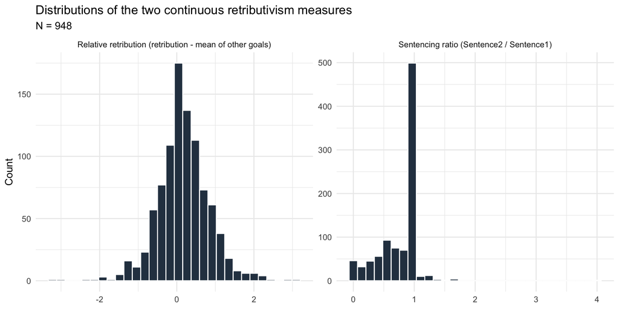

```r
# === FIGURE: DISTRIBUTIONS OF THE TWO CONTINUOUS MEASURES ===
# WHAT THIS CHUNK DOES: draws histograms of relative retribution and the
# sentencing ratio and writes output/figures/retributivism_distributions.png. A
# histogram sorts the scores into equal-width bins and draws one bar per bin, so
# the height of a bar is how many people landed in that range.
#
# WHY IT IS HERE. This is the visual justification for the split rule set in
# Phase 5.4. The relative subscale is roughly continuous and symmetric, so a
# median split on it -- cutting the sample in two at the middle score -- is
# unremarkable. The sentencing ratio is not: it has a large spike at exactly
# 1.00 -- the participants who did not reduce the sentence at all once the
# forward-looking reasons were removed, which is both the most retributive
# response and the median. That means the middle score is a stack of tied
# people, and the rule for which side the ties go to decides the split. Seeing
# that spike is what makes the tie rule, and the preference for the continuous
# version, legible. Without the picture, the tie rule reads as fussiness.
#
# One long column of values plus a second column naming which measure each value
# came from. That is the shape ggplot2 needs to draw one panel per measure. The
# rep() counts must match the stacks above them exactly, which is why the
# sentencing ratio contributes sum(!is.na(...)) values and rows, and the
# relative subscale contributes its full length. Mismatched counts would label
# one measure's values with the other measure's name.
hist_df <- data.frame(
  value = c(d$retribution_rel, d$sentence_ratio[!is.na(d$sentence_ratio)]),
  measure = c(rep("Relative retribution (retribution - mean of other goals)",
                  length(d$retribution_rel)),
              rep("Sentencing ratio (Sentence2 / Sentence1)",
                  sum(!is.na(d$sentence_ratio)))))
# NA is R's marker for a missing value, and a missing value has no bar to draw.
# Those rows are filtered out before plotting, rather than left for ggplot2 to
# complain about.
p_dist <- ggplot2::ggplot(hist_df[!is.na(hist_df$value), ],
                          ggplot2::aes(x = value)) +
  ggplot2::geom_histogram(bins = 30, fill = "#2c3e50", colour = "white") +
  # facet_wrap draws one small panel per measure. scales = "free" on both axes:
  # the two measures live on entirely different ranges, and a shared scale would
  # flatten one of them into a single bar.
  ggplot2::facet_wrap(~ measure, scales = "free") +
  ggplot2::labs(title = "Distributions of the two continuous retributivism measures",
                subtitle = sprintf("N = %d", nrow(d)), x = NULL, y = "Count") +
  ggplot2::theme_minimal(base_size = 12)
print(p_dist)
```

```r
# Save the identical figure to disk at 300 dots per inch. The manuscript then
# prints the same picture the report shows, rather than a screenshot of it. The
# path goes into FIGURES so Phase 10 can list every figure this document wrote.
fig_path <- file.path(OUT_FIGURES, "retributivism_distributions.png")
ggplot2::ggsave(fig_path, p_dist, width = 10, height = 5, dpi = 300)
FIGURES <- c(FIGURES, fig_path)
```

## 9.16 The six features of retributive theory, results regrouped

Nothing in this section is a new result. Every mean, effect size and interval below was computed in 9.3 and has already been reported in 9.4 to 9.8. The same rows are printed a second time, sorted under the six features of retributive theory. Each heading carries a plain statement of what the theory claims and of what a higher score on that feature’s measures means.

Grouping measures under features is an interpretive layer and is not pre-registered. The contrasts it indexes are registered under prereg 5.3, and none of them is displaced, recomputed or reworded here. Read this section as a table of contents for results already reported, never as a fresh set of tests.

```r
# === THE SIX FEATURES, RESULTS REGROUPED ===
# WHAT THIS CHUNK DOES: takes the contrast results computed in 9.3 and prints
# them again under six headings, one per feature of retributive theory.
# Produces the table `features_F1_to_F6`.
# PREREG: not part of the pre-registration. Nothing is registered at the level
#         of a feature and nothing is tested at that level here. The contrasts
#         reprinted below are the registered ones from prereg 5.3, reported in
#         full in 9.4 to 9.8; this section reorders them and nothing else.
# CONSUMES: contrasts_rank and contrast_spec (9.3); alpha_table_out (4.10) and
#           h6b (8.3b), both read only to quote numbers computed there.
#
# NO REPORTED NUMBER IS COMPUTED HERE. Every group mean, standard deviation,
# Cohen's d and confidence interval below was produced by run_contrast_set() in
# 9.3 and is reprinted without alteration. Cohen's d is the gap between two
# group means expressed in standard deviations, so it does not depend on the
# units of the measure. The confidence interval beside it is the range of true
# values this sample cannot rule out. The chunk performs exactly one
# computation, the verification re-run at the foot of it, and that re-run
# reports nothing but a single line saying whether the reprint is faithful. A
# reader must not take this section for a second set of analyses: it is the
# same analyses, in a different order on the page. Counting a result here and
# again in 9.4 to 9.8 would double-count the same evidence.
#
# WHAT THIS SECTION IS. An index. The document runs in dependency order --
# items before composites, composites before groupings, groupings before
# contrasts. The six features cut across that order, each drawing on contrasts
# registered under three or four different hypotheses. A reader who wants to
# know what the data say about one feature would otherwise have to gather its
# rows out of every section that reports those hypotheses. This chunk collects
# the rows belonging to each feature under one heading and states, in words,
# which way the registered one-sided test points.
#
# WHY results='asis'. This chunk writes its own headings and tables straight
# into the document rather than printing them inside the usual grey output box,
# which is what that chunk option does. Two practical consequences. Every cat()
# below has to end in a blank line, because the text it emits is read as
# document text and two paragraphs run together without one. And every table
# has to be print()ed explicitly, because the tables are produced inside a for
# loop, where R does not auto-print: a bare show_table() call there would build
# a table and throw it away.

# A hard stop rather than a quietly empty section: if the spec has no feature
# column there is nothing to group by, and an empty section that looks fine on
# the page is worse than a failure that does not. A silent gap gets published;
# an error gets fixed.
if (!"feature" %in% names(contrast_spec)) {
  stop("contrast_spec has no `feature` column, so 9.16 cannot group anything. ",
       "See the column list in 9.3.")
}

# The table below defines the six features. Each column has a job.
#
# `claim` states each feature as the manuscript states it, and `higher_means`
# says what a higher score on that feature's measures amounts to. Neither is a
# finding: the first is the position being tested, the second is what the
# direction of the registered one-sided test comes to once it is put in words.
#
# `expected_outcomes` is not part of the manuscript's framing. It is the
# analytic decision about which measured variable speaks to which claim. That
# decision is made here and recorded here, so that a reader can argue with it.
# It is also checked against the spec at the foot of this chunk. That check is
# what makes a measure named for a feature but never tested under it get
# reported rather than go quietly absent. A name may be added to it before the
# measure exists: the coverage check reports such a name as NOT FOUND rather
# than letting the section imply the measure was computed.
#
# `caution` prints under the table, before the count, wherever the rows under a
# feature are not as independent of one another as a count of rows implies.
# Counting overlapping rows as separate findings would inflate the evidence.
# `alpha_watch` names a composite as the reliability table in 4.10 labels it,
# and triggers a reliability note when that composite's alpha is low.
# `where_else` is used only when the contrast set carries no row for a feature.
# F2 is that case: proportionality is measured in this study, but not as a
# difference between two groups, so its heading carries a pointer and no table.
#
# Adding a seventh feature is one row here plus that code in the feature column
# of the spec in 9.3, and nothing else in this document changes.
feature_defs <- tibble::tribble(
  ~feature, ~feature_name, ~claim, ~higher_means, ~expected_outcomes,
  ~caution, ~alpha_watch, ~where_else,

  "F1", "DIGNITY",
  paste("Retribution is a moral, deontological theory grounded in respect for",
        "the DIGNITY of the person being punished."),
  paste("If that holds, retributivists should be no more willing than anyone",
        "else to degrade or cast out the person they punish. A higher score on",
        "the rows below means MORE endorsement of degrading treatment and MORE",
        "willingness to exclude the offender from society, so a row on which",
        "the retributivists score higher counts AGAINST the claim, not for",
        "it."),
  "degradation, exclusion",
  NA,
  "degradation",
  NA,

  "F2", "PROPORTIONALITY",
  "Central to retribution is the principle of PROPORTIONALITY.",
  paste("If that holds, punishment should fit the offense, neither exceeding",
        "it nor falling short of it. Proportionality is measured in this study",
        "but never as a difference between two groups, so no contrast row and",
        "no count of measures appears under this heading."),
  "proportionality_principle",
  NA,
  NA,
  paste("8.1 (is strict proportionality endorsed at all), 8.2 (punishment",
        "beyond the offense against punishment below it) and 8.3b (what",
        "desert actually tracks). Those are one-sample, paired and",
        "correlational tests, none of which is a difference between two",
        "groups, so none belongs in the contrast set this section regroups.",
        "In 8.3b the row that carries the evidence is `deserved`,",
        "the four purpose items, against `proportionality_principle`, read",
        "against `deserved` versus `severity_index` beneath it. The row a",
        "reader is likeliest to mistake for the evidence is `just_deserts`",
        "against `proportionality_principle`, and it is PART-WHOLE:",
        "`just_deserts` is built from the proportionality item, so that row",
        "correlates the item with itself. 8.3b prints it labelled CONTAMINATED",
        "for exactly that reason and it is not evidence of anything."),
```

```r
  "F3", "LENIENCY",
  paste("Proportionality exists to harness the state's propensity to",
        "over-punish, so retributive punishment should be MORE LENIENT than",
        "consequentialist punishment."),
  paste("If that holds, retributivists should be no more punitive than anyone",
        "else, and by the letter of the claim less punitive. A higher score on",
        "the rows below means a LONGER sentence, HARSHER prison conditions and",
        "a MORE punitive scale score, so a row on which the retributivists",
        "score higher counts AGAINST the claim, not for it."),
  "punitiveness, punitiveness_full, Sentence1_z, harsh",
  paste("Four rows, three distinct constructs. `punitiveness_full` is",
        "zmean(`punitiveness`, `Sentence1_z`), built in 4.2 out of the items",
        "of two of the other three rows, so it is not independent evidence of",
        "anything those two do not already show, and the four rows must not be",
        "counted as four separate findings. 9.8 treats the self-report scale",
        "as the primary test of H21; this heading keeps that order."),
  NA,
  NA,

  "F4", "HARD TREATMENT",
  paste("HARD TREATMENT is required by retribution, but as a necessary feature",
        "rather than a goal to be pursued."),
  paste("If that holds, retributivists should accept the hardship that",
        "deserved punishment involves without seeking more of it. A higher",
        "score on the rows below means MORE endorsement of inflicting",
        "suffering and MORE tolerance of violence in prison, which is hard",
        "treatment pursued rather than accepted, so a row on which the",
        "retributivists score higher counts AGAINST the claim, not for it."),
  "suffering, prisonviol",
  NA,
  NA,
  NA,

  "F5", "CERTAINTY OF GUILT",
  paste("With its focus on just desert, retribution is deeply committed to the",
        "CERTAINTY OF GUILT."),
  paste("If that holds, retributivists should be the last to relax the",
        "safeguards that establish guilt. A higher score on the rows below",
        "means MORE willingness to set due process aside and MORE willingness",
        "to convict on evidence short of certainty, so a row on which the",
        "retributivists score higher counts AGAINST the claim, not for it."),
  "dueprocess, uncertain",
  NA,
  "due process (permissive)",
  NA,

  "F6", "TRANSCENDING REVENGE",
  "Retribution TRANSCENDS negative emotions and the desire for REVENGE.",
  paste("If that holds, retributivists should be no more vengeful or hostile",
        "toward the offender than anyone else. A higher score on the rows",
        "below means MORE desire for revenge, MORE hatred and MORE anger, so a",
        "row on which the retributivists score higher counts AGAINST the",
        "claim, not for it."),
  "revenge, hatred, anger",
  NA,
  NA,
  NA
)

# A feature code used in the spec but absent from the table above would be
# invisible on the page and present in the export. The loop below iterates
# `feature_defs`, so such a row would never print under any heading. But
# `features_tab` and output/tables/features_F1_to_F6.csv would still carry it.
# The knitted document and the CSV would then disagree, which is the one thing
# this section must not do. Stop instead of printing a partial index.
undefined_codes <- setdiff(
  unique(contrast_spec$feature[!is.na(contrast_spec$feature)]),
  feature_defs$feature)
if (length(undefined_codes) > 0) {
  stop("contrast_spec uses feature code(s) that feature_defs does not define: ",
       paste(undefined_codes, collapse = ", "),
       ". Add a row to feature_defs in 9.16, or clear the code in 9.3.")
}

#' Look up the Cronbach's alpha of one composite. Cronbach's alpha measures
#' internal consistency: how far a set of items behaves like repeated
#' measurements of one single thing. This function READS that number out of the
#' reliability table built in 4.10 instead of working it out again. That way the
#' figure quoted below and the figure in the published reliability table can
#' never drift apart from each other.
#'
#' ARGUMENTS
#'   label  the composite's name, spelled exactly as the reliability table
#'          spells it. The lookup is an exact text match, so a near miss finds
#'          nothing.
#' RETURNS  one number, or NA (R's marker for a missing value) when the table is
#'          absent or does not carry that label.
#' USED BY  the reliability note printed under a feature's table, further down
#'          in this chunk, and nowhere else.
#'
#' WHY IT RETURNS NA INSTEAD OF STOPPING. The reliability note is an extra, not
#' a result. A missing figure should quietly skip the note, not bring the whole
#' document down.
#'
#' NOTE ON THE SOURCE. `alpha_table_out` is the copy 4.10 froze for export, so a
#' composite built AFTER 4.10 is not in it. That is why this returns NA rather
#' than failing, and why the note that uses it is guarded rather than assumed.
alpha_of <- function(label) {
  # No such object at all, or an object that is not a data frame (a rectangular
  # table of rows and columns): give up quietly and let the caller skip its
  # note. Reaching into a non-table would error out instead.
  if (!exists("alpha_table_out") || !is.data.frame(alpha_table_out))
    return(NA_real_)
  hit <- which(alpha_table_out$composite == label)
  # A LENGTH test, not a "did we find anything" test, and it refuses two
  # different problems at once. Zero matches means the label is not in the
  # table. Two or more means the table holds duplicate rows for one composite,
  # so there is no way to tell which alpha was meant. Quoting the wrong
  # composite's alpha is worse than quoting none, so both cases return NA.
  if (length(hit) != 1) return(NA_real_)
  alpha_table_out$alpha[hit]
}

# === HOW THE RESULTS ARE MATCHED TO THE SPEC ===
# Every result row has to be told which of the six features it belongs to, and
# that tag lives in the spec, not in the results. So the two tables have to be
# lined up against each other row by row.
#
# WARNING: THE TWO TABLES USE THE WORD "outcome" FOR TWO DIFFERENT THINGS.
# Joining them on the column that looks obvious returns nothing at all.
#   contrast_spec$outcome   is the COLUMN NAME in `d`  ("degradation")
#   contrast_spec$label     is the DISPLAY NAME        ("Degradation")
#   contrasts_rank$outcome  is the DISPLAY NAME, because welch_contrast() puts
#                           the label it was handed into a column called
#                           `outcome`
#   contrasts_rank$variable is the COLUMN NAME
# So the match below runs contrasts_rank$variable against contrast_spec$outcome
# -- column name against column name. Matching outcome to outcome would find no
# rows at all, and this section would then print six empty headings and never
# complain about it.
#
# match() returns, for each result row, the POSITION of its row in the spec, or
# NA (R's marker for a missing value) when the spec has no such row.
spec_pos <- match(contrasts_rank$variable, contrast_spec$outcome)
```

```r
# Copy two things from the spec onto each result row: the feature tag (F1 to F6,
# or NA for a row that speaks to none of the six claims) and the position that
# row holds in the spec.
#
# The position is carried across so that the sort below can name spec order
# outright as its second key, rather than leaning on the order the rows happen
# to arrive in. That holds the outcomes inside each feature in the order the
# spec sets them out, rather than alphabetically or by effect size. A table
# sorted by effect size quietly invites a reader to treat the biggest number as
# the headline finding, which is exactly the reading this section is built to
# prevent.
feat_rows <- contrasts_rank
feat_rows$feature    <- contrast_spec$feature[spec_pos]
feat_rows$spec_order <- spec_pos
# The feature's full name ("DIGNITY", not just the code "F1"), so the exported
# CSV can be read on its own without this document open beside it. A row with no
# feature keeps NA here, which is the honest answer. A row that HAS a feature is
# guaranteed to find a name, because the stop() above already refused to run at
# all if the spec used a feature code that `feature_defs` does not define.
feat_rows$feature_name <-
  feature_defs$feature_name[match(feat_rows$feature, feature_defs$feature)]

# Keep only the rows that carry a feature, then sort them: first by feature, and
# within a feature by the spec's own order.
#
# The sort key is match() against feature_defs$feature, NOT a plain alphabetical
# sort of the codes. That gives the features in the order the manuscript sets
# them out, F1 through F6, and they would still come out in that order if a code
# were ever renamed to something that happens to sort differently. Sorting on
# the text of the code would silently reorder this whole section the day someone
# renames one.
features_tab <- feat_rows[!is.na(feat_rows$feature), ]
features_tab <- features_tab[order(match(features_tab$feature,
                                         feature_defs$feature),
                                   features_tab$spec_order), ]
# Name the columns of the EXPORTED table, in the order they should sit in it.
# This drops `spec_order`, which existed only to drive the sort above, and puts
# the feature code and its full name first. Naming the list here, rather than
# exporting whatever columns happen to be attached, is what keeps the CSV
# written in 10.1 carrying the same columns in the same order from one run to
# the next. The tables PRINTED on the page are a narrower set in a different
# order again; `show_cols`, a few lines down, is what sets those.
features_tab <- features_tab[, c("feature", "feature_name", "hypothesis",
                                 "outcome", "variable", "grouping",
                                 "n1", "n2", "M1", "SD1", "M2", "SD2",
                                 "t", "df", "p_dir", "p_two",
                                 "d", "d_lower", "d_upper", "alternative")]
# Store this under its OWN entry in TABLES, with a name that says what it is:
# the same contrasts as before, indexed by feature. Every other entry of TABLES
# is left exactly as it stands.
#
# DO NOT REUSE OR RENAME AN ENTRY HERE. Phase 10.1 turns each name in TABLES
# into a filename, so this one becomes output/tables/features_F1_to_F6.csv.
# Renaming an entry silently stops writing the file the manuscript points at,
# and the manuscript then cites a stale copy that nothing regenerates. An index
# belongs BESIDE the result tables, never in place of one.
TABLES[["features_F1_to_F6"]] <- features_tab

# The key for reading everything below, stated once at the top so that no reader
# has to work it out from column headers. Group 1 is always the retributivists
# and group 2 is always everyone else. So a positive Cohen's d always means the
# retributivists scored higher. Cohen's d is the gap between the two group
# means, measured in standard deviations.
cat("All results below come from the primary (ranking) grouping run in 9.3:",
    "**M1/SD1 are the retributivists, M2/SD2 everyone else, and a positive d",
    "means the retributivists score higher.** The same contrasts under the",
    "other three definitions of retributivism are in the grid in 9.12.\n\n")
```

All results below come from the primary (ranking) grouping run in 9.3: **M1/SD1 are the retributivists, M2/SD2 everyone else, and a positive d means the retributivists score higher.** The same contrasts under the other three definitions of retributivism are in the grid in 9.12.

```r
# The columns printed under each heading, in the order they appear: which
# hypothesis the row was registered under, what was compared, how many people
# were in each group, the two group means each with its SD, then Cohen's d with
# the two ends of its 95% confidence interval, and last `p_dir`.
#
# Three of those need a word. SD is the standard deviation, the typical distance
# of one person from the mean. The 95% confidence interval is the range of true
# effect sizes the data leave standing, at 95% confidence. `p_dir` is the
# p-value for the one-sided direction the row was registered to run in. A small
# p-value means the result is hard to put down to chance. It says nothing at all
# about how large the difference is.
#
# t and df are left out HERE for one reason only: to keep these tables narrow
# enough to read on a page. Nothing is being hidden. Both appear in the
# registered tables in 9.4 to 9.8 and in the exported CSV.
show_cols <- c("hypothesis", "outcome", "n1", "n2", "M1", "SD1", "M2", "SD2",
               "d", "d_lower", "d_upper", "p_dir")

# One pass per feature, in the order feature_defs lists them. The loop walks
# feature_defs rather than the results, and that is deliberate: it guarantees
# all six headings print, including F2, which has no contrast rows at all.
for (i in seq_len(nrow(feature_defs))) {
  # The one feature being written up on this pass, and the result rows tagged
  # with it. `rows` comes back empty for a feature with no two-group contrast,
  # which the branch further down handles rather than crashing on.
  fd   <- feature_defs[i, ]
  rows <- features_tab[features_tab$feature == fd$feature, ]

  # A level-3 heading ("###"), not just bold text, and the difference matters. A
  # real heading gets its own entry in the floating table of contents of the
  # knitted report and its own anchor, so each feature can be linked to and
  # cited on its own. The two "\n" at the end are required by results='asis':
  # without a blank line after it, the heading and the next paragraph run
  # together into one line.
  cat(sprintf("### %s %s\n\n", fd$feature, fd$feature_name))

  # THE CLAIM IS ATTRIBUTED, NOT ASSERTED, and the words "What retributive
  # theory claims" are doing real work. Printed bare, the sentence reads as this
  # document's own position. The count further down then attaches itself to that
  # position and flips meaning: "3 of 3 in the direction tested", sitting under
  # an unattributed "retribution transcends revenge", reads as three results
  # SUPPORTING transcendence. It means the opposite -- three results showing the
  # retributivists MORE vengeful than everyone else.
  cat(sprintf("**What retributive theory claims.** *%s*\n\n", fd$claim))

  # WHAT A HIGHER SCORE MEANS, IN WORDS, BEFORE ANY TABLE OR COUNT. Every row
  # under every feature here is registered as a one-sided test in the "greater"
  # direction, which means the test asks only whether the retributivists score
  # higher. But for all six features, scoring higher is what runs AGAINST the
  # claim. So the statistics and the English pull in opposite directions, and a
  # reader who does not have this sentence in hand reads every count below
  # exactly backwards. That is why it prints before the numbers, never after.
  cat(sprintf("**What a higher score means.** %s\n\n", fd$higher_means))

  if (nrow(rows) == 0) {
    # A feature with no two-group contrast anywhere in the set. This is F2,
    # proportionality, which is tested one-sample, paired and correlationally
    # instead. The heading STILL prints, with a pointer to where the evidence
    # actually is. A feature the paper discusses must not vanish from the index
    # just because its evidence takes a different statistical form: a silent gap
    # reads as "nothing to say here", which is false.
    cat("No row of the contrast set carries this feature, so there is no table",
        "here.\n\n")
    if (!is.na(fd$where_else)) {
      cat(sprintf("Where the evidence is instead: %s\n\n", fd$where_else))
    }

    # The two numbers a reader who follows the F2 pointer is going to want,
    # quoted from `h6b` exactly as 8.3b computed them and NOT recomputed here.
    # Quoting rather than recomputing means the two sections can never print
    # different values for the same correlation.
    #
    # The rows are found by the display labels 8.3b gives them, so this block is
    # tied to F2 and to that one section. If those labels ever change, the
    # reader loses these two figures and nothing else, because the pointer above
    # already names the rows in plain words.
    #
    # Both figures come from cor_row(), which uses pairwise deletion: for each
    # correlation it keeps only the people who answered BOTH measures. So the
    # two sit on the same footing as each other and as everything else in 8.3b,
    # and can be compared.
    if (fd$feature == "F2" && exists("h6b") && is.data.frame(h6b)) {
      i_prop <- which(h6b$x == "Desert (purpose items)" &
                        grepl("Proportionality principle", h6b$y, fixed = TRUE))
      i_sev  <- which(h6b$x == "Desert (purpose items)" &
                        grepl("Severity index", h6b$y, fixed = TRUE))
      i_con  <- which(grepl("part-whole", h6b$y, fixed = TRUE))
      # Both rows must be found exactly once each before either is quoted. If a
      # label has drifted, the sentence simply does not print, which is better
      # than printing a number pulled from whichever row happened to match.
      if (length(i_prop) == 1 && length(i_sev) == 1) {
        cat(sprintf(paste("From 8.3b: desert against the proportionality",
                          "principle, r = %+.3f; desert against the severity",
                          "index, r = %+.3f.\n\n"),
                    h6b$r[i_prop], h6b$r[i_sev]))
      }
      if (length(i_con) == 1) {
        # The part-whole correlation is the largest of the three, and that is
        # precisely why 8.3b prints it disarmed. Part-whole means the two sides
        # of the correlation share an item: `just_deserts` is built FROM the
        # proportionality item, so this row correlates that item partly with
        # itself and is guaranteed to look strong. IT IS NOT EVIDENCE OF
        # ANYTHING.
        #
        # Whether it really is the largest is CHECKED against the numbers rather
        # than asserted, so the sentence cannot outlive the ordering it
        # describes. Note that the comparison is on abs(), the size of each
        # correlation ignoring its sign, because a strongly negative value is
        # just as large as a strongly positive one. If the ordering ever
        # changes, the shorter wording prints instead of a claim that has
        # quietly become false.
        bigger <- length(i_prop) == 1 && length(i_sev) == 1 &&
          abs(h6b$r[i_con]) > max(abs(h6b$r[i_prop]), abs(h6b$r[i_sev]))
        cat(sprintf(paste("The part-whole row in that same table, printed",
                          "there to be disarmed rather than used, is",
                          "r = %+.3f.%s\n\n"),
                    h6b$r[i_con],
                    if (bigger)
                      " It is the largest of the three and it is not evidence."
                    else " It is not evidence."))
      }
    }
    # Nothing further to print for a feature with no rows, so move to the next
    # feature rather than falling through into the table-building code below.
    next
  }
```

```r
  # The caption for this feature's table. Every table in this document carries
  # one, so that a table lifted out of the report still says what it shows and
  # which grouping it came from. The "%%" is not a typo: inside sprintf(), a
  # literal percent sign has to be written twice.
  cap <- sprintf(paste("%s %s: retributivists versus everyone else, Welch t",
                       "with Cohen's d and its 95%% CI, under the primary",
                       "ranking grouping"),
                 fd$feature, fd$feature_name)
  # print() is REQUIRED here, not decoration. This sits inside a for loop, where
  # R does not print a result automatically, and show_table() returns a kable
  # object (knitr's formatted-table object) rather than printing one itself. A
  # bare show_table() call here would build the table and throw it away, leaving
  # a heading with nothing under it.
  print(show_table(rows[, show_cols], cap))
  cat("\n")

  # A caution, where one is recorded. It says so when the rows under a feature
  # are not as independent of one another as a count of rows makes them look,
  # because they are built from overlapping items. It prints ABOVE the count,
  # not below it, so the reader holds the warning before reading the number it
  # qualifies.
  if (!is.na(fd$caution)) cat(sprintf("%s\n\n", fd$caution))

  # Reliability, but only where it is weak enough to matter. Everywhere else in
  # this document a reliability coefficient is printed beside every composite,
  # and promoting one composite to a named share of the evidence for a feature
  # must not lose that.
  #
  # The note prints ONLY when the alpha read back from 4.10 falls below .60, the
  # same floor 4.10 itself uses, so it is a statement about the number that came
  # back rather than a fixed claim about a particular scale. If alpha_of()
  # returned NA (R's marker for a missing value), the condition is false and no
  # note prints at all.
  if (!is.na(fd$alpha_watch)) {
    a_val <- alpha_of(fd$alpha_watch)
    if (!is.na(a_val) && a_val < .60) {
      cat(sprintf(paste("Reliability: `%s`, one of the %d rows above, has",
                        "Cronbach's alpha = %.2f. Cronbach's alpha measures",
                        "internal consistency, that is, how far a set of items",
                        "behaves like repeated measurements of one thing, and",
                        "4.10 flags anything below .60 as low.\n\n"),
                  fd$alpha_watch, nrow(rows), a_val))
    }
  }

  # A NEUTRAL COUNT, NOT A VERDICT. It reports which way the differences run and
  # how many clear the conventional p < .05 threshold, and stops there. What
  # that adds up to for the feature is an argument, and arguments belong in the
  # manuscript, written by the authors, not in text a script generated.
  #
  # The ifelse() scores each row in ITS OWN registered direction: a row
  # registered "less" counts when d is negative, a row registered "greater"
  # counts when d is positive. Every row here is currently "greater", but if a
  # "less" row is tagged with a feature later, this counts it the right way
  # round instead of backwards. na.rm = TRUE ignores NA, which is what a row
  # holds when its contrast could not be run at all.
  #
  # NOTE ON WHAT THAT DOES TO THE SENTENCE PRINTED BELOW. A row that could not
  # be run is dropped from this count and from n_sig, but it is still inside
  # nrow(rows), which is the total the sentence quotes. Such a row would
  # therefore read as one that simply did not run in the tested direction.
  # Whether that is wanted, or whether an unrunnable row should come out of the
  # total as well, is for the authors to settle.
  n_dir <- sum(ifelse(rows$alternative == "less", rows$d < 0, rows$d > 0),
               na.rm = TRUE)
  # How many reach the conventional one-sided p < .05. It counts p_dir, the
  # DIRECTIONAL p-value, so the count matches the test that was registered
  # rather than an undirected version of it.
  n_sig <- sum(rows$p_dir < .05, na.rm = TRUE)
  # The plain-English sentence below names "higher" as the tested direction.
  # That is true only while every row under this feature is registered
  # "greater". Checked rather than assumed: if a "less" row is ever tagged with
  # this feature, the direction-neutral wording prints instead of a sentence
  # that would be flatly wrong about what was tested.
  all_greater <- all(rows$alternative == "greater")
  # The pointer back to the caution is added only where there IS a caution above
  # to read. Otherwise it would send the reader hunting for a note that is not
  # on the page.
  caveat <- if (!is.na(fd$caution))
    " Read that count against the note above the table." else ""
  if (all_greater) {
    # Every row was tested in the "higher" direction, so the sentence can name
    # that direction and say plainly that it is the direction running against
    # the claim printed above.
    cat(sprintf(paste("Of the %d contrast rows under this feature, %d run with",
                      "the retributivists scoring HIGHER and %d reach",
                      "one-sided p < .05 in that direction. Higher is the",
                      "direction of the registered one-sided test, and it is",
                      "the direction that runs against the claim above.%s\n\n"),
                nrow(rows), n_dir, n_sig, caveat))
  } else {
    # A mixed set. Naming a single direction would be wrong, so the wording
    # stays direction-neutral and sends the reader to the spec in 9.3 for which
    # way each individual row was registered to run.
    cat(sprintf(paste("Of the %d contrast rows under this feature, %d run in",
                      "the direction of their own registered one-sided test",
                      "and %d reach one-sided p < .05 in that direction. The",
                      "rows here are not all registered in the same direction;",
                      "which way each points is in the spec in 9.3 and in the",
                      "exported CSV.%s\n\n"),
                nrow(rows), n_dir, n_sig, caveat))
  }
}
```

### F1 DIGNITY

**What retributive theory claims.** *Retribution is a moral, deontological theory grounded in respect for the DIGNITY of the person being punished.*

**What a higher score means.** If that holds, retributivists should be no more willing than anyone else to degrade or cast out the person they punish. A higher score on the rows below means MORE endorsement of degrading treatment and MORE willingness to exclude the offender from society, so a row on which the retributivists score higher counts AGAINST the claim, not for it.

F1 DIGNITY: retributivists versus everyone else, Welch t with Cohen’s d and its 95% CI, under the primary ranking grouping

| hypothesis | outcome | n1 | n2 | M1 | SD1 | M2 | SD2 | d | d_lower | d_upper | p_dir |
| --- | --- | --- | --- | --- | --- | --- | --- | --- | --- | --- | --- |
| H13 | Degradation | 371 | 577 | 3.887 | 1.330 | 3.352 | 1.130 | 0.434 | 0.299 | 0.568 | 0 |
| H13 | Social exclusion | 371 | 577 | 4.937 | 1.328 | 4.215 | 1.402 | 0.529 | 0.397 | 0.661 | 0 |

Reliability: `degradation`, one of the 2 rows above, has Cronbach’s alpha = 0.54. Cronbach’s alpha measures internal consistency, that is, how far a set of items behaves like repeated measurements of one thing, and 4.10 flags anything below .60 as low.

Of the 2 contrast rows under this feature, 2 run with the retributivists scoring HIGHER and 2 reach one-sided p < .05 in that direction. Higher is the direction of the registered one-sided test, and it is the direction that runs against the claim above.

### F2 PROPORTIONALITY

**What retributive theory claims.** *Central to retribution is the principle of PROPORTIONALITY.*

**What a higher score means.** If that holds, punishment should fit the offense, neither exceeding it nor falling short of it. Proportionality is measured in this study but never as a difference between two groups, so no contrast row and no count of measures appears under this heading.

No row of the contrast set carries this feature, so there is no table here.

Where the evidence is instead: 8.1 (is strict proportionality endorsed at all), 8.2 (punishment beyond the offense against punishment below it) and 8.3b (what desert actually tracks). Those are one-sample, paired and correlational tests, none of which is a difference between two groups, so none belongs in the contrast set this section regroups. In 8.3b the row that carries the evidence is `deserved`, the four purpose items, against `proportionality_principle`, read against `deserved` versus `severity_index` beneath it. The row a reader is likeliest to mistake for the evidence is `just_deserts` against `proportionality_principle`, and it is PART-WHOLE: `just_deserts` is built from the proportionality item, so that row correlates the item with itself. 8.3b prints it labelled CONTAMINATED for exactly that reason and it is not evidence of anything.

From 8.3b: desert against the proportionality principle, r = +0.195; desert against the severity index, r = +0.476.

The part-whole row in that same table, printed there to be disarmed rather than used, is r = +0.555. It is the largest of the three and it is not evidence.

### F3 LENIENCY

**What retributive theory claims.** *Proportionality exists to harness the state’s propensity to over-punish, so retributive punishment should be MORE LENIENT than consequentialist punishment.*

**What a higher score means.** If that holds, retributivists should be no more punitive than anyone else, and by the letter of the claim less punitive. A higher score on the rows below means a LONGER sentence, HARSHER prison conditions and a MORE punitive scale score, so a row on which the retributivists score higher counts AGAINST the claim, not for it.

F3 LENIENCY: retributivists versus everyone else, Welch t with Cohen’s d and its 95% CI, under the primary ranking grouping

| hypothesis | outcome | n1 | n2 | M1 | SD1 | M2 | SD2 | d | d_lower | d_upper | p_dir |
| --- | --- | --- | --- | --- | --- | --- | --- | --- | --- | --- | --- |
| H13 | Harsh prison conditions | 371 | 577 | 3.665 | 1.506 | 2.816 | 1.354 | 0.593 | 0.457 | 0.728 | 0 |
| H14 | Sentence 1 (z within vignette) | 371 | 577 | 0.296 | 0.874 | -0.190 | 1.028 | 0.510 | 0.379 | 0.640 | 0 |
| H21 | Punitiveness (self-report, 8 items) | 371 | 577 | 4.640 | 1.084 | 3.720 | 1.268 | 0.780 | 0.646 | 0.913 | 0 |
| H21 | Punitiveness (full index, + sentence) | 371 | 577 | 0.367 | 0.722 | -0.236 | 0.855 | 0.762 | 0.629 | 0.895 | 0 |

Four rows, three distinct constructs. `punitiveness_full` is zmean(`punitiveness`, `Sentence1_z`), built in 4.2 out of the items of two of the other three rows, so it is not independent evidence of anything those two do not already show, and the four rows must not be counted as four separate findings. 9.8 treats the self-report scale as the primary test of H21; this heading keeps that order.

Of the 4 contrast rows under this feature, 4 run with the retributivists scoring HIGHER and 4 reach one-sided p < .05 in that direction. Higher is the direction of the registered one-sided test, and it is the direction that runs against the claim above. Read that count against the note above the table.

### F4 HARD TREATMENT

**What retributive theory claims.** *HARD TREATMENT is required by retribution, but as a necessary feature rather than a goal to be pursued.*

**What a higher score means.** If that holds, retributivists should accept the hardship that deserved punishment involves without seeking more of it. A higher score on the rows below means MORE endorsement of inflicting suffering and MORE tolerance of violence in prison, which is hard treatment pursued rather than accepted, so a row on which the retributivists score higher counts AGAINST the claim, not for it.

F4 HARD TREATMENT: retributivists versus everyone else, Welch t with Cohen’s d and its 95% CI, under the primary ranking grouping

| hypothesis | outcome | n1 | n2 | M1 | SD1 | M2 | SD2 | d | d_lower | d_upper | p_dir |
| --- | --- | --- | --- | --- | --- | --- | --- | --- | --- | --- | --- |
| H13 | Infliction of suffering | 371 | 577 | 4.137 | 1.620 | 3.312 | 1.582 | 0.516 | 0.382 | 0.649 | 0 |
| H13 | Tolerance of prison violence | 371 | 577 | 3.280 | 1.408 | 2.701 | 1.275 | 0.431 | 0.297 | 0.565 | 0 |

Of the 2 contrast rows under this feature, 2 run with the retributivists scoring HIGHER and 2 reach one-sided p < .05 in that direction. Higher is the direction of the registered one-sided test, and it is the direction that runs against the claim above.

### F5 CERTAINTY OF GUILT

**What retributive theory claims.** *With its focus on just desert, retribution is deeply committed to the CERTAINTY OF GUILT.*

**What a higher score means.** If that holds, retributivists should be the last to relax the safeguards that establish guilt. A higher score on the rows below means MORE willingness to set due process aside and MORE willingness to convict on evidence short of certainty, so a row on which the retributivists score higher counts AGAINST the claim, not for it.

F5 CERTAINTY OF GUILT: retributivists versus everyone else, Welch t with Cohen’s d and its 95% CI, under the primary ranking grouping

| hypothesis | outcome | n1 | n2 | M1 | SD1 | M2 | SD2 | d | d_lower | d_upper | p_dir |
| --- | --- | --- | --- | --- | --- | --- | --- | --- | --- | --- | --- |
| H20 | Due-process permissiveness | 371 | 577 | 3.285 | 1.155 | 2.789 | 1.158 | 0.429 | 0.296 | 0.561 | 0 |
| H20 | Convicting on uncertain evidence | 371 | 577 | 3.155 | 1.065 | 2.806 | 1.104 | 0.321 | 0.190 | 0.452 | 0 |

Reliability: `due process (permissive)`, one of the 2 rows above, has Cronbach’s alpha = 0.56. Cronbach’s alpha measures internal consistency, that is, how far a set of items behaves like repeated measurements of one thing, and 4.10 flags anything below .60 as low.

Of the 2 contrast rows under this feature, 2 run with the retributivists scoring HIGHER and 2 reach one-sided p < .05 in that direction. Higher is the direction of the registered one-sided test, and it is the direction that runs against the claim above.

### F6 TRANSCENDING REVENGE

**What retributive theory claims.** *Retribution TRANSCENDS negative emotions and the desire for REVENGE.*

**What a higher score means.** If that holds, retributivists should be no more vengeful or hostile toward the offender than anyone else. A higher score on the rows below means MORE desire for revenge, MORE hatred and MORE anger, so a row on which the retributivists score higher counts AGAINST the claim, not for it.

F6 TRANSCENDING REVENGE: retributivists versus everyone else, Welch t with Cohen’s d and its 95% CI, under the primary ranking grouping

| hypothesis | outcome | n1 | n2 | M1 | SD1 | M2 | SD2 | d | d_lower | d_upper | p_dir |
| --- | --- | --- | --- | --- | --- | --- | --- | --- | --- | --- | --- |
| H13 | Hatred | 371 | 577 | 4.473 | 1.382 | 3.676 | 1.433 | 0.566 | 0.433 | 0.698 | 0 |
| H13 | Revenge | 371 | 577 | 4.596 | 1.301 | 3.854 | 1.369 | 0.555 | 0.423 | 0.688 | 0 |
| H13 | Anger | 371 | 577 | 4.821 | 1.574 | 4.207 | 1.603 | 0.386 | 0.255 | 0.518 | 0 |

Of the 3 contrast rows under this feature, 3 run with the retributivists scoring HIGHER and 3 reach one-sided p < .05 in that direction. Higher is the direction of the registered one-sided test, and it is the direction that runs against the claim above.

```r
# === COVERAGE: WHAT IS NOT IN THE SIX FEATURES ===
# An index is only honest if it says what it leaves out. There are two ways a
# measure can be missing from the six sections above, and BOTH are printed here
# rather than left for a reader to discover by noticing a gap.
cat("### Coverage of the contrast set\n\n")
```

### Coverage of the contrast set

```r
# (1) Contrast rows that belong to none of the six features. They are still
# tested, still registered and still reported in full in 9.4 to 9.8 and 9.15.
# They simply do not speak to one of the six claims. is.na() picks them out,
# because a row with no feature carries NA (R's marker for a missing value) in
# that column.
# Listing them keeps this section honest about being an INDEX rather than the
# whole of Phase 9.
unmapped <- feat_rows[is.na(feat_rows$feature), c("hypothesis", "outcome")]
cat(sprintf(paste("%d of the %d contrasts carry a feature. The remaining %d",
                  "are reported in 9.4 to 9.8 and 9.15 as usual, and are",
                  "listed here only so that nothing appears to have gone",
                  "missing.\n\n"),
            nrow(features_tab), nrow(feat_rows), nrow(unmapped)))
```

13 of the 27 contrasts carry a feature. The remaining 14 are reported in 9.4 to 9.8 and 9.15 as usual, and are listed here only so that nothing appears to have gone missing.

```r
print(show_table(unmapped,
                 "Contrasts that belong to none of the six features"))
```

Contrasts that belong to none of the six features

| hypothesis | outcome |
| --- | --- |
| H13 | Hostile-aggression cluster (z) |
| H13 | Perceived crime rates |
| H13 | Fear of crime |
| H15 | Shark: how painful the death should be |
| H16 | Essentialism about criminals |
| H17 | Crime is a choice |
| H18 | Leaning toward the prosecution |
| H19 | Rejecting society’s responsibility |
| E1 | Right-Wing Authoritarianism |
| E1 | Social Dominance Orientation |
| E1 | Violence proneness |
| E1 | Racial resentment |
| E1 | Cognitive reflection (0-3) |
| E1 | Cognitive reflection (0-2, lily pad dropped) |

```r
cat("\n")
```

```r
# (2) The mirror-image problem: measures NAMED as belonging to a feature that
# the six sections above do not actually print under that feature. Each feature
# records its expected measures as one string of comma-separated names, so
# splitting on a comma plus any spaces that follow it turns that record into one
# row per measure.
#
# THREE OUTCOMES, KEPT DISTINCT. Simply asking whether the measure appears in
# contrast_spec$outcome would not be enough. That single test cannot tell "named
# but tested elsewhere" from "named but never computed", and it cannot see a
# measure filed under the WRONG feature at all:
#   MISMATCH   the spec has the row but tags it with a different feature, or
#              with none, so the mapping recorded here and the mapping the page
#              actually uses have come apart.
#   elsewhere  the measure exists in `d` but is not a two-group contrast. This
#              is the F2 case and it is expected; the pointer under the heading
#              says where it is tested instead.
#   NOT FOUND  no such column in `d`. A name has been recorded for a measure
#              this document does not build. Printed rather than fatal, so that
#              a measure named ahead of being built stays visible instead of
#              being silently dropped, and is never described as though it had
#              been tested.
exp_list <- strsplit(feature_defs$expected_outcomes, ",[[:space:]]*")
# One row per named measure. rep() repeats each feature code as many times as
# that feature named measures, and unlist() flattens the split-up pieces back
# into a single vector (a simple run of values), so the two line up.
expected <- data.frame(
  feature = rep(feature_defs$feature, lengths(exp_list)),
  measure = unlist(exp_list),
  stringsAsFactors = FALSE)
# Where each named measure sits in the spec, and which feature the spec tags it
# with. NA in either place is informative, and the status labels below turn each
# combination into words.
spec_i <- match(expected$measure, contrast_spec$outcome)
expected$spec_feature <- contrast_spec$feature[spec_i]
# TRUE only where the spec both HAS the row and tags it with the same feature
# that named it. Two details are load-bearing.
#
# First, this is computed as a logical (a plain TRUE/FALSE vector) BEFORE the
# status strings are built. The strings are then only labels for the reader, not
# the thing the check depends on, so rewording a message can never change which
# rows count as matched.
#
# Second, a spec row tagged NA returns NA from the comparison rather than FALSE,
# and NA would not behave as a failure. That is what the second is.na() catches,
# and it is why "or none" belongs in the mismatch message.
matched <- !is.na(spec_i) & !is.na(expected$spec_feature) &
  expected$spec_feature == expected$feature
expected$status <- ifelse(
  matched,
  "tested as a contrast under this feature",
  ifelse(is.na(spec_i),
         ifelse(expected$measure %in% names(d),
                "measured, but not a two-group contrast",
                "NOT FOUND: no such column in the data"),
         "MISMATCH: the spec tags this row with a different feature, or none"))
if (all(matched)) {
  # The clean case. It is stated out loud rather than left as silence, because
  # silence here is indistinguishable from the check never having run.
  cat("Every measure named for a feature is tested as a group contrast under",
      "that same feature.\n\n")
} else {
  # Something did not line up. The offending rows are printed with their status,
  # so the reader can see which of the three cases each one is instead of being
  # told only that a mismatch exists somewhere.
  cat(sprintf(paste("%d measure(s) named for a feature are not tested as a",
                    "group contrast under that feature. The status column says",
                    "which of the three cases each one is.\n\n"),
              sum(!matched)))
  print(show_table(expected[!matched, c("feature", "measure", "status")],
                   "Measures named for a feature but not a contrast under it"))
  cat("\n")
}
```

1 measure(s) named for a feature are not tested as a group contrast under that feature. The status column says which of the three cases each one is.

Measures named for a feature but not a contrast under it

| feature | measure | status |
| --- | --- | --- |
| F2 | proportionality_principle | measured, but not a two-group contrast |

```r
# === THE REPRINT CHECK ===
# This whole section rests on one claim: that it COPIES numbers rather than
# producing them. This is where that claim is tested.
#
# CIRCULARITY, AND WHY THE OBVIOUS CHECK IS NOT A CHECK. Comparing a copy with
# the object it was copied FROM cannot fail, and must never be mistaken for
# verification. `features_tab` is a subset of `contrasts_rank`, so looking its
# rows back up in `contrasts_rank` compares the object with itself. It would
# report a perfect match even if every single value in `contrasts_rank` had been
# overwritten somewhere between 9.3 and here.
#
# So this recomputes from scratch instead. welch_contrast() is called again on
# `d` for each row that carries a feature, using the same outcome column, the
# same grouping and the same one-sided direction the spec gave it back in 9.3.
# A Welch t-test compares two group means. It does not assume the two groups
# have the same variance, that is, the same amount of spread around their own
# mean. The fresh means, SDs and effect sizes are then compared against the ones
# reprinted above.
#
# This is the ONLY computation in the chunk. Its output is a single line, and no
# number it produces is reported anywhere. One Welch t-test per tagged row on
# the full sample costs nothing; a section that promises a check and runs none
# costs a great deal.
#
# all.equal() rather than == because these are floating-point numbers, the
# approximate decimals a computer stores. Two such values can be identical for
# every practical purpose and still differ in the very last bit, which == would
# call a mismatch. all.equal() tolerates a difference that small and nothing
# larger. isTRUE() is wrapped around it because all.equal() reports a difference
# as a description in words, not as FALSE.
if (nrow(features_tab) > 0) {
  recheck <- do.call(rbind, lapply(seq_len(nrow(features_tab)), function(i) {
    welch_contrast(d, features_tab$variable[i], features_tab$grouping[i],
                   alternative = features_tab$alternative[i],
                   label = features_tab$outcome[i])
  }))
  # All five quantities have to agree. Checking d alone would pass even if both
  # group means had shifted by the same amount, which is exactly the kind of
  # error worth catching.
  same_numbers <-
    isTRUE(all.equal(features_tab$M1,  recheck$M1))  &&
    isTRUE(all.equal(features_tab$SD1, recheck$SD1)) &&
    isTRUE(all.equal(features_tab$M2,  recheck$M2))  &&
    isTRUE(all.equal(features_tab$SD2, recheck$SD2)) &&
    isTRUE(all.equal(features_tab$d,   recheck$d))
  # Two whole sentences rather than one sentence with a phrase substituted into
  # it, so that the failure message reads as English written for a reader rather
  # than as a template with a word swapped into the middle of it.
  cat(if (same_numbers)
        sprintf(paste("Reprint check: the %d rows above reproduce exactly the",
                      "group means, spreads and effect sizes obtained by",
                      "running the same contrasts again from the data.\n\n"),
                nrow(features_tab))
      else
        sprintf(paste("Reprint check FAILED: the %d rows above do not match",
                      "the group means, spreads and effect sizes obtained by",
                      "running the same contrasts again from the data. Nothing",
                      "in this section should be used until that is",
                      "resolved.\n\n"),
                nrow(features_tab)))
}
```

Reprint check: the 13 rows above reproduce exactly the group means, spreads and effect sizes obtained by running the same contrasts again from the data.

## 9.17 Companion comparisons for the write-up of Part 3

The results of Phase 9 stand as reported above. The write-up of Part 3 needs a few quantities that the sections above compute but never print or export, and a few that no section above computes at all. This section supplies them. It changes no result above and adds nothing to any registered family.

Six sets are produced, and their status differs from set to set.

- **A. How far the groupings agree.** Prereg 5.3 registers that we “report their pairwise agreement and the overlap among the groups they define”, but it names no statistic. 5.5 prints two crosstabs and their raw agreement. Here every pair of groupings except the median split and the thirds, two cuts of one measure, gets its four cells, its raw agreement, the agreement expected by chance from the margins, and Cohen’s kappa with a 95% interval. The duty to report is registered; the statistics are our choice. A also crosses the reduced, kept or raised grouping of 5.4b with the ranking, which is not registered.
- **B. Counts over the registered rows.** 9.12 and 9.12b count results over every row of the contrast set that each run includes (27; 25 under the sentencing ratio), which mixes the registered rows (21; 19 under the ratio) with the six E1 rows. Here the registered rows and the five E1 rows in their registered scorings are counted separately, and each run is scored on two rules: one-sided p < .05, the registered rule, and a 95% interval that excludes zero on the predicted side. Nothing is tested. These are counts of results already reported above.
- **C. H12 under the other three groupings, and among everyone else.** Prereg 5.3 asks for the categorical analyses “(H11 to H21)” under the median split, the tertiles and the sentencing ratio. 9.2 ran H12 under the ranking only. The shares and the within-group correlations are run here on the retributive side of each other grouping, as registered. The shares among everyone else under the ranking are added for comparison, and are not registered; neither is the shark-decision row, which 9.2 reports beside the attitudes H12 lists.
- **D. The H15 shark decision under the other three groupings**, registered by the same sentence of 5.3. 9.6 and 9.9 ran it under the ranking and the continuous measures only. The share answering yes on each side is added.
- **E. H11 under the other three groupings**, registered by the same sentence. 9.1 ran it under the ranking only. The same H1 to H10 functions run inside the retributive side of each grouping, and the results are summarised. The whole sample is run through the same summary as a reference column.
- **F. Punitiveness scored by its five parts, and the six-constituent hostility cluster, in the retributivist contrasts.** Not registered. 7.4 and 7.2b checked these two rescorings on the whole-sample tests only.

H12 names no direction for its correlations, so the two-sided p values are the ones to report; the one-sided values 9.2 computes are kept beside them. D, E and F keep the direction registered for each test they rerun. Apart from the Benjamini-Hochberg adjustment that `run_h1()` applies within each group’s twelve H1 correlations in E, which is the correction registered for H1 and carried into H11, nothing here is corrected for multiplicity.

```r
# === 9.17 COMPANION COMPARISONS FOR THE WRITE-UP OF PART 3 ===
# WHAT THIS CHUNK DOES: six sets of summaries and reruns that the write-up of
# Part 3 needs. Produces P3_grouping_agreement,
# P3_sentence_direction_by_ranking, P3_scorecard, P3_rows_across_groupings,
# P3_H12_other_groupings, P3_H12_everyone_else, P3_H15_other_groupings,
# P3_H15_shares, P3_H11_other_groupings and P3_rescored_contrasts.
# PREREG: MIXED, and stated set by set below. A carries out the agreement
#         reporting prereg 5.3 registers, with statistics of our choosing. C, D
#         and E carry out prereg 5.3's "H11 to H21" under the other groupings.
#         B is a set of counts, not tests. NOT registered: the reduced, kept
#         or raised table in A, the everyone-else shares and the shark-decision
#         row in C, and all of F. Apart from the Benjamini-Hochberg
#         adjustment run_h1() applies within each group's twelve H1
#         correlations in E (as registered for H1, carried into H11), nothing
#         is corrected for multiplicity, and nothing enters a registered family.
# CONSUMES: d, d_retrib, d_other (Phase 9 opening); the grouping factors
#           grp_rank (5.1), grp_med and grp_tert (5.3) and grp_ratio (5.4),
#           and the variables they were cut from: retributivist (5.1),
#           retrib_medsplit and retrib_tertile (5.3), sentence_ratio and
#           is_high (5.4);
#           grp_ratio_dir (5.4b); overlap and overlap2 (5.5); h1_full (7.1)
#           and h10_full (8.7); contrast_spec, contrasts_rank, contrasts_med,
#           contrasts_tert, contrasts_ratio (9.3 to 9.11); cont_rel, cont_raw,
#           cont_ratio, cont_resid (9.9, 9.10); agreement (9.12); cq_contrasts
#           and cq_summary (9.12b); h12_spec and h12 (9.2); h15_logit (9.6);
#           h11_h1 to h11_h10 (9.1); p5_d (7.4); prop_ci(), cor_row(),
#           logit_reg(), run_contrast_set(), run_continuous_set(), run_h1() to
#           run_h10(), show_table().
# NOTHING HERE WRITES TO d. New columns live in p3_d, a private copy.
# NAMING: every object starts with p3_.
p3_d <- d

# --- A. How far the groupings agree about who is a retributivist ------------
# Each grouping becomes a 0/1 indicator of its retributive side: the ranking's
# retributivists, the high half of the median split, the top third, and the
# high sentencing ratio (did not reduce the sentence). The tertile indicator is
# NA (R's marker for a missing value) for the middle third, which that grouping
# leaves out. The ratio indicator is NA for the one participant with no ratio.
# Comparing a factor with a level name gives NA wherever the factor is NA, so
# those people stay missing rather than being counted on the non-retributive
# side.
p3_side <- data.frame(
  ranking = as.integer(d$grp_rank  == "Retributivist"),
  median  = as.integer(d$grp_med   == "High rel. retribution"),
  tertile = as.integer(d$grp_tert  == "Top third"),
  ratio   = as.integer(d$grp_ratio == "High sentencing ratio"))
p3_side_labels <- c(ranking = "Ranking (desert first)",
                    median  = "Median split on relative retribution",
                    tertile = "Top vs bottom third of relative retribution",
                    ratio   = "Sentencing ratio (no reduction vs reduction)")
# GUARDS: each indicator must match the variable its grouping was cut from in
# Phase 5, not merely the factor it was read off. A renamed factor level would
# otherwise make every comparison above FALSE, so the indicator would be 0 for
# everyone it classifies, and a check of the factor against itself would
# still pass.
#   ranking: the 0/1 retributivist flag the whole of Phase 9 is built on.
#   median:  retrib_medsplit, the strict ">" cut at the median (5.3).
#   thirds:  retrib_tertile, the three-level cut (5.3); the indicator is NA
#            for its middle third.
#   ratio:   is_high, the side of the ratio's median that 5.4 chose.
# identical(which(...), which(...)) compares the exact participants, and the
# last line confirms each indicator has people on both sides.
stopifnot(identical(which(p3_side$ranking == 1), which(d$retributivist == 1)),
          identical(p3_side$median, as.integer(d$retrib_medsplit)),
          identical(which(p3_side$tertile == 1), which(d$retrib_tertile == "Top third")),
          identical(which(p3_side$tertile == 0), which(d$retrib_tertile == "Bottom third")),
          identical(which(p3_side$ratio == 1), which(is_high)),
          all(vapply(p3_side, function(x) all(c(0L, 1L) %in% x), logical(1))))

#' Agreement between two groupings on the people both of them classify
#'
#' ARGUMENTS  a, b   names of two columns of p3_side.
#' RETURNS    one row: the four cells, raw agreement, the agreement expected by
#'            chance, and Cohen's kappa with its 95% interval.
#'
#' Raw agreement is the share of people the two groupings put on the same side.
#' Chance agreement is what that share would be if the two sorts were
#' unrelated, given how many people each puts on its retributive side: the
#' product of the two retributive shares plus the product of the two other
#' shares. Each grouping here puts between 39% and 54% of the people it
#' classifies on its retributive side, and each pair includes one near half,
#' so chance agreement is close to 50%, and raw agreement means little
#' without it.
#' Kappa is the distance above chance as a fraction of the most that distance
#' could be: (raw - chance) / (1 - chance). 0 is chance and 1 is perfect
#' agreement. The interval comes from psych::cohen.kappa, which uses the
#' large-sample variance of Fleiss, Cohen and Everitt (1969).
p3_agree <- function(a, b) {
  ok <- !is.na(p3_side[[a]]) & !is.na(p3_side[[b]])
  x <- p3_side[[a]][ok]
  y <- p3_side[[b]][ok]
  n11 <- sum(x == 1 & y == 1)   # retributive under both
  n10 <- sum(x == 1 & y == 0)   # retributive under the first only
  n01 <- sum(x == 0 & y == 1)   # retributive under the second only
  n00 <- sum(x == 0 & y == 0)   # retributive under neither
  n   <- length(x)
  po  <- (n11 + n00) / n
  pe  <- mean(x) * mean(y) + (1 - mean(x)) * (1 - mean(y))
  # The 2 x 2 table of counts, rows = first grouping, columns = second, with the
  # retributive side first in both. psych::cohen.kappa reads a square table of
  # counts directly.
  tab <- matrix(c(n11, n01, n10, n00), nrow = 2,
                dimnames = list(first = c("retributive", "other"),
                                second = c("retributive", "other")))
  ck <- suppressWarnings(psych::cohen.kappa(tab))
  kap <- ck$confid["unweighted kappa", ]
  # GUARD: psych's estimate must equal the kappa computed by hand from po and pe.
  stopifnot(isTRUE(all.equal(unname(kap["estimate"]), (po - pe) / (1 - pe),
                             tolerance = 1e-8)))
  data.frame(first = unname(p3_side_labels[a]), second = unname(p3_side_labels[b]),
             n = n, both_retributive = n11, first_only = n10,
             second_only = n01, neither = n00,
             agreement = po, chance_agreement = pe,
             kappa = unname(kap["estimate"]),
             kappa_lower = unname(kap["lower"]), kappa_upper = unname(kap["upper"]),
             stringsAsFactors = FALSE)
}
# Every pair except median split x tertiles. The tertiles are two slices of the
# same median split (the top third lies inside the high half and the bottom
# third inside the low half), so on the people both classify they agree
# perfectly by construction and that pair says nothing.
p3_agreement <- rbind(p3_agree("ranking", "median"),
                      p3_agree("ranking", "ratio"),
                      p3_agree("median", "ratio"),
                      p3_agree("ranking", "tertile"),
                      p3_agree("tertile", "ratio"))
# GUARD: the first two rows must reproduce the raw agreement 5.5 prints from its
# own crosstabs, or the two sections are not describing the same groupings.
stopifnot(isTRUE(all.equal(p3_agreement$agreement[1],
                           sum(diag(overlap)) / sum(overlap))),
          isTRUE(all.equal(p3_agreement$agreement[2],
                           sum(diag(overlap2)) / sum(overlap2))))
TABLES[["P3_grouping_agreement"]] <- p3_agreement
show_table(p3_agreement, paste(
  "9.17A: agreement between the retributivist groupings. Raw agreement, the",
  "agreement expected by chance, and Cohen's kappa [95% CI]."))
```

9.17A: agreement between the retributivist groupings. Raw agreement, the agreement expected by chance, and Cohen’s kappa [95% CI].

| first | second | n | both_retributive | first_only | second_only | neither | agreement | chance_agreement | kappa | kappa_lower | kappa_upper |
| --- | --- | --- | --- | --- | --- | --- | --- | --- | --- | --- | --- |
| Ranking (desert first) | Median split on relative retribution | 948 | 214 | 157 | 256 | 321 | 0.564 | 0.501 | 0.127 | 0.065 | 0.189 |
| Ranking (desert first) | Sentencing ratio (no reduction vs reduction) | 947 | 244 | 127 | 270 | 306 | 0.581 | 0.491 | 0.177 | 0.117 | 0.236 |
| Median split on relative retribution | Sentencing ratio (no reduction vs reduction) | 947 | 266 | 204 | 248 | 229 | 0.523 | 0.500 | 0.046 | -0.017 | 0.109 |
| Ranking (desert first) | Top vs bottom third of relative retribution | 631 | 155 | 91 | 159 | 226 | 0.604 | 0.501 | 0.207 | 0.132 | 0.281 |
| Top vs bottom third of relative retribution | Sentencing ratio (no reduction vs reduction) | 630 | 180 | 134 | 153 | 163 | 0.544 | 0.500 | 0.089 | 0.011 | 0.167 |

```r
# What the ranking's retributivists did with the second sentence, beside
# everyone else. 5.4b crosses the three-way grouping (reduced, kept, raised)
# with the ratio split only; this crosses it with the ranking. The share that
# did not reduce is read off the ranking x ratio cells above (retributive under
# both, for the retributivists; retributive under the ratio only, for everyone
# else), as a share of each ranking group, with an exact interval. NOT
# REGISTERED: the three-way grouping is 5.4b's descriptive split.
# The three directions are read straight off 5.4b's factor grp_ratio_dir, whose
# levels are, in order, reduced, no reduction, and increased; indexing by the
# level number relabels them without redefining them. A participant with no
# ratio is NA in the factor and stays NA here.
p3_dir <- c("Reduced", "Kept", "Raised")[as.integer(d$grp_ratio_dir)]
# GUARDS: each label must pick out exactly the ratios it names (a reordering of
# 5.4b's levels would otherwise swap two columns silently), and the two ranking
# groups selected by name below must be the factor's only two levels.
stopifnot(identical(which(p3_dir == "Reduced"), which(d$sentence_ratio < 1)),
          identical(which(p3_dir == "Kept"), which(d$sentence_ratio == 1)),
          identical(which(p3_dir == "Raised"), which(d$sentence_ratio > 1)),
          identical(levels(d$grp_rank), c("Retributivist", "Other")))
p3_dir_rows <- lapply(c("Retributivist", "Other"), function(g) {
  on <- !is.na(d$grp_rank) & d$grp_rank == g & !is.na(p3_dir)
  nr <- prop_ci(as.integer(p3_dir[on] != "Reduced"), "Did not reduce")
  data.frame(group = g, n = sum(on),
             reduced = sum(p3_dir[on] == "Reduced"),
             kept = sum(p3_dir[on] == "Kept"),
             raised = sum(p3_dir[on] == "Raised"),
             share_reduced = mean(p3_dir[on] == "Reduced"),
             share_kept = mean(p3_dir[on] == "Kept"),
             share_raised = mean(p3_dir[on] == "Raised"),
             share_not_reduced = nr$prop,
             not_reduced_ci_lower = nr$ci_lower,
             not_reduced_ci_upper = nr$ci_upper,
             stringsAsFactors = FALSE)
})
p3_dir_tab <- do.call(rbind, p3_dir_rows)
# GUARD: the two rows together hold everyone with a ratio and a ranking.
stopifnot(sum(p3_dir_tab$n) == sum(!is.na(p3_dir) & !is.na(d$grp_rank)))
# GUARD: the retributivists who did not reduce are exactly the ranking x ratio
# cell "retributive under both" above.
stopifnot(p3_dir_tab$kept[1] + p3_dir_tab$raised[1] ==
            p3_agreement$both_retributive[2])
TABLES[["P3_sentence_direction_by_ranking"]] <- p3_dir_tab
show_table(p3_dir_tab, paste(
  "9.17A: what each ranking group did with the second sentence. Descriptive;",
  "the share not reducing has an exact 95% CI."))
```

9.17A: what each ranking group did with the second sentence. Descriptive; the share not reducing has an exact 95% CI.

| group | n | reduced | kept | raised | share_reduced | share_kept | share_raised | share_not_reduced | not_reduced_ci_lower | not_reduced_ci_upper |
| --- | --- | --- | --- | --- | --- | --- | --- | --- | --- | --- |
| Retributivist | 371 | 127 | 229 | 15 | 0.342 | 0.617 | 0.040 | 0.658 | 0.607 | 0.706 |
| Other | 576 | 306 | 250 | 20 | 0.531 | 0.434 | 0.035 | 0.469 | 0.427 | 0.510 |

```r
# --- B. Counts over the registered rows, kept apart from E1 -----------------
# Three row sets. The 21 registered rows (H13 to H21). The five E1 rows in their
# registered scorings (the two-item cognitive-reflection score, which drops the
# mislabelled lily-pad item, is an unregistered rescoring and is left out of
# this set). And every row each run includes (27, or 25 for the three runs
# built from the sentence), which is what 9.12 and 9.12b count, so the guard
# below can tie the two sections together.
p3_crt2_label <- contrast_spec$label[contrast_spec$outcome == "CRT_2item"]
p3_row_sets <- list(
  "Registered (H13 to H21)" = function(r) r$hypothesis %in% paste0("H", 13:21),
  "E1, registered scorings" = function(r) r$hypothesis == "E1" &
                                          r$outcome != p3_crt2_label,
  "All rows run (as counted in 9.12)" = function(r) rep(TRUE, nrow(r)))

#' Score one run of the contrast set
#'
#' ARGUMENTS  res        a result frame from run_contrast_set() or
#'                       run_continuous_set().
#'            est, lo, hi the columns holding the estimate and its 95% limits
#'                       ("d", "d_lower", "d_upper" for a grouping;
#'                       "beta", "ci_lower", "ci_upper" for a continuous run).
#'            run_label  a name for the run.
#' RETURNS    one row per row set: rows run, rows in the predicted direction,
#'            rows at one-sided p < .05, rows whose interval excludes zero on
#'            the predicted side, and the median absolute estimate.
#' The two rules part company whenever the two-sided p falls between .05 and
#' .10: the one-sided test then passes while the two-sided interval still
#' reaches zero. Both counts are kept so the text can say which it uses.
p3_score <- function(res, est, lo, hi, run_label) {
  do.call(rbind, lapply(names(p3_row_sets), function(s) {
    r <- res[p3_row_sets[[s]](res) & !is.na(res[[est]]), ]
    pred   <- ifelse(r$alternative == "less", r[[est]] < 0, r[[est]] > 0)
    clears <- ifelse(r$alternative == "less", r[[hi]] < 0, r[[lo]] > 0)
    data.frame(run = run_label, row_set = s, n_rows = nrow(r),
               n_predicted_sign = sum(pred),
               n_one_sided_p05 = sum(r$p_dir < .05),
               n_interval_clears_zero = sum(clears),
               median_abs_estimate = median(abs(r[[est]])),
               statistic = est, stringsAsFactors = FALSE)
  }))
}
p3_scorecard <- rbind(
  p3_score(contrasts_rank,  "d", "d_lower", "d_upper", "Ranking (primary)"),
  p3_score(contrasts_med,   "d", "d_lower", "d_upper", "Median split"),
  p3_score(contrasts_tert,  "d", "d_lower", "d_upper", "Tertiles"),
  p3_score(contrasts_ratio, "d", "d_lower", "d_upper", "Sentencing ratio grouping"),
  p3_score(cq_contrasts,    "d", "d_lower", "d_upper",
           "Ranking, against deterrence- or incapacitation-first (not registered)"),
  p3_score(cont_rel,   "beta", "ci_lower", "ci_upper", "Relative retribution, continuous"),
  p3_score(cont_raw,   "beta", "ci_lower", "ci_upper", "Retribution subscale, continuous"),
  p3_score(cont_ratio, "beta", "ci_lower", "ci_upper", "Sentencing ratio, continuous"),
  p3_score(cont_resid, "beta", "ci_lower", "ci_upper",
           "Second sentence residualized on the first, continuous"))
# GUARD: over every row each grouping runs (27; 25 for the ratio), the four
# groupings must reproduce 9.12's counts and
# medians, and the ranking and the narrower comparison must reproduce 9.12b's
# interval counts. A mismatch means the row sets above are not the rows those
# sections counted.
p3_all <- p3_scorecard[p3_scorecard$row_set == "All rows run (as counted in 9.12)", ]
stopifnot(
  identical(as.integer(p3_all$n_predicted_sign[1:4]),
            as.integer(agreement$n_predicted_sign)),
  identical(as.integer(p3_all$n_one_sided_p05[1:4]),
            as.integer(agreement$n_directional_p05)),
  isTRUE(all.equal(p3_all$median_abs_estimate[1:4], agreement$median_abs_d)),
  identical(as.integer(p3_all$n_interval_clears_zero[c(1, 5)]),
            as.integer(cq_summary$n_interval_clears_zero)))
TABLES[["P3_scorecard"]] <- p3_scorecard
show_table(p3_scorecard, paste(
  "9.17B: each run of the contrast set, counted over the registered rows, the",
  "five E1 rows in their registered scorings, and every row the run includes",
  "(27, or 25 for the three runs built from the sentence: the ratio grouping,",
  "and the ratio and the residualized second sentence as predictors). Counts of",
  "results above; nothing new is tested."))
```

9.17B: each run of the contrast set, counted over the registered rows, the five E1 rows in their registered scorings, and every row the run includes (27, or 25 for the three runs built from the sentence: the ratio grouping, and the ratio and the residualized second sentence as predictors). Counts of results above; nothing new is tested.

| run | row_set | n_rows | n_predicted_sign | n_one_sided_p05 | n_interval_clears_zero | median_abs_estimate | statistic |
| --- | --- | --- | --- | --- | --- | --- | --- |
| Ranking (primary) | Registered (H13 to H21) | 21 | 21 | 21 | 20 | 0.516 | d |
| Ranking (primary) | E1, registered scorings | 5 | 4 | 4 | 4 | 0.387 | d |
| Ranking (primary) | All rows run (as counted in 9.12) | 27 | 25 | 25 | 24 | 0.470 | d |
| Median split | Registered (H13 to H21) | 21 | 19 | 16 | 15 | 0.198 | d |
| Median split | E1, registered scorings | 5 | 4 | 3 | 3 | 0.143 | d |
| Median split | All rows run (as counted in 9.12) | 27 | 23 | 19 | 18 | 0.177 | d |
| Tertiles | Registered (H13 to H21) | 21 | 20 | 18 | 16 | 0.300 | d |
| Tertiles | E1, registered scorings | 5 | 4 | 4 | 3 | 0.240 | d |
| Tertiles | All rows run (as counted in 9.12) | 27 | 24 | 22 | 19 | 0.261 | d |
| Sentencing ratio grouping | Registered (H13 to H21) | 19 | 18 | 17 | 17 | 0.400 | d |
| Sentencing ratio grouping | E1, registered scorings | 5 | 5 | 4 | 4 | 0.291 | d |
| Sentencing ratio grouping | All rows run (as counted in 9.12) | 25 | 24 | 21 | 21 | 0.336 | d |
| Ranking, against deterrence- or incapacitation-first (not registered) | Registered (H13 to H21) | 21 | 21 | 20 | 20 | 0.413 | d |
| Ranking, against deterrence- or incapacitation-first (not registered) | E1, registered scorings | 5 | 4 | 4 | 4 | 0.325 | d |
| Ranking, against deterrence- or incapacitation-first (not registered) | All rows run (as counted in 9.12) | 27 | 25 | 24 | 24 | 0.365 | d |
| Relative retribution, continuous | Registered (H13 to H21) | 21 | 19 | 17 | 16 | 0.155 | beta |
| Relative retribution, continuous | E1, registered scorings | 5 | 5 | 4 | 4 | 0.128 | beta |
| Relative retribution, continuous | All rows run (as counted in 9.12) | 27 | 25 | 21 | 20 | 0.139 | beta |
| Retribution subscale, continuous | Registered (H13 to H21) | 21 | 21 | 21 | 21 | 0.469 | beta |
| Retribution subscale, continuous | E1, registered scorings | 5 | 5 | 4 | 4 | 0.395 | beta |
| Retribution subscale, continuous | All rows run (as counted in 9.12) | 27 | 27 | 25 | 25 | 0.417 | beta |
| Sentencing ratio, continuous | Registered (H13 to H21) | 19 | 19 | 18 | 17 | 0.192 | beta |
| Sentencing ratio, continuous | E1, registered scorings | 5 | 5 | 4 | 4 | 0.153 | beta |
| Sentencing ratio, continuous | All rows run (as counted in 9.12) | 25 | 25 | 23 | 21 | 0.184 | beta |
| Second sentence residualized on the first, continuous | Registered (H13 to H21) | 19 | 19 | 17 | 15 | 0.109 | beta |
| Second sentence residualized on the first, continuous | E1, registered scorings | 5 | 5 | 4 | 3 | 0.093 | beta |
| Second sentence residualized on the first, continuous | All rows run (as counted in 9.12) | 25 | 25 | 21 | 18 | 0.098 | beta |

```r
# Row by row across the four groupings: whether each outcome reaches one-sided
# p < .05, and whether its interval clears zero, under each. A row the ratio
# grouping does not run (the two sentence-based rows) is NA there.
p3_groupings <- list("Ranking" = contrasts_rank, "Median split" = contrasts_med,
                     "Tertiles" = contrasts_tert,
                     "Sentencing ratio" = contrasts_ratio)
p3_rows <- data.frame(hypothesis = contrast_spec$hypothesis,
                      outcome = contrast_spec$label, stringsAsFactors = FALSE)
for (p3_g in names(p3_groupings)) {
  p3_r <- p3_groupings[[p3_g]][match(p3_rows$outcome, p3_groupings[[p3_g]]$outcome), ]
  p3_rows[[paste0("p05_", p3_g)]] <- p3_r$p_dir < .05
  p3_rows[[paste0("clears_", p3_g)]] <- ifelse(p3_r$alternative == "less",
                                               p3_r$d_upper < 0, p3_r$d_lower > 0)
}
p3_pcols <- grep("^p05_", names(p3_rows), value = TRUE)
p3_ccols <- grep("^clears_", names(p3_rows), value = TRUE)
p3_rows$n_groupings_run <- rowSums(!is.na(p3_rows[, p3_pcols]))
p3_rows$holds_p05_every_grouping_run <- rowSums(p3_rows[, p3_pcols], na.rm = TRUE) ==
  p3_rows$n_groupings_run
p3_rows$clears_every_grouping_run <- rowSums(p3_rows[, p3_ccols], na.rm = TRUE) ==
  p3_rows$n_groupings_run
TABLES[["P3_rows_across_groupings"]] <- p3_rows
show_table(p3_rows, "9.17B: each contrast under each grouping (one-sided p < .05; interval clears zero)")
```

9.17B: each contrast under each grouping (one-sided p < .05; interval clears zero)

| hypothesis | outcome | p05_Ranking | clears_Ranking | p05_Median split | clears_Median split | p05_Tertiles | clears_Tertiles | p05_Sentencing ratio | clears_Sentencing ratio | n_groupings_run | holds_p05_every_grouping_run | clears_every_grouping_run |
| --- | --- | --- | --- | --- | --- | --- | --- | --- | --- | --- | --- | --- |
| H13 | Hostile-aggression cluster (z) | TRUE | TRUE | TRUE | TRUE | TRUE | TRUE | TRUE | TRUE | 4 | TRUE | TRUE |
| H13 | Hatred | TRUE | TRUE | TRUE | TRUE | TRUE | TRUE | TRUE | TRUE | 4 | TRUE | TRUE |
| H13 | Revenge | TRUE | TRUE | TRUE | TRUE | TRUE | TRUE | TRUE | TRUE | 4 | TRUE | TRUE |
| H13 | Degradation | TRUE | TRUE | TRUE | TRUE | TRUE | TRUE | TRUE | TRUE | 4 | TRUE | TRUE |
| H13 | Infliction of suffering | TRUE | TRUE | TRUE | TRUE | TRUE | TRUE | TRUE | TRUE | 4 | TRUE | TRUE |
| H13 | Tolerance of prison violence | TRUE | TRUE | TRUE | TRUE | TRUE | TRUE | TRUE | TRUE | 4 | TRUE | TRUE |
| H13 | Anger | TRUE | TRUE | TRUE | TRUE | TRUE | TRUE | TRUE | TRUE | 4 | TRUE | TRUE |
| H13 | Social exclusion | TRUE | TRUE | TRUE | TRUE | TRUE | TRUE | TRUE | TRUE | 4 | TRUE | TRUE |
| H13 | Harsh prison conditions | TRUE | TRUE | TRUE | TRUE | TRUE | TRUE | TRUE | TRUE | 4 | TRUE | TRUE |
| H13 | Perceived crime rates | TRUE | TRUE | FALSE | FALSE | TRUE | FALSE | TRUE | TRUE | 4 | FALSE | FALSE |
| H13 | Fear of crime | TRUE | FALSE | FALSE | FALSE | FALSE | FALSE | FALSE | FALSE | 4 | FALSE | FALSE |
| H14 | Sentence 1 (z within vignette) | TRUE | TRUE | FALSE | FALSE | TRUE | TRUE | NA | NA | 3 | FALSE | FALSE |
| H15 | Shark: how painful the death should be | TRUE | TRUE | FALSE | FALSE | FALSE | FALSE | FALSE | FALSE | 4 | FALSE | FALSE |
| H16 | Essentialism about criminals | TRUE | TRUE | TRUE | TRUE | TRUE | TRUE | TRUE | TRUE | 4 | TRUE | TRUE |
| H17 | Crime is a choice | TRUE | TRUE | TRUE | TRUE | TRUE | TRUE | TRUE | TRUE | 4 | TRUE | TRUE |
| H18 | Leaning toward the prosecution | TRUE | TRUE | TRUE | TRUE | TRUE | TRUE | TRUE | TRUE | 4 | TRUE | TRUE |
| H19 | Rejecting society’s responsibility | TRUE | TRUE | TRUE | TRUE | TRUE | TRUE | TRUE | TRUE | 4 | TRUE | TRUE |
| H20 | Due-process permissiveness | TRUE | TRUE | TRUE | FALSE | TRUE | FALSE | TRUE | TRUE | 4 | TRUE | FALSE |
| H20 | Convicting on uncertain evidence | TRUE | TRUE | FALSE | FALSE | FALSE | FALSE | TRUE | TRUE | 4 | FALSE | FALSE |
| H21 | Punitiveness (self-report, 8 items) | TRUE | TRUE | TRUE | TRUE | TRUE | TRUE | TRUE | TRUE | 4 | TRUE | TRUE |
| H21 | Punitiveness (full index, + sentence) | TRUE | TRUE | TRUE | TRUE | TRUE | TRUE | NA | NA | 3 | TRUE | TRUE |
| E1 | Right-Wing Authoritarianism | TRUE | TRUE | FALSE | FALSE | TRUE | FALSE | TRUE | TRUE | 4 | FALSE | FALSE |
| E1 | Social Dominance Orientation | TRUE | TRUE | TRUE | TRUE | TRUE | TRUE | TRUE | TRUE | 4 | TRUE | TRUE |
| E1 | Violence proneness | TRUE | TRUE | TRUE | TRUE | TRUE | TRUE | TRUE | TRUE | 4 | TRUE | TRUE |
| E1 | Racial resentment | TRUE | TRUE | TRUE | TRUE | TRUE | TRUE | TRUE | TRUE | 4 | TRUE | TRUE |
| E1 | Cognitive reflection (0-3) | FALSE | FALSE | FALSE | FALSE | FALSE | FALSE | FALSE | FALSE | 4 | FALSE | FALSE |
| E1 | Cognitive reflection (0-2, lily pad dropped) | FALSE | FALSE | FALSE | FALSE | FALSE | FALSE | FALSE | FALSE | 4 | FALSE | FALSE |

```r
p3_reg <- p3_rows[p3_rows$hypothesis %in% paste0("H", 13:21), ]
cat(sprintf(paste("\nOf the %d registered rows that all four groupings run, %d reach",
                  "one-sided p < .05 under all four and %d have an interval clear of",
                  "zero under all four.\n"),
            sum(p3_reg$n_groupings_run == 4),
            sum(p3_reg$n_groupings_run == 4 & p3_reg$holds_p05_every_grouping_run),
            sum(p3_reg$n_groupings_run == 4 & p3_reg$clears_every_grouping_run)))
```

```
##
## Of the 19 registered rows that all four groupings run, 15 reach one-sided p < .05 under all four and 14 have an interval clear of zero under all four.
```

```r
# --- C. H12 on the retributive side of every grouping, and among others ------
# The same two halves as 9.2, packaged as a function so they can be run on any
# group. Endorsing means a score above 4; each share has an exact interval; each
# attitude is correlated with the eight-item punitiveness scale inside the group.
# cor_row() is called with "greater" exactly as in 9.2, so the one-sided p it
# returns matches 9.2's, and its two-sided p comes back in p_two alongside.
p3_h12_run <- function(sub, grouping_label) {
  shares <- do.call(rbind, lapply(seq_len(nrow(h12_spec)), function(i)
    prop_ci(as.integer(sub[[h12_spec$var[i]]] > 4), h12_spec$label[i])))
  shares <- rbind(shares, prop_ci(sub$shark_kill, "Putting the shark to death (yes)"))
  cors <- do.call(rbind, lapply(seq_len(nrow(h12_spec)), function(i)
    cor_row(sub, "punitiveness", h12_spec$var[i], alternative = "greater",
            label_x = "Punitiveness (self-report)", label_y = h12_spec$label[i])))
  cors <- rbind(cors, cor_row(sub, "punitiveness", "shark_kill",
                              alternative = "greater",
                              label_x = "Punitiveness (self-report)",
                              label_y = "Putting the shark to death (yes)"))
  out <- merge(shares, cors[, c("y", "r", "ci_lower", "ci_upper", "p_dir", "p_two")],
               by.x = "measure", by.y = "y", suffixes = c("_share", "_r"))
  names(out) <- c("attitude", "n", "k_endorsing", "share", "share_ci_lower",
                  "share_ci_upper", "r_with_punitiveness", "r_ci_lower",
                  "r_ci_upper", "p_one_sided", "p_two_sided")
  out$grouping <- grouping_label
  out[order(-out$share), c("grouping", setdiff(names(out), "grouping"))]
}
p3_sub <- list(
  "Ranking (desert first)" = d_retrib,
  "Median split: high half" = d[!is.na(d$grp_med) & d$grp_med == "High rel. retribution", ],
  "Tertiles: top third" = d[!is.na(d$grp_tert) & d$grp_tert == "Top third", ],
  "Sentencing ratio: did not reduce" =
    d[!is.na(d$grp_ratio) & d$grp_ratio == "High sentencing ratio", ])
p3_h12 <- do.call(rbind, lapply(names(p3_sub), function(g) p3_h12_run(p3_sub[[g]], g)))
rownames(p3_h12) <- NULL
# GUARD: the ranking rows must reproduce 9.2's shares, correlations and
# two-sided p. The row count is checked first, so a label that stopped
# matching cannot leave two empty vectors to compare (all.equal() calls two
# empty vectors equal). The p values are compared on the log scale: on the
# raw scale the largest p would swamp an error in the very small ones.
p3_h12_rank <- p3_h12[p3_h12$grouping == "Ranking (desert first)", ]
p3_h12_chk <- h12[match(p3_h12_rank$attitude, h12$attitude), ]
stopifnot(nrow(p3_h12_rank) == nrow(h12), !anyNA(p3_h12_chk$share))
stopifnot(isTRUE(all.equal(p3_h12_rank$share, p3_h12_chk$share)),
          isTRUE(all.equal(p3_h12_rank$r_with_punitiveness,
                           p3_h12_chk$r_with_punitiveness)),
          isTRUE(all.equal(log(p3_h12_rank$p_two_sided), log(p3_h12_chk$p_two_sided))))
TABLES[["P3_H12_other_groupings"]] <- p3_h12
show_table(p3_h12, paste(
  "9.17C: H12 on the retributive side of each grouping. Shares above the",
  "midpoint with exact CIs; r with punitiveness inside the group, one- and",
  "two-sided p. The ranking rows reprint 9.2."))
```

9.17C: H12 on the retributive side of each grouping. Shares above the midpoint with exact CIs; r with punitiveness inside the group, one- and two-sided p. The ranking rows reprint 9.2.

| grouping | attitude | n | k_endorsing | share | share_ci_lower | share_ci_upper | r_with_punitiveness | r_ci_lower | r_ci_upper | p_one_sided | p_two_sided |
| --- | --- | --- | --- | --- | --- | --- | --- | --- | --- | --- | --- |
| Ranking (desert first) | Hatred toward offenders | 371 | 209 | 0.563 | 0.511 | 0.614 | 0.561 | 0.487 | 0.627 | 0.000 | 0.000 |
| Ranking (desert first) | Infliction of suffering | 371 | 173 | 0.466 | 0.415 | 0.519 | 0.528 | 0.450 | 0.598 | 0.000 | 0.000 |
| Ranking (desert first) | Degradation of prisoners | 371 | 147 | 0.396 | 0.346 | 0.448 | 0.497 | 0.416 | 0.570 | 0.000 | 0.000 |
| Ranking (desert first) | Putting the shark to death (yes) | 371 | 139 | 0.375 | 0.325 | 0.426 | 0.177 | 0.076 | 0.274 | 0.000 | 0.001 |
| Ranking (desert first) | Harsh prison conditions | 371 | 126 | 0.340 | 0.292 | 0.390 | 0.611 | 0.543 | 0.671 | 0.000 | 0.000 |
| Ranking (desert first) | Restricting due-process rights | 371 | 86 | 0.232 | 0.190 | 0.278 | 0.436 | 0.350 | 0.515 | 0.000 | 0.000 |
| Ranking (desert first) | Tolerance of prison violence | 371 | 77 | 0.208 | 0.167 | 0.252 | 0.467 | 0.383 | 0.543 | 0.000 | 0.000 |
| Ranking (desert first) | Convicting on substandard evidence | 371 | 53 | 0.143 | 0.109 | 0.183 | 0.283 | 0.186 | 0.374 | 0.000 | 0.000 |
| Ranking (desert first) | A painful death for the shark | 371 | 41 | 0.111 | 0.080 | 0.147 | 0.070 | -0.032 | 0.170 | 0.091 | 0.181 |
| Median split: high half | Hatred toward offenders | 470 | 224 | 0.477 | 0.431 | 0.523 | 0.696 | 0.647 | 0.740 | 0.000 | 0.000 |
| Median split: high half | Infliction of suffering | 470 | 187 | 0.398 | 0.353 | 0.444 | 0.663 | 0.609 | 0.711 | 0.000 | 0.000 |
| Median split: high half | Degradation of prisoners | 470 | 158 | 0.336 | 0.294 | 0.381 | 0.588 | 0.526 | 0.644 | 0.000 | 0.000 |
| Median split: high half | Putting the shark to death (yes) | 470 | 154 | 0.328 | 0.285 | 0.372 | 0.238 | 0.151 | 0.322 | 0.000 | 0.000 |
| Median split: high half | Harsh prison conditions | 470 | 127 | 0.270 | 0.231 | 0.313 | 0.729 | 0.683 | 0.769 | 0.000 | 0.000 |
| Median split: high half | Restricting due-process rights | 470 | 90 | 0.191 | 0.157 | 0.230 | 0.590 | 0.527 | 0.646 | 0.000 | 0.000 |
| Median split: high half | Tolerance of prison violence | 470 | 84 | 0.179 | 0.145 | 0.216 | 0.530 | 0.462 | 0.592 | 0.000 | 0.000 |
| Median split: high half | Convicting on substandard evidence | 470 | 57 | 0.121 | 0.093 | 0.154 | 0.447 | 0.372 | 0.517 | 0.000 | 0.000 |
| Median split: high half | A painful death for the shark | 470 | 40 | 0.085 | 0.061 | 0.114 | 0.173 | 0.084 | 0.259 | 0.000 | 0.000 |
| Tertiles: top third | Hatred toward offenders | 314 | 158 | 0.503 | 0.446 | 0.560 | 0.704 | 0.643 | 0.756 | 0.000 | 0.000 |
| Tertiles: top third | Infliction of suffering | 314 | 132 | 0.420 | 0.365 | 0.477 | 0.660 | 0.592 | 0.718 | 0.000 | 0.000 |
| Tertiles: top third | Degradation of prisoners | 314 | 108 | 0.344 | 0.292 | 0.399 | 0.614 | 0.540 | 0.679 | 0.000 | 0.000 |
| Tertiles: top third | Putting the shark to death (yes) | 314 | 101 | 0.322 | 0.270 | 0.376 | 0.234 | 0.127 | 0.336 | 0.000 | 0.000 |
| Tertiles: top third | Harsh prison conditions | 314 | 90 | 0.287 | 0.237 | 0.340 | 0.735 | 0.680 | 0.782 | 0.000 | 0.000 |
| Tertiles: top third | Tolerance of prison violence | 314 | 62 | 0.197 | 0.155 | 0.246 | 0.538 | 0.454 | 0.612 | 0.000 | 0.000 |
| Tertiles: top third | Restricting due-process rights | 314 | 56 | 0.178 | 0.138 | 0.225 | 0.579 | 0.500 | 0.648 | 0.000 | 0.000 |
| Tertiles: top third | Convicting on substandard evidence | 314 | 40 | 0.127 | 0.093 | 0.169 | 0.431 | 0.337 | 0.517 | 0.000 | 0.000 |
| Tertiles: top third | A painful death for the shark | 314 | 22 | 0.070 | 0.044 | 0.104 | 0.191 | 0.082 | 0.295 | 0.000 | 0.001 |
| Sentencing ratio: did not reduce | Hatred toward offenders | 514 | 249 | 0.484 | 0.440 | 0.529 | 0.651 | 0.598 | 0.698 | 0.000 | 0.000 |
| Sentencing ratio: did not reduce | Infliction of suffering | 514 | 219 | 0.426 | 0.383 | 0.470 | 0.624 | 0.569 | 0.674 | 0.000 | 0.000 |
| Sentencing ratio: did not reduce | Degradation of prisoners | 514 | 184 | 0.358 | 0.316 | 0.401 | 0.555 | 0.493 | 0.612 | 0.000 | 0.000 |
| Sentencing ratio: did not reduce | Putting the shark to death (yes) | 514 | 173 | 0.337 | 0.296 | 0.379 | 0.188 | 0.104 | 0.270 | 0.000 | 0.000 |
| Sentencing ratio: did not reduce | Harsh prison conditions | 514 | 151 | 0.294 | 0.255 | 0.335 | 0.694 | 0.646 | 0.736 | 0.000 | 0.000 |
| Sentencing ratio: did not reduce | Tolerance of prison violence | 514 | 103 | 0.200 | 0.167 | 0.238 | 0.461 | 0.390 | 0.527 | 0.000 | 0.000 |
| Sentencing ratio: did not reduce | Restricting due-process rights | 514 | 99 | 0.193 | 0.159 | 0.229 | 0.536 | 0.471 | 0.595 | 0.000 | 0.000 |
| Sentencing ratio: did not reduce | Convicting on substandard evidence | 514 | 66 | 0.128 | 0.101 | 0.160 | 0.415 | 0.341 | 0.484 | 0.000 | 0.000 |
| Sentencing ratio: did not reduce | A painful death for the shark | 514 | 41 | 0.080 | 0.058 | 0.107 | 0.130 | 0.044 | 0.214 | 0.002 | 0.003 |

```r
# The shares among everyone else under the ranking (n = 577). NOT REGISTERED:
# H12 concerns retributivists only. The registered comparison of the same
# measures between the groups is the set of mean differences in H13, H15 and
# H20. These shares are descriptive, and no difference in shares is tested.
p3_h12_other <- do.call(rbind, lapply(seq_len(nrow(h12_spec)), function(i)
  prop_ci(as.integer(d_other[[h12_spec$var[i]]] > 4), h12_spec$label[i])))
p3_h12_other <- rbind(p3_h12_other,
                      prop_ci(d_other$shark_kill, "Putting the shark to death (yes)"))
names(p3_h12_other) <- c("attitude", "n", "k_endorsing", "share",
                         "share_ci_lower", "share_ci_upper")
TABLES[["P3_H12_everyone_else"]] <- p3_h12_other
show_table(p3_h12_other, paste(
  "9.17C: the same shares among everyone else under the ranking (n = 577).",
  "Descriptive; not registered."))
```

9.17C: the same shares among everyone else under the ranking (n = 577). Descriptive; not registered.

| attitude | n | k_endorsing | share | share_ci_lower | share_ci_upper |
| --- | --- | --- | --- | --- | --- |
| Restricting due-process rights | 577 | 72 | 0.125 | 0.099 | 0.155 |
| Convicting on substandard evidence | 577 | 62 | 0.107 | 0.083 | 0.136 |
| Hatred toward offenders | 577 | 196 | 0.340 | 0.301 | 0.380 |
| Degradation of prisoners | 577 | 129 | 0.224 | 0.190 | 0.260 |
| Infliction of suffering | 577 | 168 | 0.291 | 0.254 | 0.330 |
| Tolerance of prison violence | 577 | 61 | 0.106 | 0.082 | 0.134 |
| Harsh prison conditions | 577 | 88 | 0.153 | 0.124 | 0.184 |
| A painful death for the shark | 577 | 43 | 0.075 | 0.054 | 0.099 |
| Putting the shark to death (yes) | 577 | 156 | 0.270 | 0.235 | 0.309 |

```r
# --- D. The H15 shark decision under every grouping --------------------------
# A logistic regression of the yes/no decision on a 0/1 indicator of the
# retributive side, one-sided "greater", exactly as 9.6 runs it for the ranking.
# Each grouping uses only the people it classifies (the tertiles drop the middle
# third).
p3_d$side_rank  <- p3_side$ranking
p3_d$side_med   <- p3_side$median
p3_d$side_tert  <- p3_side$tertile
p3_d$side_ratio <- p3_side$ratio
p3_h15 <- rbind(
  logit_reg(p3_d, "shark_kill", "side_rank", alternative = "greater",
            label = "Ranking (desert first)"),
  logit_reg(p3_d, "shark_kill", "side_med", alternative = "greater",
            label = "Median split on relative retribution"),
  logit_reg(p3_d, "shark_kill", "side_tert", alternative = "greater",
            label = "Top vs bottom third of relative retribution"),
  logit_reg(p3_d, "shark_kill", "side_ratio", alternative = "greater",
            label = "Sentencing ratio (no reduction vs reduction)"))
# logit_reg() writes its label into a column named `outcome`. Here the label is
# the grouping, so that column is renamed and the outcome named explicitly.
names(p3_h15)[names(p3_h15) == "outcome"] <- "grouping"
p3_h15$outcome <- "Put the shark to death (yes/no)"
# GUARD: the ranking row must reproduce 9.6.
stopifnot(isTRUE(all.equal(p3_h15$OR[1], h15_logit$OR)),
          isTRUE(all.equal(p3_h15$p_dir[1], h15_logit$p_dir)))
TABLES[["P3_H15_other_groupings"]] <- p3_h15
show_table(p3_h15[, c("grouping", "n", "b", "OR", "OR_lower", "OR_upper", "z",
                      "p_dir", "p_two")], paste(
  "9.17D: the H15 shark decision under each grouping (logistic regression,",
  "one-sided). The first row reprints 9.6."))
```

9.17D: the H15 shark decision under each grouping (logistic regression, one-sided). The first row reprints 9.6.

| grouping | n | b | OR | OR_lower | OR_upper | z | p_dir | p_two |
| --- | --- | --- | --- | --- | --- | --- | --- | --- |
| Ranking (desert first) | 948 | 0.481 | 1.617 | 1.223 | 2.138 | 3.373 | 0.000 | 0.001 |
| Median split on relative retribution | 948 | 0.153 | 1.165 | 0.885 | 1.534 | 1.086 | 0.139 | 0.277 |
| Top vs bottom third of relative retribution | 631 | 0.179 | 1.196 | 0.851 | 1.680 | 1.031 | 0.151 | 0.302 |
| Sentencing ratio (no reduction vs reduction) | 947 | 0.257 | 1.293 | 0.979 | 1.708 | 1.813 | 0.035 | 0.070 |

```r
# The share saying yes on each side of each grouping, with exact intervals.
p3_h15_shares <- do.call(rbind, lapply(names(p3_side), function(g) rbind(
  cbind(grouping = unname(p3_side_labels[g]), side = "Retributive side",
        prop_ci(d$shark_kill[!is.na(p3_side[[g]]) & p3_side[[g]] == 1], "yes")),
  cbind(grouping = unname(p3_side_labels[g]), side = "Other side",
        prop_ci(d$shark_kill[!is.na(p3_side[[g]]) & p3_side[[g]] == 0], "yes")))))
TABLES[["P3_H15_shares"]] <- p3_h15_shares
show_table(p3_h15_shares, "9.17D: share saying yes to putting the shark to death, by grouping and side")
```

9.17D: share saying yes to putting the shark to death, by grouping and side

| grouping | side | measure | n | k | prop | ci_lower | ci_upper |
| --- | --- | --- | --- | --- | --- | --- | --- |
| Ranking (desert first) | Retributive side | yes | 371 | 139 | 0.375 | 0.325 | 0.426 |
| Ranking (desert first) | Other side | yes | 577 | 156 | 0.270 | 0.235 | 0.309 |
| Median split on relative retribution | Retributive side | yes | 470 | 154 | 0.328 | 0.285 | 0.372 |
| Median split on relative retribution | Other side | yes | 478 | 141 | 0.295 | 0.254 | 0.338 |
| Top vs bottom third of relative retribution | Retributive side | yes | 314 | 101 | 0.322 | 0.270 | 0.376 |
| Top vs bottom third of relative retribution | Other side | yes | 317 | 90 | 0.284 | 0.235 | 0.337 |
| Sentencing ratio (no reduction vs reduction) | Retributive side | yes | 514 | 173 | 0.337 | 0.296 | 0.379 |
| Sentencing ratio (no reduction vs reduction) | Other side | yes | 433 | 122 | 0.282 | 0.240 | 0.327 |

```r
# --- E. H11 inside the retributive side of every grouping -------------------
# The same functions as 9.1, called on each retributive side. Each run is boiled
# down to the numbers the write-up reports, in long form: one row per quantity.
# The ranking is run too, and the guard checks that the summary reproduces 9.1,
# so the other three groupings are read off the same machinery. The whole sample
# is run as well, as the reference column for Table S2; its guard checks it
# against the Phase 7 and 8 objects (h1_full, 7.1; h10_full, 8.7).
#
# WHAT EACH QUANTITY READS (each test keeps its registered direction):
#   H1_*   the twelve correlations with punitiveness; the count significant
#          uses the one-sided p after the BH adjustment within the group.
#   H2_*, H10_*  Steiger's difference between two correlations with
#          punitiveness, Zou interval, one-sided p.
#   H3_*   share of the 66 intercorrelations above zero, the first
#          eigenvalue's share of variance, and the mean intercorrelation.
#   H4_*   row 1 of run_h4()$tests: the single proportionality item against
#          the midpoint of 4, one-sided "less" (so p near 1 = the reverse).
#   H5_d   paired d, punishing beyond the crime minus below the harm.
#   H6_*   r and alpha of the two halves of just deserts (two-sided), and the
#          CFA's CFI and RMSEA, NA when the model did not return fit indices.
#   H7_*   the six limits with revenge (rows 1-6, one-sided) and with just
#          deserts (rows 7-12, two-sided).
#   H8_*   the six limits with punitiveness, one-sided.
#   H9_*   row 1 of run_h9(): just deserts minus revenge, paired d.
p3_h11_summary <- function(sub, grouping_label) {
  h1 <- run_h1(sub); h2 <- run_h2(sub); h3 <- run_h3(sub); h4 <- run_h4(sub)
  h5 <- run_h5(sub); h6 <- suppressWarnings(run_h6(sub)); h7 <- run_h7(sub)
  h8 <- run_h8(sub); h9 <- run_h9(sub); h10 <- run_h10(sub)
  # run_h7 stacks the revenge side (rows 1 to 6, one-sided) above the
  # just-deserts side (rows 7 to 12, two-sided, since that side predicts no
  # relation).
  rev <- h7[1:6, ]; jd <- h7[7:12, ]
  fm <- h6$fit_measures
  v <- c(
    H1_n_positive_of_12   = sum(h1$r > 0),
    H1_n_BH_significant   = sum(h1$p_BH_one_sided < .05),
    H1_median_r           = median(h1$r),
    H1_min_r              = min(h1$r),
    H1_max_r              = max(h1$r),
    H2_diff               = h2$diff, H2_diff_lower = h2$diff_lower,
    H2_diff_upper         = h2$diff_upper, H2_z = h2$z, H2_p_one_sided = h2$p,
    H3_share_positive     = h3$share_positive,
    H3_first_eigen_share  = h3$var_explained_1,
    H3_mean_r             = h3$mean_r,
    H4_item_mean          = h4$tests$mean[1], H4_item_d = h4$tests$d[1],
    H4_item_p_one_sided   = h4$tests$p_dir[1],
    H5_d                  = h5$d[1], H5_p_one_sided = h5$p_dir[1],
    H6_r                  = h6$cor$r, H6_r_lower = h6$cor$ci_lower,
    H6_r_upper            = h6$cor$ci_upper, H6_alpha = h6$alpha_two_parts,
    H6_cfi                = if (is.null(fm)) NA_real_ else unname(fm[["cfi"]]),
    H6_rmsea              = if (is.null(fm)) NA_real_ else unname(fm[["rmsea"]]),
    H7_revenge_n_p05_of_6 = sum(rev$p_directional < .05),
    H7_revenge_median_r   = median(rev$r),
    H7_jd_n_positive_of_6 = sum(jd$r > 0),
    H7_jd_n_two_sided_p05 = sum(jd$p_two < .05),
    H7_jd_median_r        = median(jd$r),
    H8_n_p05_of_6         = sum(h8$p_one_sided < .05),
    H8_median_r           = median(h8$r),
    H9_jd_vs_revenge_d    = h9$d[1], H9_p_one_sided = h9$p_dir[1],
    H10_diff              = h10$diff, H10_diff_lower = h10$diff_lower,
    H10_diff_upper        = h10$diff_upper, H10_z = h10$z,
    H10_p_one_sided       = h10$p)
  data.frame(grouping = grouping_label, n = nrow(sub), quantity = names(v),
             value = unname(v), stringsAsFactors = FALSE)
}
p3_h11 <- rbind(p3_h11_summary(d, "Whole sample"),
                do.call(rbind, lapply(names(p3_sub), function(g)
                  p3_h11_summary(p3_sub[[g]], g))))
rownames(p3_h11) <- NULL
# GUARD: the ranking summary must reproduce the H11 objects of 9.1, and the
# whole-sample summary the Phase 7 and 8 objects. p3_q() insists on exactly one
# match, so a label that stopped matching stops the knit instead of passing.
p3_q <- function(g, q) {
  v <- p3_h11$value[p3_h11$grouping == g & p3_h11$quantity == q]
  stopifnot(length(v) == 1)
  v
}
stopifnot(
  p3_q("Whole sample", "H1_n_positive_of_12") == sum(h1_full$r > 0),
  isTRUE(all.equal(p3_q("Whole sample", "H10_diff"), h10_full$diff)),
  p3_q("Ranking (desert first)", "H1_n_positive_of_12") == sum(h11_h1$r > 0),
  isTRUE(all.equal(p3_q("Ranking (desert first)", "H2_diff"), h11_h2$diff)),
  isTRUE(all.equal(p3_q("Ranking (desert first)", "H10_diff"), h11_h10$diff)),
  isTRUE(all.equal(p3_q("Ranking (desert first)", "H9_jd_vs_revenge_d"), h11_h9$d[1])),
  isTRUE(all.equal(p3_q("Ranking (desert first)", "H6_r"), h11_h6$cor$r)))
TABLES[["P3_H11_other_groupings"]] <- p3_h11
show_table(tidyr::pivot_wider(p3_h11[, c("grouping", "quantity", "value")],
                              names_from = grouping, values_from = value),
           paste("9.17E: H1 to H10 in the whole sample and inside the retributive",
                 "side of each grouping (H11). The whole-sample column reprints",
                 "Phases 7 and 8; the ranking column reprints 9.1."))
```

9.17E: H1 to H10 in the whole sample and inside the retributive side of each grouping (H11). The whole-sample column reprints Phases 7 and 8; the ranking column reprints 9.1.

| quantity | Whole sample | Ranking (desert first) | Median split: high half | Tertiles: top third | Sentencing ratio: did not reduce |
| --- | --- | --- | --- | --- | --- |
| H1_n_positive_of_12 | 12.000 | 12.000 | 12.000 | 12.000 | 12.000 |
| H1_n_BH_significant | 12.000 | 12.000 | 12.000 | 12.000 | 12.000 |
| H1_median_r | 0.559 | 0.486 | 0.603 | 0.622 | 0.547 |
| H1_min_r | 0.242 | 0.142 | 0.255 | 0.233 | 0.202 |
| H1_max_r | 0.709 | 0.611 | 0.729 | 0.735 | 0.694 |
| H2_diff | 0.343 | 0.394 | 0.315 | 0.330 | 0.344 |
| H2_diff_lower | 0.291 | 0.293 | 0.245 | 0.244 | 0.272 |
| H2_diff_upper | 0.397 | 0.496 | 0.389 | 0.422 | 0.420 |
| H2_z | 13.649 | 7.804 | 9.415 | 7.995 | 9.698 |
| H2_p_one_sided | 0.000 | 0.000 | 0.000 | 0.000 | 0.000 |
| H3_share_positive | 1.000 | 0.985 | 1.000 | 1.000 | 1.000 |
| H3_first_eigen_share | 0.495 | 0.422 | 0.510 | 0.515 | 0.484 |
| H3_mean_r | 0.434 | 0.345 | 0.449 | 0.451 | 0.420 |
| H4_item_mean | 5.716 | 5.790 | 5.668 | 5.688 | 5.687 |
| H4_item_d | 1.260 | 1.309 | 1.197 | 1.179 | 1.136 |
| H4_item_p_one_sided | 1.000 | 1.000 | 1.000 | 1.000 | 1.000 |
| H5_d | 0.259 | 0.640 | 0.370 | 0.393 | 0.448 |
| H5_p_one_sided | 0.000 | 0.000 | 0.000 | 0.000 | 0.000 |
| H6_r | 0.085 | 0.072 | 0.039 | 0.026 | 0.076 |
| H6_r_lower | 0.022 | -0.030 | -0.052 | -0.085 | -0.010 |
| H6_r_upper | 0.148 | 0.172 | 0.129 | 0.137 | 0.162 |
| H6_alpha | 0.157 | 0.134 | 0.075 | 0.051 | 0.142 |
| H6_cfi | 0.956 | 0.901 | 0.943 | 0.938 | 0.959 |
| H6_rmsea | 0.093 | 0.110 | 0.106 | 0.106 | 0.088 |
| H7_revenge_n_p05_of_6 | 6.000 | 6.000 | 6.000 | 6.000 | 6.000 |
| H7_revenge_median_r | 0.552 | 0.462 | 0.583 | 0.614 | 0.562 |
| H7_jd_n_positive_of_6 | 6.000 | 2.000 | 6.000 | 6.000 | 6.000 |
| H7_jd_n_two_sided_p05 | 6.000 | 1.000 | 5.000 | 5.000 | 5.000 |
| H7_jd_median_r | 0.256 | -0.052 | 0.244 | 0.246 | 0.237 |
| H8_n_p05_of_6 | 6.000 | 6.000 | 6.000 | 6.000 | 6.000 |
| H8_median_r | 0.617 | 0.504 | 0.655 | 0.662 | 0.591 |
| H9_jd_vs_revenge_d | 0.900 | 0.758 | 0.846 | 0.824 | 0.765 |
| H9_p_one_sided | 0.000 | 0.000 | 0.000 | 0.000 | 0.000 |
| H10_diff | 0.251 | 0.384 | 0.291 | 0.317 | 0.272 |
| H10_diff_lower | 0.195 | 0.267 | 0.209 | 0.216 | 0.194 |
| H10_diff_upper | 0.308 | 0.499 | 0.375 | 0.421 | 0.353 |
| H10_z | 8.960 | 6.429 | 7.105 | 6.246 | 6.857 |
| H10_p_one_sided | 0.000 | 0.000 | 0.000 | 0.000 | 0.000 |